# Jason Doc

William Staples

2022-12-14

## Project Overview

### Pilot Study (Study 1)

- Manipulate actor political affiliation via vignettes.
- Assessed participant political affiliation with slider only.
- Used 17 item MJI.

### Replication 1 (Study 2)

- Manipulate actor political affiliation via vignettes.
- Assessed participant political affiliation with slider only.
- Used 17 item MJI.

### Replication 2 (Study 3)

- Manipulate actor political “team” affiliation via twitter posts.
- Assessed participant political orientation with a slider and the ABPC.
- Used 2 Factor MJI

### Replication 3 (Study 4)

- Doubled the sample size form study 3
- Manipulate actor political “team” affiliation via twitter posts.
- Assessed participant political orientation with a slider and the ABPC.
- Used 2 Factor MJI

### Combined Study 3 & Study 4

- Doubled data from study 3 and study 4
- Manipulate actor political “team” affiliation via twitter posts.
- Assessed participant political orientation with a slider and the ABPC.
- Used 2 Factor MJI

## t-test polornt for both studies

```
##
##  Welch Two Sample t-test
##
## data:  dat3$polornt and dat4$polornt
## t = -1.3698, df = 679.44, p-value = 0.1712
## alternative hypothesis: true difference in means is not equal to 0
## 95 percent confidence interval:
##  -5.6138400  0.9998039
## sample estimates:
## mean of x mean of y
##  36.30867  38.61569
```

## Demographics

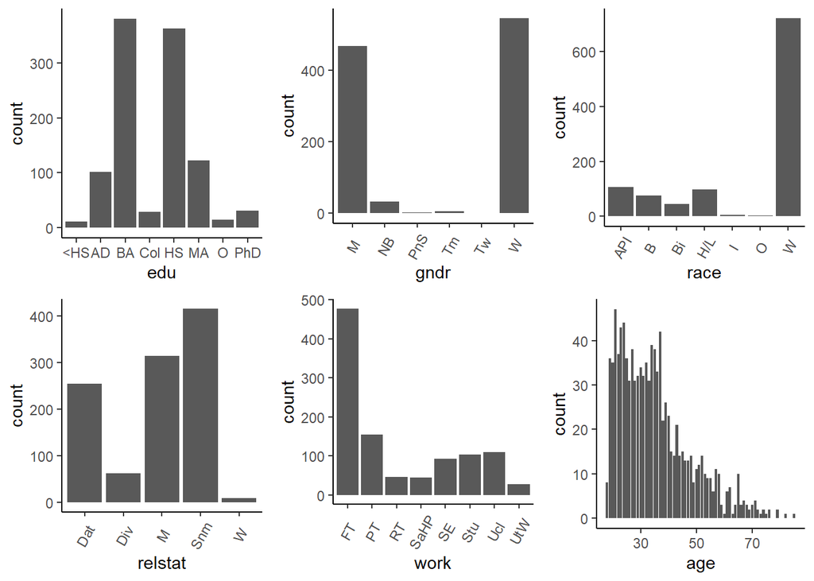

## Frequency statistics

Intent conditions and political orientation (as measured by self-report slider)

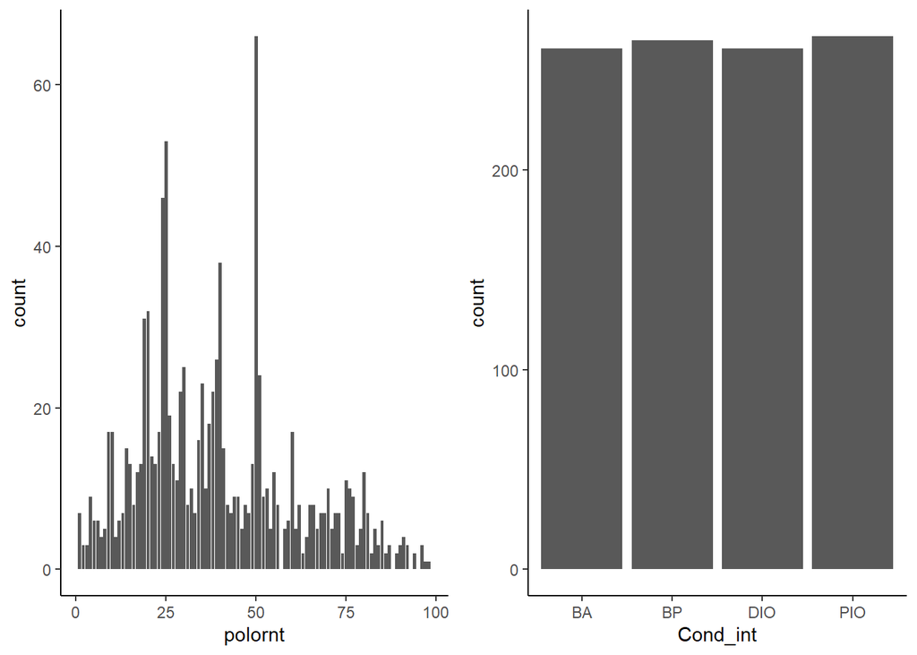

# MJI

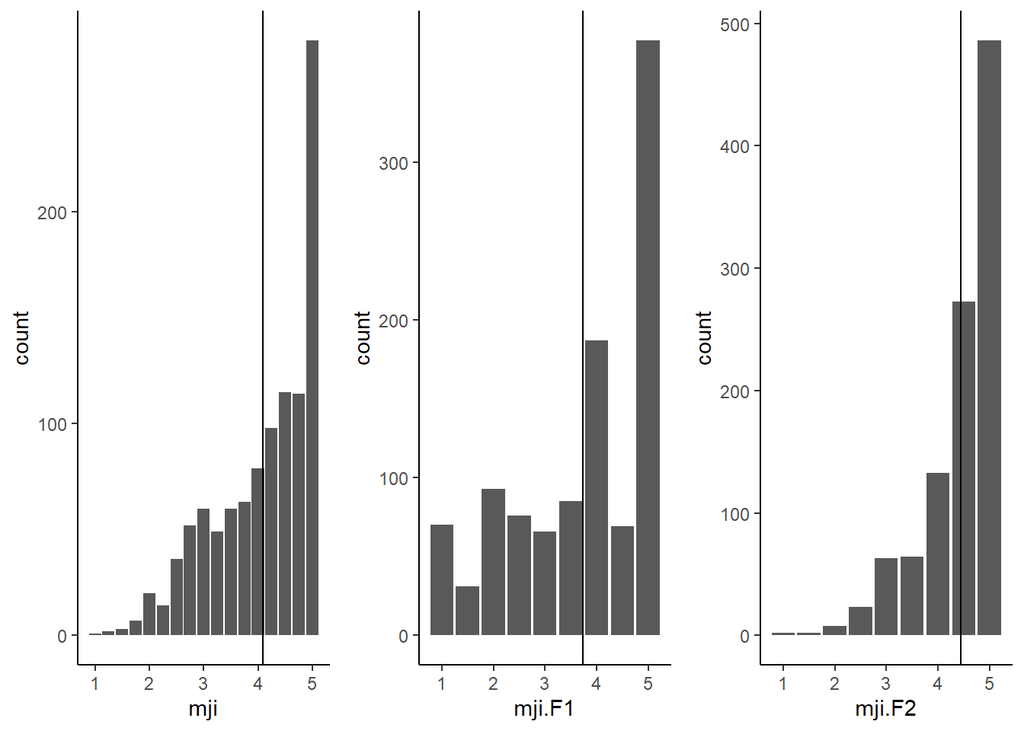

# ABPC

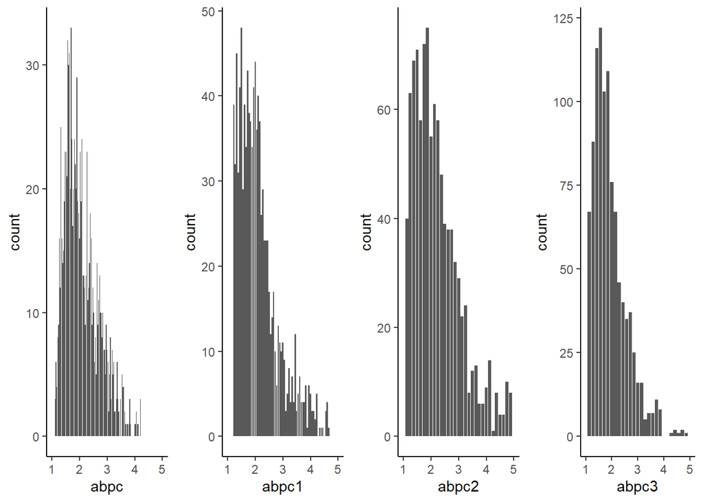

# Skewness & Kurtosis

### Skewness (without transformation)

MJI

```
## [1] -0.8167147
```

MJI F1

```
## [1] -0.7003462
```

MJI F2

```
## [1] -1.51044
```

### Log Transofrmation

MJI

```
## [1] -1.391003
```

MJI F1

```
## [1] -1.342744
```

MJI F2

```
## [1] -2.432083
```

### Square Transformation

MJI

```
## [1] -0.4753509
```

MJI F1

```
## [1] -0.2955464
```

MJI F2

```
## [1] -1.078981
```

### Kurtosis (without transformation)

MJI

```
## [1] -0.2836557
```

MJI F1

```
## [1] -0.758159
```

MJI F2

```
## [1] 2.086023
```

### Log Transofrmation

MJI

```
## [1] 1.982944
```

MJI F1

```
## [1] 0.9138546
```

MJI F2

```
## [1] 8.882306
```

### Square Transformation

MJI

```
## [1] -1.027364
```

MJI F1

```
## [1] -1.362159
```

MJI F2

```
## [1] 0.277238
```

## Internal Consistency

## MJI

Full index

```
##
## Cronbach's alpha for the 'mji.a' data-set
##
## Items: 4
## Sample units: 1054
## alpha: 0.814
```

Factor 1

```
##
## Cronbach's alpha for the 'mjif1.a' data-set
##
## Items: 2
## Sample units: 1054
## alpha: 0.915
```

Factor 2

```
##
## Cronbach's alpha for the 'mjif2.a' data-set
##
## Items: 2
## Sample units: 1054
## alpha: 0.708
```

- Mean MJI item F1.1 = 3.8216319
  - “To what extent were JG’s actions intentional?”
- Mean MJI item F1.2 = 3.6385199
  - “To what extent can one say that JG did what they did on purpose?”
- Mean MJI item F2.1 = 2.4487666
  - “How positively should JG be judged?”
- Mean MJI item F2.2 = 4.2390892
  - “How negatively should JG be judged?”
- Mean MJI item F2.3 = 4.6451613
  - “How much blame should JG receive as a result of their actions?”
- Mean MJI item F2.4 = 2.9392789
  - “Even if no one ever finds out what they did, JG will get what they deserve.”

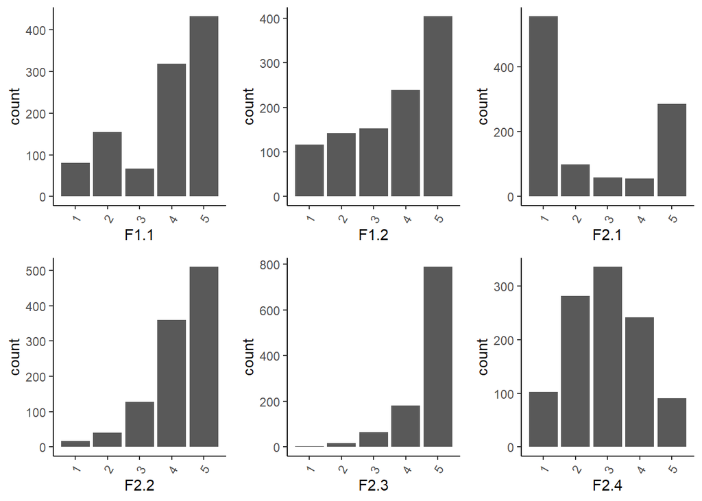

F2.1/F2.4 seem to be the issue. Lets investigate

Visualize Correlation Matrix

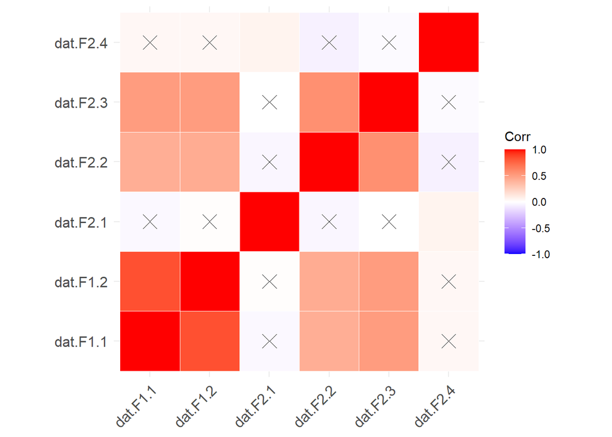

Conclusion: There is very little item intercorrelation for F2.1 and F2.4 with the remainder of the items.

- The items “How positively should JG be judged?” and “Even if no one ever finds out what they did, JG will get what they deserve.” seem to be problematic for our study.
  - My guess is that F2.1 was misinterpreted by some respondents (bimodal distribution), and F2.4 is an assessment of the respondents ‘Just World’ beliefs, not anything to do with the respondents perception of actor moral culpability. For this reason I will remove these items from the analyses.

## ABPC

Full measure

```
##
## Cronbach's alpha for the 'abpc.all' data-set
##
## Items: 33
## Sample units: 1054
## alpha: 0.932
```

Subscale 1: Libertarian Independence

```
##
## Cronbach's alpha for the 'abpc.scale1' data-set
##
## Items: 18
## Sample units: 1054
## alpha: 0.918
```

Subscale 2: Religious Traditionalism

```
##
## Cronbach's alpha for the 'abpc.scale2' data-set
##
## Items: 8
## Sample units: 1054
## alpha: 0.892
```

Subscale 3: Ethnic Separateness

```
##
## Cronbach's alpha for the 'abpc.scale3' data-set
##
## Items: 7
## Sample units: 1054
## alpha: 0.779
```

## Assumption Check: 2-Factor MJI

It is assumed that the MJI is divisible into 2 factors, F1 is composed of items related to the actors intentionality (items F1.1 & F1.2), F2 is composed of more emotional/valence related items (items F2.1, F2.2, F2.3, F2.4).

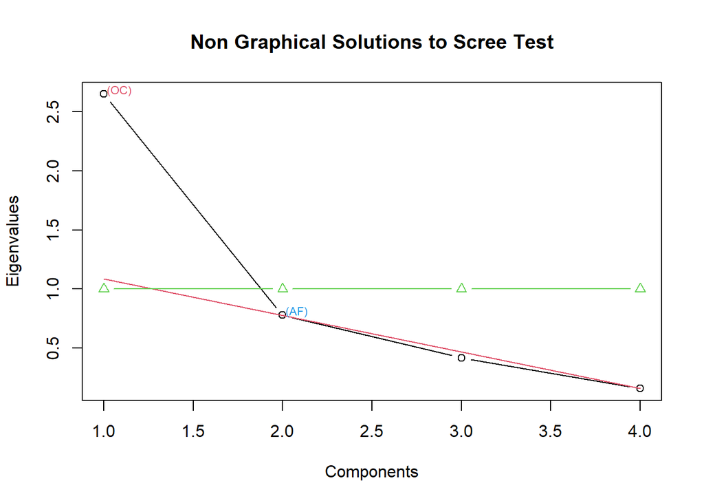

### Eigenvalues

```
## [1] 2.6498432 0.7769962 0.4163317 0.1568289
```

### Factor Loadings

```
##
## Call:
## factanal(x = dat.mji.full, factors = 2, rotation = "promax")
##
## Uniquenesses:
## dat.F1.1 dat.F1.2 dat.F2.1 dat.F2.2 dat.F2.3 dat.F2.4
##     0.14     0.18     1.00     0.14     0.54     0.99
##
## Loadings:
##          Factor1 Factor2
## dat.F1.1  0.97
## dat.F1.2  0.93
## dat.F2.2          0.96
## dat.F2.1
## dat.F2.3  0.31    0.45
## dat.F2.4
##
##                Factor1 Factor2
## SS loadings       1.92    1.16
## Proportion Var    0.32    0.19
## Cumulative Var    0.32    0.51
##
## Factor Correlations:
##         Factor1 Factor2
## Factor1    1.00    0.59
## Factor2    0.59    1.00
##
## Test of the hypothesis that 2 factors are sufficient.
## The chi square statistic is 10.61 on 4 degrees of freedom.
## The p-value is 0.0313
```

## Assumption Check: 3-Factor ABPC

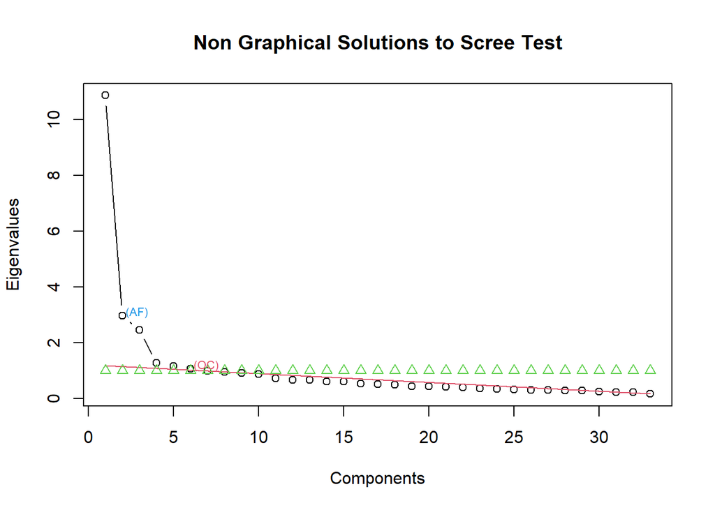

### EigenValues

```
##  [1] 10.8759115  2.9789637  2.4494469  1.2804702  1.1578990  1.0583323
##  [7]  0.9889890  0.9401171  0.9096516  0.8653789  0.7226918  0.6687159
## [13]  0.6533648  0.6124426  0.6017456  0.5277731  0.5066976  0.4921040
## [19]  0.4357609  0.4286918  0.4150813  0.3873606  0.3576915  0.3453052
## [25]  0.3166536  0.3044566  0.2937105  0.2885999  0.2784638  0.2418523
## [31]  0.2288019  0.2239267  0.1629478
```

### Factor Loadings

```
##
## Call:
## factanal(x = dat.abpc, factors = 6, rotation = "promax")
##
## Uniquenesses:
##  dat.abpc.1  dat.abpc.2  dat.abpc.3  dat.abpc.4  dat.abpc.5  dat.abpc.6
##        0.28        0.39        0.18        0.40        0.33        0.92
##  dat.abpc.7  dat.abpc.8  dat.abpc.9 dat.abpc.10 dat.abpc.11 dat.abpc.12
##        0.94        0.35        0.40        0.53        0.62        0.57
## dat.abpc.13 dat.abpc.14 dat.abpc.15 dat.abpc.16 dat.abpc.17 dat.abpc.18
##        0.23        0.50        0.52        0.37        0.37        0.57
## dat.abpc.19 dat.abpc.20 dat.abpc.21 dat.abpc.22 dat.abpc.23 dat.abpc.24
##        0.22        0.17        0.29        0.36        0.47        0.97
## dat.abpc.25 dat.abpc.26 dat.abpc.27 dat.abpc.28 dat.abpc.29 dat.abpc.30
##        0.69        0.73        0.27        0.33        0.58        0.43
## dat.abpc.31 dat.abpc.32 dat.abpc.33
##        0.46        0.64        0.61
##
## Loadings:
##             Factor1 Factor2 Factor3 Factor4 Factor5 Factor6
## dat.abpc.4   0.67
## dat.abpc.5   0.86
## dat.abpc.8   0.87
## dat.abpc.10  0.70
## dat.abpc.14  0.69
## dat.abpc.15  0.55
## dat.abpc.16  0.57            0.35
## dat.abpc.17  0.69            0.31
## dat.abpc.18  0.56
## dat.abpc.19          0.95
## dat.abpc.20          0.97
## dat.abpc.21          0.84
## dat.abpc.22          0.79
## dat.abpc.26          0.52
## dat.abpc.31                  0.70
## dat.abpc.32                  0.61
## dat.abpc.33                  0.70
## dat.abpc.27                          0.87
## dat.abpc.28                          0.81
## dat.abpc.30                          0.71
```

[output cut: 16 more lines]

```
## Proportion Var    0.15    0.11    0.07    0.07    0.05    0.04
## Cumulative Var    0.15    0.27    0.34    0.40    0.45    0.49
##
## Factor Correlations:
##         Factor1 Factor2 Factor3 Factor4 Factor5 Factor6
## Factor1    1.00   -0.41    0.30   -0.63   -0.55   -0.64
## Factor2   -0.41    1.00   -0.22    0.35    0.31    0.52
## Factor3    0.30   -0.22    1.00   -0.15   -0.26   -0.46
## Factor4   -0.63    0.35   -0.15    1.00    0.52    0.53
## Factor5   -0.55    0.31   -0.26    0.52    1.00    0.45
## Factor6   -0.64    0.52   -0.46    0.53    0.45    1.00
##
## Test of the hypothesis that 6 factors are sufficient.
## The chi square statistic is 1132.87 on 345 degrees of freedom.
## The p-value is 1.29e-84
```

# ABPC*polornt correlation

```
##
##  Pearson's product-moment correlation
##
## data:  dat$polornt and dat$abpc
## t = 37.86, df = 1052, p-value < 2.2e-16
## alternative hypothesis: true correlation is not equal to 0
## 95 percent confidence interval:
##  0.7326343 0.7838601
## sample estimates:
##       cor
## 0.7594217
```

# Linear Modeling

## Assumption Check: Intentionality

We designs each of the 4 conditions to be more or less intentional. We assume BA is the least intentional, BP is the most intentional, and PIo and DIo are somewhere in between. The following analysis seeks to determine if that is assumption manifests in the data.

```
##               Df Sum Sq Mean Sq F value Pr(>F)
## Cond_int       3  593.8  197.92   176.5 <2e-16 ***
## Residuals   1050 1177.7    1.12
## ---
## Signif. codes:  0 '***' 0.001 '**' 0.01 '*' 0.05 '.' 0.1 ' ' 1
```

```
##   Tukey multiple comparisons of means
##     95% family-wise confidence level
##
## Fit: aov(formula = mean.mjif1 ~ Cond_int, data = dat)
##
## $Cond_int
##               diff        lwr        upr     p adj
## BP-BA    1.7713583  1.5337080  2.0090087 0.0000000
## DIO-BA  -0.1206897 -0.3592419  0.1178626 0.5619429
## PIO-BA   0.6596065  0.4223982  0.8968148 0.0000000
## DIO-BP  -1.8920480 -2.1296983 -1.6543977 0.0000000
## PIO-BP  -1.1117518 -1.3480531 -0.8754506 0.0000000
## PIO-DIO  0.7802962  0.5430879  1.0175045 0.0000000
```

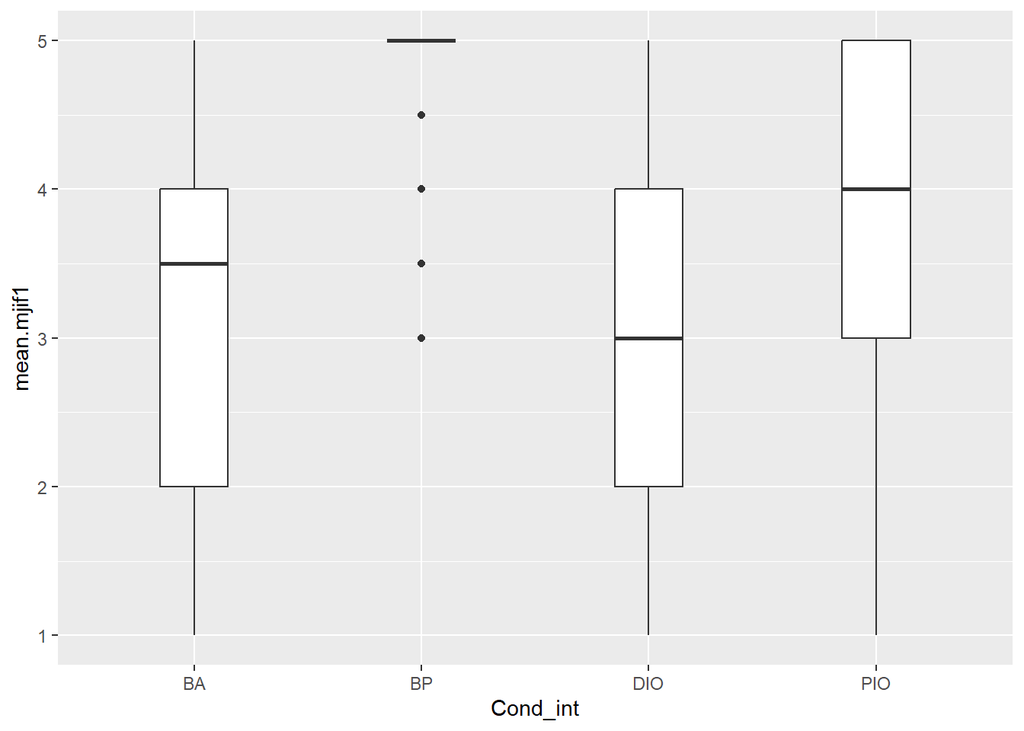

## Moderation Analysis

The goal of this analysis is to determine the moderation effect of the first MJI factor. Most of the observed effects have been in the BA condition, thus we seek to answer the question “do participants who believed the BA condition to still be highly intentional (high mji.f1 in BA condition) show a tweet*political_orientation interaction effect when compared to participants who perceive low intentionality”? We use the MJI intent factor as the moderator and the valence factor as the DV. Tweets and political orientation are inputted as predictor variables.

## Full model

```
##
## Call:
## lm(formula = mc_mjif2 ~ mc_polornt * mc_mjif1 * tweets, data = subset(dat,
##     Cond_int == "BA"))
##
## Residuals:
##     Min      1Q  Median      3Q     Max
## -1.9010 -0.3959  0.1104  0.4215  1.7816
##
## Coefficients:
##                              Estimate Std. Error t value Pr(>|t|)
## (Intercept)                  0.037249   0.074353   0.501   0.6168
## mc_polornt                   0.003922   0.003263   1.202   0.2306
## mc_mjif1                     0.357917   0.050832   7.041 1.79e-11 ***
## tweetsR                     -0.070754   0.094383  -0.750   0.4542
## mc_polornt:mc_mjif1         -0.005406   0.002503  -2.160   0.0317 *
## mc_polornt:tweetsR          -0.009453   0.004323  -2.187   0.0297 *
## mc_mjif1:tweetsR            -0.094068   0.068968  -1.364   0.1738
## mc_polornt:mc_mjif1:tweetsR  0.006224   0.003481   1.788   0.0750 .
## ---
## Signif. codes:  0 '***' 0.001 '**' 0.01 '*' 0.05 '.' 0.1 ' ' 1
##
## Residual standard error: 0.6561 on 253 degrees of freedom
## Multiple R-squared:  0.3009, Adjusted R-squared:  0.2815
## F-statistic: 15.56 on 7 and 253 DF,  p-value: < 2.2e-16
```

### polornt = Left

```
##
## Call:
## lm(formula = mc_mjif2 ~ mc_polornt * mc_mjif1 * tweets, data = subset(dat,
##     Cond_int == "BA" & L.R == "L"))
##
## Residuals:
##     Min      1Q  Median      3Q     Max
## -1.7162 -0.3051  0.1299  0.3874  1.7371
##
## Coefficients:
##                               Estimate Std. Error t value Pr(>|t|)
## (Intercept)                  0.2315198  0.2696673   0.859   0.3924
## mc_polornt                   0.0114464  0.0137343   0.833   0.4063
## mc_mjif1                     0.4401686  0.1918707   2.294   0.0236 *
## tweetsR                     -0.0070908  0.3535607  -0.020   0.9840
## mc_polornt:mc_mjif1         -0.0008468  0.0103696  -0.082   0.9351
## mc_polornt:tweetsR          -0.0024944  0.0183918  -0.136   0.8924
## mc_mjif1:tweetsR            -0.1934945  0.2811655  -0.688   0.4927
## mc_polornt:mc_mjif1:tweetsR  0.0008480  0.0159042   0.053   0.9576
## ---
## Signif. codes:  0 '***' 0.001 '**' 0.01 '*' 0.05 '.' 0.1 ' ' 1
##
## Residual standard error: 0.6958 on 117 degrees of freedom
## Multiple R-squared:  0.3031, Adjusted R-squared:  0.2614
## F-statistic: 7.269 on 7 and 117 DF,  p-value: 3.162e-07
```

### polornt = Right

```
##
## Call:
## lm(formula = mc_mjif2 ~ mc_polornt * mc_mjif1 * tweets, data = subset(dat,
##     Cond_int == "BA" & L.R == "R"))
##
## Residuals:
##     Min      1Q  Median      3Q     Max
## -1.7766 -0.3184  0.1154  0.3995  1.1554
##
## Coefficients:
##                              Estimate Std. Error t value Pr(>|t|)
## (Intercept)                 -0.100719   0.134228  -0.750   0.4544
## mc_polornt                   0.009052   0.005477   1.653   0.1009
## mc_mjif1                     0.381739   0.086338   4.421 2.07e-05 ***
## tweetsR                      0.072460   0.168447   0.430   0.6678
## mc_polornt:mc_mjif1         -0.007311   0.004031  -1.814   0.0720 .
## mc_polornt:tweetsR          -0.016111   0.007096  -2.270   0.0249 *
## mc_mjif1:tweetsR            -0.095160   0.117270  -0.811   0.4186
## mc_polornt:mc_mjif1:tweetsR  0.007162   0.005502   1.302   0.1954
## ---
## Signif. codes:  0 '***' 0.001 '**' 0.01 '*' 0.05 '.' 0.1 ' ' 1
##
## Residual standard error: 0.6241 on 128 degrees of freedom
## Multiple R-squared:  0.3308, Adjusted R-squared:  0.2942
## F-statistic: 9.037 on 7 and 128 DF,  p-value: 4.936e-09
```

A simple slopes graph for mc_polornt*mc_mjif1

Traditional simple slopes is impossible for MJI.F1 as its mean+1SD exceeds the maximum value of the MJI scale. Additionally, traditional simple slopes does not permit the use of dichotomous variables.

Instead, we can use MJI.F1 >= 4 compared to MJI.F1 < 4.

### mjif1 >= 4

```
##
## Call:
## lm(formula = mc_mjif2 ~ mc_polornt * tweets, data = subset(dat,
##     Cond_int == "BA" & mean.mjif1 >= 4))
##
## Residuals:
##     Min      1Q  Median      3Q     Max
## -1.7365 -0.2562  0.2138  0.2864  0.9732
##
## Coefficients:
##                     Estimate Std. Error t value Pr(>|t|)
## (Intercept)         0.301116   0.088906   3.387  0.00102 **
## mc_polornt          0.001201   0.003683   0.326  0.74506
## tweetsR            -0.192162   0.108244  -1.775  0.07899 .
## mc_polornt:tweetsR -0.012646   0.004835  -2.616  0.01033 *
## ---
## Signif. codes:  0 '***' 0.001 '**' 0.01 '*' 0.05 '.' 0.1 ' ' 1
##
## Residual standard error: 0.5041 on 97 degrees of freedom
## Multiple R-squared:  0.1448, Adjusted R-squared:  0.1184
## F-statistic: 5.476 on 3 and 97 DF,  p-value: 0.001612
```

### mjif1 < 4

```
##
## Call:
## lm(formula = mc_mjif2 ~ mc_polornt * tweets, data = subset(dat,
##     Cond_int == "BA" & mean.mjif1 < 4))
##
## Residuals:
##      Min       1Q   Median       3Q      Max
## -2.21478 -0.55322  0.05139  0.51474  1.51905
##
## Coefficients:
##                     Estimate Std. Error t value Pr(>|t|)
## (Intercept)        -0.491097   0.084409  -5.818 3.27e-08 ***
## mc_polornt          0.012307   0.004300   2.862  0.00479 **
## tweetsR             0.122582   0.125215   0.979  0.32911
## mc_polornt:tweetsR -0.014691   0.005866  -2.504  0.01330 *
## ---
## Signif. codes:  0 '***' 0.001 '**' 0.01 '*' 0.05 '.' 0.1 ' ' 1
##
## Residual standard error: 0.7868 on 156 degrees of freedom
## Multiple R-squared:  0.05777,    Adjusted R-squared:  0.03965
## F-statistic: 3.188 on 3 and 156 DF,  p-value: 0.02541
```

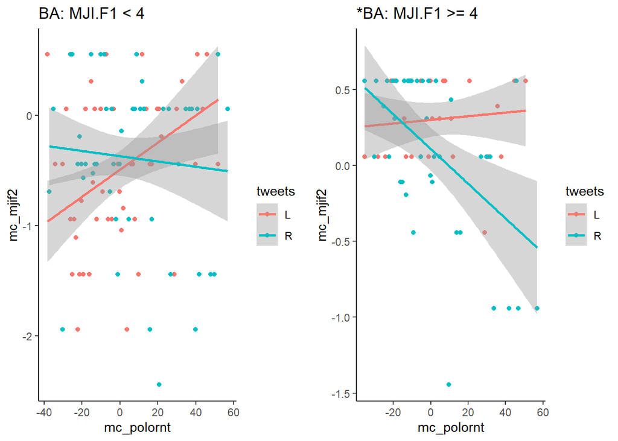

## 4-ITEM MJI - sqr transformed - Full model using ABPC as a measure of political orientation

Full cases =1054

```
##
## Call:
## lm(formula = sqr.mji ~ PI + DI + tweets + abpc + PI * DI + PI *
##     tweets + PI * abpc + DI * tweets + DI * abpc + tweets * abpc +
##     PI * DI * tweets + PI * DI * abpc + PI * tweets * abpc +
##     DI * tweets * abpc, data = dat)
##
## Residuals:
##      Min       1Q   Median       3Q      Max
## -15.3366  -3.7032   0.9779   3.4742  13.0871
##
## Coefficients:
##                  Estimate Std. Error t value Pr(>|t|)
## (Intercept)        6.8368     1.7368   3.936 8.82e-05 ***
## PI1                7.8319     2.1545   3.635 0.000291 ***
## DI1                3.7350     2.1683   1.723 0.085275 .
## tweetsR           12.4019     2.1412   5.792 9.20e-09 ***
## abpc               3.0456     0.7866   3.872 0.000115 ***
## PI1:DI1            3.8014     2.4673   1.541 0.123694
## PI1:tweetsR       -5.1923     2.4981  -2.079 0.037907 *
## PI1:abpc          -1.7787     0.9737  -1.827 0.068044 .
## DI1:tweetsR       -6.8032     2.4801  -2.743 0.006191 **
## DI1:abpc          -1.1867     0.9763  -1.215 0.224456
## tweetsR:abpc      -4.8474     0.9627  -5.035 5.63e-07 ***
## PI1:DI1:tweetsR    2.2148     1.3514   1.639 0.101540
## PI1:DI1:abpc       0.5024     1.0966   0.458 0.646982
## PI1:tweetsR:abpc   1.8334     1.0968   1.672 0.094901 .
## DI1:tweetsR:abpc   1.8773     1.0956   1.713 0.086931 .
## ---
## Signif. codes:  0 '***' 0.001 '**' 0.01 '*' 0.05 '.' 0.1 ' ' 1
##
## Residual standard error: 5.465 on 1039 degrees of freedom
## Multiple R-squared:  0.3445, Adjusted R-squared:  0.3357
## F-statistic: 39.01 on 14 and 1039 DF,  p-value: < 2.2e-16
```

#### Residual Density and Q-Q plots

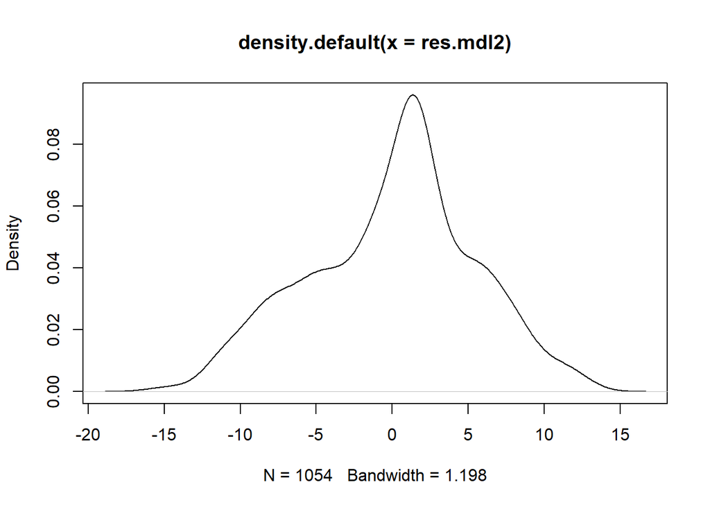

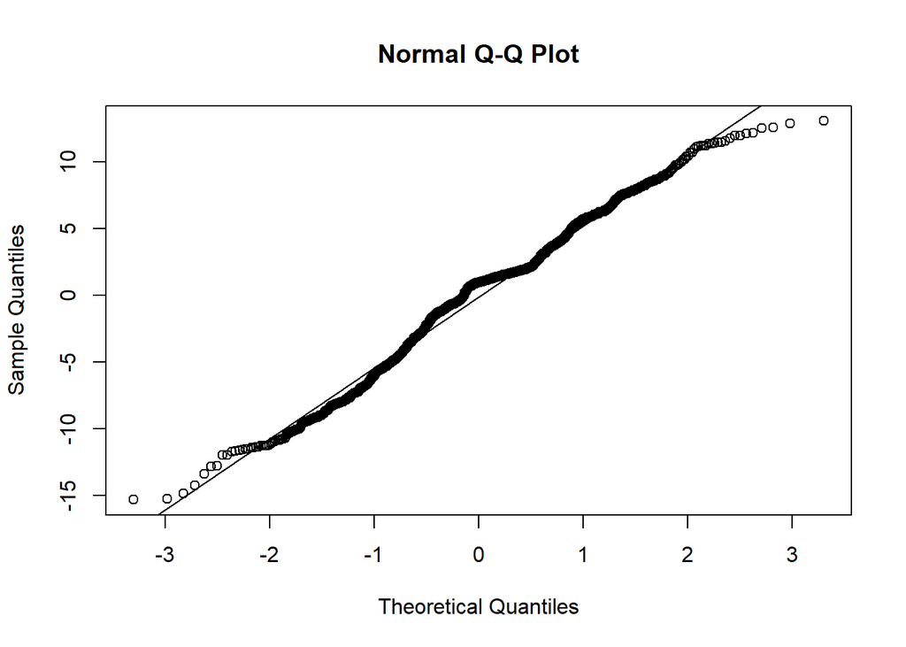

#### ANOVA and Tukey’s on model residuals

```
##               Df Sum Sq Mean Sq F value Pr(>F)
## Cond_int       3   2118   706.0   81.36 <2e-16 ***
## Residuals   1050   9112     8.7
## ---
## Signif. codes:  0 '***' 0.001 '**' 0.01 '*' 0.05 '.' 0.1 ' ' 1
```

```
##   Tukey multiple comparisons of means
##     95% family-wise confidence level
##
## Fit: aov(formula = resids.abs.mdl2 ~ Cond_int, data = dat)
##
## $Cond_int
##                diff        lwr        upr     p adj
## BP-BA   -3.10347495 -3.7645014 -2.4424485 0.0000000
## DIO-BA   0.21250383 -0.4510312  0.8760389 0.8430807
## PIO-BA   0.25474889 -0.4050479  0.9145457 0.7531731
## DIO-BP   3.31597879  2.6549524  3.9770052 0.0000000
## PIO-BP   3.35822384  2.7009499  4.0154977 0.0000000
## PIO-DIO  0.04224505 -0.6175518  0.7020419 0.9984090
```

### Regression Coefficients

```
##
## Call:
## lm(formula = sqr.mji ~ PI + DI + tweets + abpc + PI * DI + PI *
##     tweets + PI * abpc + DI * tweets + DI * abpc + tweets * abpc +
##     PI * DI * tweets + PI * DI * abpc + PI * tweets * abpc +
##     DI * tweets * abpc, data = dat)
##
## Standardized Coefficients::
##      (Intercept)              PI1              DI1          tweetsR
##               NA       0.58430040       0.27865806       0.92526638
##             abpc          PI1:DI1      PI1:tweetsR         PI1:abpc
##       0.28119445       0.24608590      -0.33612196      -0.30041067
##      DI1:tweetsR         DI1:abpc     tweetsR:abpc  PI1:DI1:tweetsR
##      -0.43590100      -0.19823558      -0.82374074       0.10938772
##     PI1:DI1:abpc PI1:tweetsR:abpc DI1:tweetsR:abpc
##       0.07096728       0.26676479       0.26425213
```

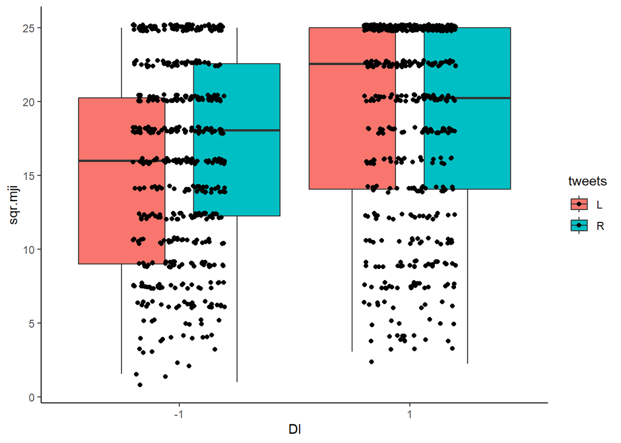

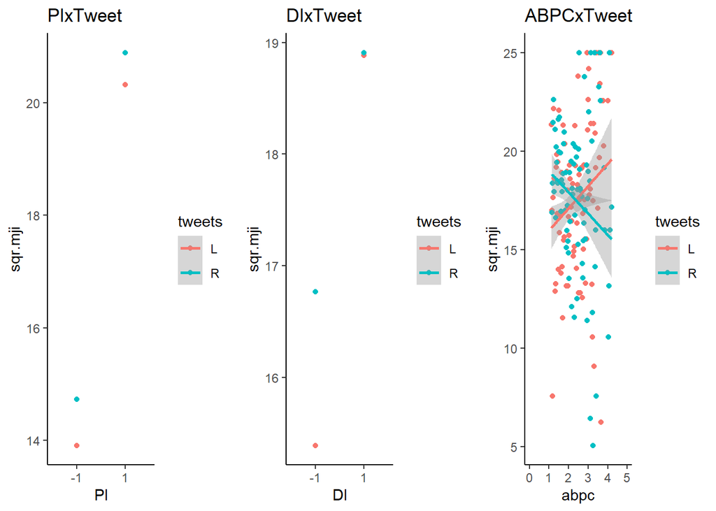

# Simple effects (split by intent conditions and ABPC)

- BA cases =261
- PIO cases =267
- DIO cases =261
- BP cases =265

### BA

```
##
## Call:
## lm(formula = sqr.mji ~ tweets + abpc + tweets * abpc, data = subset(dat,
##     Cond_int == "BA"))
##
## Residuals:
##      Min       1Q   Median       3Q      Max
## -11.8807  -4.7822   0.1648   4.2608  13.0013
##
## Coefficients:
##              Estimate Std. Error t value Pr(>|t|)
## (Intercept)    7.2414     2.0504   3.532 0.000489 ***
## tweetsR       12.0166     2.6935   4.461 1.22e-05 ***
## abpc           2.8544     0.9345   3.055 0.002490 **
## tweetsR:abpc  -4.7036     1.2288  -3.828 0.000162 ***
## ---
## Signif. codes:  0 '***' 0.001 '**' 0.01 '*' 0.05 '.' 0.1 ' ' 1
##
## Residual standard error: 5.98 on 257 degrees of freedom
## Multiple R-squared:  0.08125,    Adjusted R-squared:  0.07053
## F-statistic: 7.576 on 3 and 257 DF,  p-value: 7.106e-05
```

### Regression Coefficients

```
##
## Call:
## lm(formula = sqr.mji ~ tweets + abpc + tweets * abpc, data = subset(dat,
##     Cond_int == "BA"))
##
## Standardized Coefficients::
##  (Intercept)      tweetsR         abpc tweetsR:abpc
##           NA    0.9680082    0.2812800   -0.8686002
```

### PIO

```
##
## Call:
## lm(formula = sqr.mji ~ tweets + abpc + tweets * abpc, data = subset(dat,
##     Cond_int == "PIO"))
##
## Residuals:
##      Min       1Q   Median       3Q      Max
## -15.3707  -4.5983   0.9997   5.5934  10.0377
##
## Coefficients:
##              Estimate Std. Error t value Pr(>|t|)
## (Intercept)    14.359      1.883   7.627 4.41e-13 ***
## tweetsR         7.829      2.679   2.923  0.00377 **
## abpc            1.416      0.869   1.630  0.10437
## tweetsR:abpc   -3.309      1.221  -2.710  0.00718 **
## ---
## Signif. codes:  0 '***' 0.001 '**' 0.01 '*' 0.05 '.' 0.1 ' ' 1
##
## Residual standard error: 6.294 on 263 degrees of freedom
## Multiple R-squared:  0.03231,    Adjusted R-squared:  0.02127
## F-statistic: 2.927 on 3 and 263 DF,  p-value: 0.03426
```

### Regression Coefficients

```
##
## Call:
## lm(formula = sqr.mji ~ tweets + abpc + tweets * abpc, data = subset(dat,
##     Cond_int == "PIO"))
##
## Standardized Coefficients::
##  (Intercept)      tweetsR         abpc tweetsR:abpc
##           NA    0.6163667    0.1408479   -0.6016979
```

### DIO

```
##
## Call:
## lm(formula = sqr.mji ~ tweets + abpc + tweets * abpc, data = subset(dat,
##     Cond_int == "DIO"))
##
## Residuals:
##      Min       1Q   Median       3Q      Max
## -13.5891  -5.0670  -0.0707   4.9455  12.0070
##
## Coefficients:
##              Estimate Std. Error t value Pr(>|t|)
## (Intercept)   10.2528     1.8656   5.496 9.36e-08 ***
## tweetsR        5.8218     2.7036   2.153   0.0322 *
## abpc           2.0110     0.8533   2.357   0.0192 *
## tweetsR:abpc  -3.0280     1.2539  -2.415   0.0164 *
## ---
## Signif. codes:  0 '***' 0.001 '**' 0.01 '*' 0.05 '.' 0.1 ' ' 1
##
## Residual standard error: 6.123 on 257 degrees of freedom
## Multiple R-squared:  0.02715,    Adjusted R-squared:  0.0158
## F-statistic: 2.391 on 3 and 257 DF,  p-value: 0.06914
```

### Regression Coefficients

```
##
## Call:
## lm(formula = sqr.mji ~ tweets + abpc + tweets * abpc, data = subset(dat,
##     Cond_int == "DIO"))
##
## Standardized Coefficients::
##  (Intercept)      tweetsR         abpc tweetsR:abpc
##           NA    0.4722913    0.1980679   -0.5418230
```

### BP

```
##
## Call:
## lm(formula = sqr.mji ~ tweets + abpc + tweets * abpc, data = subset(dat,
##     Cond_int == "BP"))
##
## Residuals:
##      Min       1Q   Median       3Q      Max
## -11.5945  -0.8091   1.1797   1.5799   2.1376
##
## Coefficients:
##              Estimate Std. Error t value Pr(>|t|)
## (Intercept)   22.5088     0.7645  29.443   <2e-16 ***
## tweetsR        1.9905     1.1173   1.782    0.076 .
## abpc           0.4303     0.3661   1.175    0.241
## tweetsR:abpc  -0.8304     0.5191  -1.600    0.111
## ---
## Signif. codes:  0 '***' 0.001 '**' 0.01 '*' 0.05 '.' 0.1 ' ' 1
##
## Residual standard error: 2.625 on 261 degrees of freedom
## Multiple R-squared:  0.0126, Adjusted R-squared:  0.001247
## F-statistic:  1.11 on 3 and 261 DF,  p-value: 0.3456
```

### Regression Coefficients

```
##
## Call:
## lm(formula = sqr.mji ~ tweets + abpc + tweets * abpc, data = subset(dat,
##     Cond_int == "BP"))
##
## Standardized Coefficients::
##  (Intercept)      tweetsR         abpc tweetsR:abpc
##           NA    0.3796801    0.1025592   -0.3642269
```

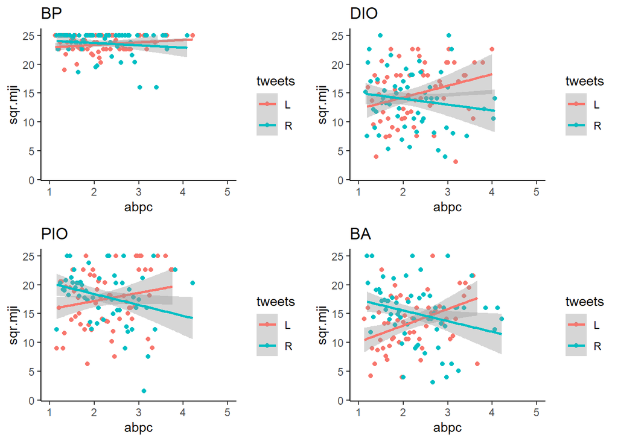

## Left of midpoint (ABPC < 2)

- Full cases =516
- BA cases =131
- PIO cases =130
- DIO cases =124
- BP cases =131

### Full model

```
##
## Call:
## lm(formula = sqr.mji ~ PI * DI * tweets, data = subset(dat, abpc <
##     med.abpc))
##
## Residuals:
##      Min       1Q   Median       3Q      Max
## -13.3625  -3.8922   0.8772   3.3775  12.9671
##
## Coefficients:
##                 Estimate Std. Error t value Pr(>|t|)
## (Intercept)      12.0329     0.7166  16.793  < 2e-16 ***
## PI1               4.7661     0.9817   4.855 1.60e-06 ***
## DI1               1.6652     0.9817   1.696 0.090454 .
## tweetsR           4.8396     0.9534   5.076 5.41e-07 ***
## PI1:DI1           4.8645     1.3472   3.611 0.000335 ***
## PI1:tweetsR      -2.0261     1.3452  -1.506 0.132635
## DI1:tweetsR      -4.0249     1.3621  -2.955 0.003272 **
## PI1:DI1:tweetsR   2.0056     1.9135   1.048 0.295077
## ---
## Signif. codes:  0 '***' 0.001 '**' 0.01 '*' 0.05 '.' 0.1 ' ' 1
##
## Residual standard error: 5.41 on 508 degrees of freedom
## Multiple R-squared:  0.3642, Adjusted R-squared:  0.3555
## F-statistic: 41.57 on 7 and 508 DF,  p-value: < 2.2e-16
```

### Regression Coefficients

```
##
## Call:
## lm(formula = sqr.mji ~ PI * DI * tweets, data = subset(dat, abpc <
##     med.abpc))
##
## Standardized Coefficients::
##     (Intercept)             PI1             DI1         tweetsR         PI1:DI1
##              NA      0.35396907      0.12366874      0.35943585      0.31449678
##     PI1:tweetsR     DI1:tweetsR PI1:DI1:tweetsR
##     -0.12823887     -0.25034922      0.09409979
```

### BA

```
##
## Call:
## lm(formula = sqr.mji ~ tweets, data = subset(dat, Cond_int ==
##     "BA" & abpc < med.abpc))
##
## Residuals:
##      Min       1Q   Median       3Q      Max
## -10.6225  -4.6225   0.2171   3.9671  12.9671
##
## Coefficients:
##             Estimate Std. Error t value Pr(>|t|)
## (Intercept)   12.033      0.809  14.873  < 2e-16 ***
## tweetsR        4.840      1.076   4.496 1.53e-05 ***
## ---
## Signif. codes:  0 '***' 0.001 '**' 0.01 '*' 0.05 '.' 0.1 ' ' 1
##
## Residual standard error: 6.108 on 129 degrees of freedom
## Multiple R-squared:  0.1355, Adjusted R-squared:  0.1288
## F-statistic: 20.21 on 1 and 129 DF,  p-value: 1.525e-05
```

### Regression Coefficients

```
##
## Call:
## lm(formula = sqr.mji ~ tweets, data = subset(dat, Cond_int ==
##     "BA" & abpc < med.abpc))
##
## Standardized Coefficients::
## (Intercept)     tweetsR
##          NA   0.3680538
```

### PIO

```
##
## Call:
## lm(formula = sqr.mji ~ tweets, data = subset(dat, Cond_int ==
##     "PIO" & abpc < med.abpc))
##
## Residuals:
##      Min       1Q   Median       3Q      Max
## -13.3625  -4.5490   0.6375   5.3875   8.2010
##
## Coefficients:
##             Estimate Std. Error t value Pr(>|t|)
## (Intercept)  16.7990     0.7603  22.095  < 2e-16 ***
## tweetsR       2.8135     1.0752   2.617  0.00995 **
## ---
## Signif. codes:  0 '***' 0.001 '**' 0.01 '*' 0.05 '.' 0.1 ' ' 1
##
## Residual standard error: 6.13 on 128 degrees of freedom
## Multiple R-squared:  0.05077,    Adjusted R-squared:  0.04336
## F-statistic: 6.846 on 1 and 128 DF,  p-value: 0.009951
```

### Regression Coefficients

```
##
## Call:
## lm(formula = sqr.mji ~ tweets, data = subset(dat, Cond_int ==
##     "PIO" & abpc < med.abpc))
##
## Standardized Coefficients::
## (Intercept)     tweetsR
##          NA   0.2253268
```

### DIO

```
##
## Call:
## lm(formula = sqr.mji ~ tweets, data = subset(dat, Cond_int ==
##     "DIO" & abpc < med.abpc))
##
## Residuals:
##      Min       1Q   Median       3Q      Max
## -11.4502  -4.6981  -0.4502   4.7076  11.3019
##
## Coefficients:
##             Estimate Std. Error t value Pr(>|t|)
## (Intercept)  13.6981     0.7536  18.176   <2e-16 ***
## tweetsR       0.8146     1.0925   0.746    0.457
## ---
## Signif. codes:  0 '***' 0.001 '**' 0.01 '*' 0.05 '.' 0.1 ' ' 1
##
## Residual standard error: 6.076 on 122 degrees of freedom
## Multiple R-squared:  0.004536,   Adjusted R-squared:  -0.003623
## F-statistic: 0.556 on 1 and 122 DF,  p-value: 0.4573
```

### Regression Coefficients

```
##
## Call:
## lm(formula = sqr.mji ~ tweets, data = subset(dat, Cond_int ==
##     "DIO" & abpc < med.abpc))
##
## Standardized Coefficients::
## (Intercept)     tweetsR
##          NA  0.06735334
```

### BP

```
##
## Call:
## lm(formula = sqr.mji ~ tweets, data = subset(dat, Cond_int ==
##     "BP" & abpc < med.abpc))
##
## Residuals:
##      Min       1Q   Median       3Q      Max
## -11.8728  -0.7663   0.8772   1.6712   1.6712
##
## Coefficients:
##             Estimate Std. Error t value Pr(>|t|)
## (Intercept)  23.3288     0.2806  83.144   <2e-16 ***
## tweetsR       0.7941     0.4217   1.883   0.0619 .
## ---
## Signif. codes:  0 '***' 0.001 '**' 0.01 '*' 0.05 '.' 0.1 ' ' 1
##
## Residual standard error: 2.397 on 129 degrees of freedom
## Multiple R-squared:  0.02675,    Adjusted R-squared:  0.01921
## F-statistic: 3.546 on 1 and 129 DF,  p-value: 0.06193
```

### Regression Coefficients

```
##
## Call:
## lm(formula = sqr.mji ~ tweets, data = subset(dat, Cond_int ==
##     "BP" & abpc < med.abpc))
##
## Standardized Coefficients::
## (Intercept)     tweetsR
##          NA   0.1635676
```

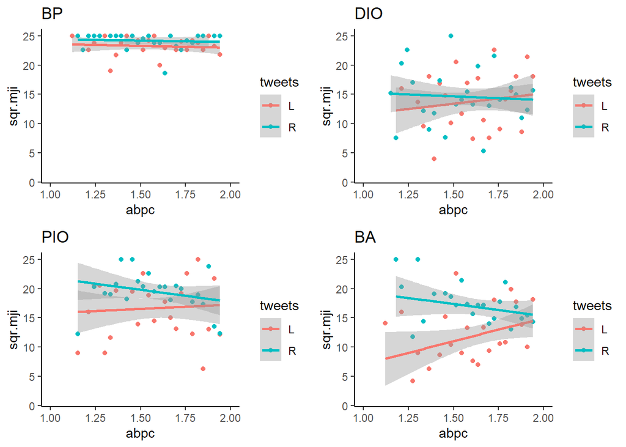

## RIGHT of midpoint (ABPC > 2)

- Full cases =538
- BA cases =130
- PIO cases =137
- DIO cases =137
- BP cases =134

### Full model

```
##
## Call:
## lm(formula = sqr.mji ~ PI * DI * tweets, data = subset(dat, abpc >=
##     med.abpc))
##
## Residuals:
##     Min      1Q  Median      3Q     Max
## -15.773  -3.798   1.438   3.477  11.635
##
## Coefficients:
##                 Estimate Std. Error t value Pr(>|t|)
## (Intercept)      14.3916     0.6936  20.749  < 2e-16 ***
## PI1               3.3738     0.9630   3.504 0.000498 ***
## DI1               0.7959     0.9596   0.829 0.407270
## tweetsR          -0.5091     0.9699  -0.525 0.599827
## PI1:DI1           4.8512     1.3712   3.538 0.000439 ***
## PI1:tweetsR      -0.4833     1.3563  -0.356 0.721744
## DI1:tweetsR      -1.3138     1.3590  -0.967 0.334133
## PI1:DI1:tweetsR   2.1707     1.9171   1.132 0.258015
## ---
## Signif. codes:  0 '***' 0.001 '**' 0.01 '*' 0.05 '.' 0.1 ' ' 1
##
## Residual standard error: 5.549 on 530 degrees of freedom
## Multiple R-squared:  0.3171, Adjusted R-squared:  0.3081
## F-statistic: 35.16 on 7 and 530 DF,  p-value: < 2.2e-16
```

### Regression Coefficients

```
##
## Call:
## lm(formula = sqr.mji ~ PI * DI * tweets, data = subset(dat, abpc >=
##     med.abpc))
##
## Standardized Coefficients::
##     (Intercept)             PI1             DI1         tweetsR         PI1:DI1
##              NA      0.25311156      0.05971173     -0.03818856      0.31480765
##     PI1:tweetsR     DI1:tweetsR PI1:DI1:tweetsR
##     -0.03196281     -0.08649285      0.11218441
```

### BA

```
##
## Call:
## lm(formula = sqr.mji ~ tweets, data = subset(dat, Cond_int ==
##     "BA" & abpc >= med.abpc))
##
## Residuals:
##      Min       1Q   Median       3Q      Max
## -11.3291  -3.8291   0.3485   3.6709  11.2860
##
## Coefficients:
##             Estimate Std. Error t value Pr(>|t|)
## (Intercept)  14.3916     0.7317   19.67   <2e-16 ***
## tweetsR      -0.6776     1.0269   -0.66    0.511
## ---
## Signif. codes:  0 '***' 0.001 '**' 0.01 '*' 0.05 '.' 0.1 ' ' 1
##
## Residual standard error: 5.854 on 128 degrees of freedom
## Multiple R-squared:  0.00339,    Adjusted R-squared:  -0.004396
## F-statistic: 0.4353 on 1 and 128 DF,  p-value: 0.5106
```

### Regression Coefficients

```
##
## Call:
## lm(formula = sqr.mji ~ tweets, data = subset(dat, Cond_int ==
##     "BA" & abpc >= med.abpc))
##
## Standardized Coefficients::
## (Intercept)     tweetsR
##          NA -0.05822055
```

### PIO

```
##
## Call:
## lm(formula = sqr.mji ~ tweets, data = subset(dat, Cond_int ==
##     "PIO" & abpc >= med.abpc))
##
## Residuals:
##      Min       1Q   Median       3Q      Max
## -15.7730  -4.5230   0.2971   5.7895   8.2270
##
## Coefficients:
##             Estimate Std. Error t value Pr(>|t|)
## (Intercept)  17.7654     0.7760  22.893   <2e-16 ***
## tweetsR      -0.9924     1.1015  -0.901    0.369
## ---
## Signif. codes:  0 '***' 0.001 '**' 0.01 '*' 0.05 '.' 0.1 ' ' 1
##
## Residual standard error: 6.446 on 135 degrees of freedom
## Multiple R-squared:  0.005977,   Adjusted R-squared:  -0.001386
## F-statistic: 0.8118 on 1 and 135 DF,  p-value: 0.3692
```

### Regression Coefficients

```
##
## Call:
## lm(formula = sqr.mji ~ tweets, data = subset(dat, Cond_int ==
##     "PIO" & abpc >= med.abpc))
##
## Standardized Coefficients::
## (Intercept)     tweetsR
##          NA -0.07731371
```

### DIO

```
##
## Call:
## lm(formula = sqr.mji ~ tweets, data = subset(dat, Cond_int ==
##     "DIO" & abpc >= med.abpc))
##
## Residuals:
##      Min       1Q   Median       3Q      Max
## -12.1250  -5.9757   0.5243   5.0625  11.4618
##
## Coefficients:
##             Estimate Std. Error t value Pr(>|t|)
## (Intercept)  15.1875     0.7475  20.319   <2e-16 ***
## tweetsR      -1.6493     1.0689  -1.543    0.125
## ---
## Signif. codes:  0 '***' 0.001 '**' 0.01 '*' 0.05 '.' 0.1 ' ' 1
##
## Residual standard error: 6.254 on 135 degrees of freedom
## Multiple R-squared:  0.01733,    Adjusted R-squared:  0.01005
## F-statistic: 2.381 on 1 and 135 DF,  p-value: 0.1252
```

### Regression Coefficients

```
##
## Call:
## lm(formula = sqr.mji ~ tweets, data = subset(dat, Cond_int ==
##     "DIO" & abpc >= med.abpc))
##
## Standardized Coefficients::
## (Intercept)     tweetsR
##          NA  -0.1316459
```

### BP

```
##
## Call:
## lm(formula = sqr.mji ~ tweets, data = subset(dat, Cond_int ==
##     "BP" & abpc >= med.abpc))
##
## Residuals:
##     Min      1Q  Median      3Q     Max
## -11.027  -0.850   1.587   1.723   1.723
##
## Coefficients:
##             Estimate Std. Error t value Pr(>|t|)
## (Intercept)  23.4125     0.3642  64.278   <2e-16 ***
## tweetsR      -0.1355     0.4901  -0.276    0.783
## ---
## Signif. codes:  0 '***' 0.001 '**' 0.01 '*' 0.05 '.' 0.1 ' ' 1
##
## Residual standard error: 2.821 on 132 degrees of freedom
## Multiple R-squared:  0.0005784,  Adjusted R-squared:  -0.006993
## F-statistic: 0.07639 on 1 and 132 DF,  p-value: 0.7827
```

### Regression Coefficients

```
##
## Call:
## lm(formula = sqr.mji ~ tweets, data = subset(dat, Cond_int ==
##     "BP" & abpc >= med.abpc))
##
## Standardized Coefficients::
## (Intercept)     tweetsR
##          NA -0.02405023
```

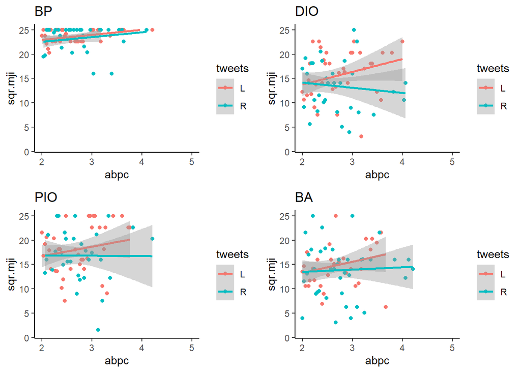

## Left of midpoint (ABPC < 2) w/ ABPC factor 1 (LI)

- Full cases =490
- BA cases =112
- PIO cases =129
- DIO cases =123
- BP cases =126

### Full model

```
##
## Call:
## lm(formula = sqr.mji ~ abpc * PI * DI * tweets, data = subset(dat,
##     abpc.mi < med.abpc.mi))
##
## Residuals:
##      Min       1Q   Median       3Q      Max
## -12.7270  -3.6547   0.6074   3.6292  12.6516
##
## Coefficients:
##                      Estimate Std. Error t value Pr(>|t|)
## (Intercept)            -1.144      5.503  -0.208 0.835351
## abpc                    8.096      3.327   2.433 0.015331 *
## PI1                    15.876      6.666   2.382 0.017633 *
## DI1                    12.093      7.132   1.696 0.090622 .
## tweetsR                28.331      7.560   3.747 0.000201 ***
## abpc:PI1               -7.017      4.048  -1.733 0.083693 .
## abpc:DI1               -6.443      4.330  -1.488 0.137467
## PI1:DI1                -3.089      9.124  -0.339 0.735067
## abpc:tweetsR          -14.788      4.586  -3.224 0.001349 **
## PI1:tweetsR            -9.546      9.342  -1.022 0.307368
## DI1:tweetsR           -28.803      9.823  -2.932 0.003527 **
## abpc:PI1:DI1            5.073      5.604   0.905 0.365830
## abpc:PI1:tweetsR        4.656      5.674   0.821 0.412266
## abpc:DI1:tweetsR       16.097      5.992   2.686 0.007478 **
## PI1:DI1:tweetsR        10.472     12.860   0.814 0.415883
## abpc:PI1:DI1:tweetsR   -5.546      7.890  -0.703 0.482459
## ---
## Signif. codes:  0 '***' 0.001 '**' 0.01 '*' 0.05 '.' 0.1 ' ' 1
##
## Residual standard error: 5.371 on 474 degrees of freedom
## Multiple R-squared:  0.3879, Adjusted R-squared:  0.3686
## F-statistic: 20.03 on 15 and 474 DF,  p-value: < 2.2e-16
```

### Regression Coefficients

```
##
## Call:
## lm(formula = sqr.mji ~ abpc * PI * DI * tweets, data = subset(dat,
##     abpc.mi < med.abpc.mi))
##
## Standardized Coefficients::
##          (Intercept)                 abpc                  PI1
##                   NA            0.3042080            1.1746873
##                  DI1              tweetsR             abpc:PI1
##            0.8954014            2.0977994           -0.8527809
##             abpc:DI1              PI1:DI1         abpc:tweetsR
##           -0.7776074           -0.1999662           -1.8092892
##          PI1:tweetsR          DI1:tweetsR         abpc:PI1:DI1
##           -0.6062468           -1.8023913            0.5258208
##     abpc:PI1:tweetsR     abpc:DI1:tweetsR      PI1:DI1:tweetsR
##            0.4863183            1.6348481            0.4895748
## abpc:PI1:DI1:tweetsR
##           -0.4204718
```

### BA

```
##
## Call:
## lm(formula = sqr.mji ~ abpc * tweets, data = subset(dat, Cond_int ==
##     "BA" & abpc.mi < med.abpc.mi))
##
## Residuals:
##      Min       1Q   Median       3Q      Max
## -11.1063  -4.6663   0.1937   4.6341  12.6516
##
## Coefficients:
##              Estimate Std. Error t value Pr(>|t|)
## (Intercept)    -1.144      6.146  -0.186  0.85263
## abpc            8.096      3.716   2.179  0.03152 *
## tweetsR        28.331      8.444   3.355  0.00109 **
## abpc:tweetsR  -14.788      5.122  -2.887  0.00470 **
## ---
## Signif. codes:  0 '***' 0.001 '**' 0.01 '*' 0.05 '.' 0.1 ' ' 1
##
## Residual standard error: 5.998 on 108 degrees of freedom
## Multiple R-squared:  0.1669, Adjusted R-squared:  0.1438
## F-statistic: 7.214 on 3 and 108 DF,  p-value: 0.0001853
```

### Regression Coefficients

```
##
## Call:
## lm(formula = sqr.mji ~ abpc * tweets, data = subset(dat, Cond_int ==
##     "BA" & abpc.mi < med.abpc.mi))
##
## Standardized Coefficients::
##  (Intercept)         abpc      tweetsR abpc:tweetsR
##           NA    0.2780695    2.1724759   -1.8828808
```

### PIO

```
##
## Call:
## lm(formula = sqr.mji ~ abpc * tweets, data = subset(dat, Cond_int ==
##     "PIO" & abpc.mi < med.abpc.mi))
##
## Residuals:
##     Min      1Q  Median      3Q     Max
## -12.727  -5.320   1.271   4.926   8.928
##
## Coefficients:
##              Estimate Std. Error t value Pr(>|t|)
## (Intercept)    14.732      4.343   3.392  0.00093 ***
## abpc            1.079      2.662   0.405  0.68596
## tweetsR        18.785      6.335   2.965  0.00362 **
## abpc:tweetsR  -10.132      3.856  -2.628  0.00968 **
## ---
## Signif. codes:  0 '***' 0.001 '**' 0.01 '*' 0.05 '.' 0.1 ' ' 1
##
## Residual standard error: 6.201 on 125 degrees of freedom
## Multiple R-squared:  0.108,  Adjusted R-squared:  0.08654
## F-statistic: 5.042 on 3 and 125 DF,  p-value: 0.002482
```

### Regression Coefficients

```
##
## Call:
## lm(formula = sqr.mji ~ abpc * tweets, data = subset(dat, Cond_int ==
##     "PIO" & abpc.mi < med.abpc.mi))
##
## Standardized Coefficients::
##  (Intercept)         abpc      tweetsR abpc:tweetsR
##           NA   0.04737202   1.45329219  -1.31383568
```

### DIO

```
##
## Call:
## lm(formula = sqr.mji ~ abpc * tweets, data = subset(dat, Cond_int ==
##     "DIO" & abpc.mi < med.abpc.mi))
##
## Residuals:
##     Min      1Q  Median      3Q     Max
## -12.351  -5.365  -0.894   4.809  11.697
##
## Coefficients:
##              Estimate Std. Error t value Pr(>|t|)
## (Intercept)   10.9488     5.1272   2.135   0.0348 *
## abpc           1.6532     3.1323   0.528   0.5986
## tweetsR       -0.4718     7.0872  -0.067   0.9470
## abpc:tweetsR   1.3087     4.3585   0.300   0.7645
## ---
## Signif. codes:  0 '***' 0.001 '**' 0.01 '*' 0.05 '.' 0.1 ' ' 1
##
## Residual standard error: 6.07 on 119 degrees of freedom
## Multiple R-squared:  0.0269, Adjusted R-squared:  0.002371
## F-statistic: 1.097 on 3 and 119 DF,  p-value: 0.3534
```

### Regression Coefficients

```
##
## Call:
## lm(formula = sqr.mji ~ abpc * tweets, data = subset(dat, Cond_int ==
##     "DIO" & abpc.mi < med.abpc.mi))
##
## Standardized Coefficients::
##  (Intercept)         abpc      tweetsR abpc:tweetsR
##           NA   0.06872485  -0.03894045   0.17648209
```

### BP

```
##
## Call:
## lm(formula = sqr.mji ~ abpc * tweets, data = subset(dat, Cond_int ==
##     "BP" & abpc.mi < med.abpc.mi))
##
## Residuals:
##      Min       1Q   Median       3Q      Max
## -11.0194  -0.7047   0.6074   1.6492   1.8978
##
## Coefficients:
##              Estimate Std. Error t value Pr(>|t|)
## (Intercept)   23.7359     1.7573  13.507   <2e-16 ***
## abpc          -0.2904     1.1154  -0.260    0.795
## tweetsR        0.4541     2.5639   0.177    0.860
## abpc:tweetsR   0.4190     1.6042   0.261    0.794
## ---
## Signif. codes:  0 '***' 0.001 '**' 0.01 '*' 0.05 '.' 0.1 ' ' 1
##
## Residual standard error: 2.211 on 122 degrees of freedom
## Multiple R-squared:  0.06096,    Adjusted R-squared:  0.03787
## F-statistic:  2.64 on 3 and 122 DF,  p-value: 0.05254
```

### Regression Coefficients

```
##
## Call:
## lm(formula = sqr.mji ~ abpc * tweets, data = subset(dat, Cond_int ==
##     "BP" & abpc.mi < med.abpc.mi))
##
## Standardized Coefficients::
##  (Intercept)         abpc      tweetsR abpc:tweetsR
##           NA  -0.03188732   0.10031717   0.15131758
```

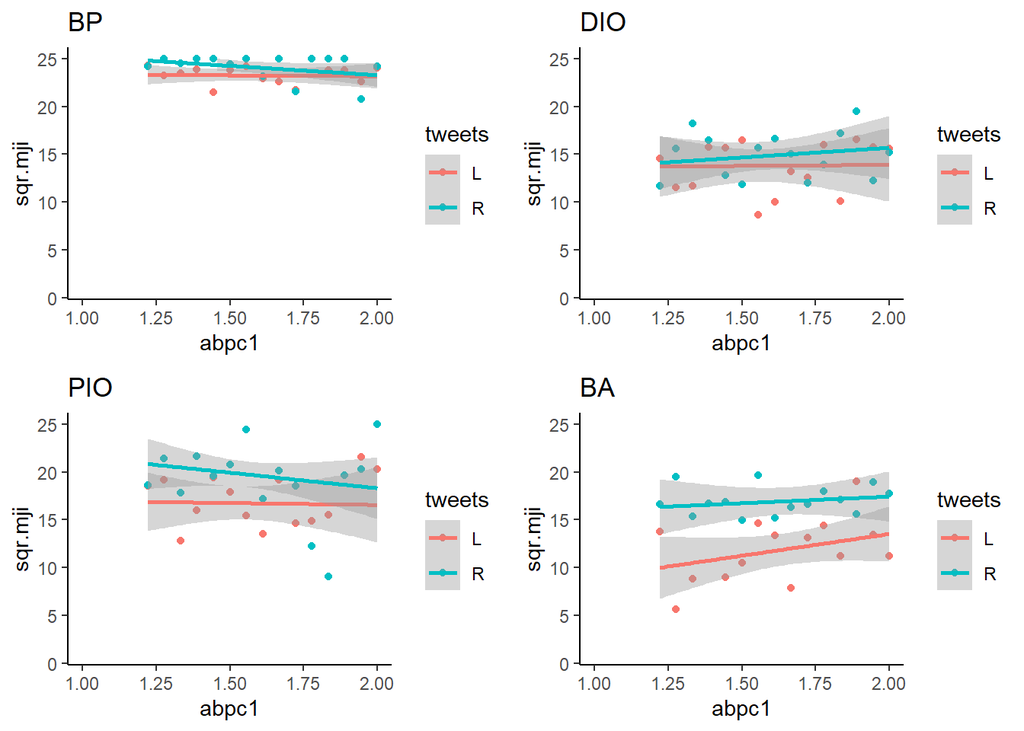

### Full model

```
##
## Call:
## lm(formula = sqr.mji ~ abpc * PI * DI * tweets, data = subset(dat,
##     abpc.mi >= med.abpc.mi))
##
## Residuals:
##     Min      1Q  Median      3Q     Max
## -15.916  -3.820   0.844   3.210  12.744
##
## Coefficients:
##                      Estimate Std. Error t value Pr(>|t|)
## (Intercept)           7.85280    3.05485   2.571   0.0104 *
## abpc                  2.54938    1.22871   2.075   0.0385 *
## PI1                   7.72552    4.44290   1.739   0.0826 .
## DI1                   1.26074    4.42115   0.285   0.7756
## tweetsR               9.50718    4.06627   2.338   0.0197 *
## abpc:PI1             -1.55467    1.75631  -0.885   0.3764
## abpc:DI1             -0.12932    1.74371  -0.074   0.9409
## PI1:DI1               4.24107    6.37376   0.665   0.5061
## abpc:tweetsR         -3.59300    1.61333  -2.227   0.0263 *
## PI1:tweetsR          -4.62502    6.20924  -0.745   0.4567
## DI1:tweetsR          -5.31414    6.13235  -0.867   0.3866
## abpc:PI1:DI1          0.09022    2.50089   0.036   0.9712
## abpc:PI1:tweetsR      1.49486    2.41720   0.618   0.5365
## abpc:DI1:tweetsR      0.94589    2.42635   0.390   0.6968
## PI1:DI1:tweetsR       0.52182    8.93186   0.058   0.9534
## abpc:PI1:DI1:tweetsR  0.97395    3.49529   0.279   0.7806
## ---
## Signif. codes:  0 '***' 0.001 '**' 0.01 '*' 0.05 '.' 0.1 ' ' 1
##
## Residual standard error: 5.517 on 548 degrees of freedom
## Multiple R-squared:  0.3321, Adjusted R-squared:  0.3138
## F-statistic: 18.17 on 15 and 548 DF,  p-value: < 2.2e-16
```

### Regression Coefficients

```
##
## Call:
## lm(formula = sqr.mji ~ abpc * PI * DI * tweets, data = subset(dat,
##     abpc.mi >= med.abpc.mi))
##
## Standardized Coefficients::
##          (Intercept)                 abpc                  PI1
##                   NA           0.20639078           0.58044669
##                  DI1              tweetsR             abpc:PI1
##           0.09471736           0.71420122          -0.30743924
##             abpc:DI1              PI1:DI1         abpc:tweetsR
##          -0.02524248           0.27468220          -0.70828162
##          PI1:tweetsR          DI1:tweetsR         abpc:PI1:DI1
##          -0.30446117          -0.34745260           0.01503123
##     abpc:PI1:tweetsR     abpc:DI1:tweetsR      PI1:DI1:tweetsR
##           0.25731296           0.15728375           0.02692666
## abpc:PI1:DI1:tweetsR
##           0.12890078
```

### BA

```
##
## Call:
## lm(formula = sqr.mji ~ abpc * tweets, data = subset(dat, Cond_int ==
##     "BA" & abpc.mi >= med.abpc.mi))
##
## Residuals:
##      Min       1Q   Median       3Q      Max
## -11.7532  -4.5577  -0.2965   3.7976  12.7437
##
## Coefficients:
##              Estimate Std. Error t value Pr(>|t|)
## (Intercept)     7.853      3.300   2.380   0.0186 *
## abpc            2.549      1.327   1.921   0.0567 .
## tweetsR         9.894      4.397   2.250   0.0260 *
## abpc:tweetsR   -3.805      1.747  -2.179   0.0310 *
## ---
## Signif. codes:  0 '***' 0.001 '**' 0.01 '*' 0.05 '.' 0.1 ' ' 1
##
## Residual standard error: 5.959 on 145 degrees of freedom
## Multiple R-squared:  0.03499,    Adjusted R-squared:  0.01503
## F-statistic: 1.753 on 3 and 145 DF,  p-value: 0.1589
```

### Regression Coefficients

```
##
## Call:
## lm(formula = sqr.mji ~ abpc * tweets, data = subset(dat, Cond_int ==
##     "BA" & abpc.mi >= med.abpc.mi))
##
## Standardized Coefficients::
##  (Intercept)         abpc      tweetsR abpc:tweetsR
##           NA    0.2413866    0.8265038   -0.8370032
```

### PIO

```
##
## Call:
## lm(formula = sqr.mji ~ abpc * tweets, data = subset(dat, Cond_int ==
##     "PIO" & abpc.mi >= med.abpc.mi))
##
## Residuals:
##     Min      1Q  Median      3Q     Max
## -15.916  -4.259   0.533   5.215   8.753
##
## Coefficients:
##              Estimate Std. Error t value Pr(>|t|)
## (Intercept)   15.5783     3.6872   4.225 4.39e-05 ***
## abpc           0.9947     1.4343   0.693    0.489
## tweetsR        4.8822     5.3633   0.910    0.364
## abpc:tweetsR  -2.0981     2.0573  -1.020    0.310
## ---
## Signif. codes:  0 '***' 0.001 '**' 0.01 '*' 0.05 '.' 0.1 ' ' 1
##
## Residual standard error: 6.305 on 134 degrees of freedom
## Multiple R-squared:  0.009163,   Adjusted R-squared:  -0.01302
## F-statistic: 0.4131 on 3 and 134 DF,  p-value: 0.7439
```

### Regression Coefficients

```
##
## Call:
## lm(formula = sqr.mji ~ abpc * tweets, data = subset(dat, Cond_int ==
##     "PIO" & abpc.mi >= med.abpc.mi))
##
## Standardized Coefficients::
##  (Intercept)         abpc      tweetsR abpc:tweetsR
##           NA   0.08339797   0.39109197  -0.45221345
```

### DIO

```
##
## Call:
## lm(formula = sqr.mji ~ abpc * tweets, data = subset(dat, Cond_int ==
##     "DIO" & abpc.mi >= med.abpc.mi))
##
## Residuals:
##      Min       1Q   Median       3Q      Max
## -13.7513  -5.2287   0.4008   4.9763  12.1558
##
## Coefficients:
##              Estimate Std. Error t value Pr(>|t|)
## (Intercept)     9.114      3.572   2.551   0.0119 *
## abpc            2.420      1.383   1.750   0.0824 .
## tweetsR         3.375      5.114   0.660   0.5103
## abpc:tweetsR   -2.237      2.015  -1.110   0.2689
## ---
## Signif. codes:  0 '***' 0.001 '**' 0.01 '*' 0.05 '.' 0.1 ' ' 1
##
## Residual standard error: 6.166 on 134 degrees of freedom
## Multiple R-squared:  0.05539,    Adjusted R-squared:  0.03425
## F-statistic: 2.619 on 3 and 134 DF,  p-value: 0.05348
```

### Regression Coefficients

```
##
## Call:
## lm(formula = sqr.mji ~ abpc * tweets, data = subset(dat, Cond_int ==
##     "DIO" & abpc.mi >= med.abpc.mi))
##
## Standardized Coefficients::
##  (Intercept)         abpc      tweetsR abpc:tweetsR
##           NA    0.2026996    0.2698609   -0.4554350
```

### BP

```
##
## Call:
## lm(formula = sqr.mji ~ abpc * tweets, data = subset(dat, Cond_int ==
##     "BP" & abpc.mi >= med.abpc.mi))
##
## Residuals:
##      Min       1Q   Median       3Q      Max
## -10.4982  -0.8805   1.3567   1.8867   2.5345
##
## Coefficients:
##              Estimate Std. Error t value Pr(>|t|)
## (Intercept)  21.08013    1.71738  12.275   <2e-16 ***
## abpc          0.95561    0.67307   1.420    0.158
## tweetsR       0.08984    2.36008   0.038    0.970
## abpc:tweetsR -0.17829    0.92413  -0.193    0.847
## ---
## Signif. codes:  0 '***' 0.001 '**' 0.01 '*' 0.05 '.' 0.1 ' ' 1
##
## Residual standard error: 2.9 on 135 degrees of freedom
## Multiple R-squared:  0.02887,    Adjusted R-squared:  0.007285
## F-statistic: 1.338 on 3 and 135 DF,  p-value: 0.2649
```

### Regression Coefficients

```
##
## Call:
## lm(formula = sqr.mji ~ abpc * tweets, data = subset(dat, Cond_int ==
##     "BP" & abpc.mi >= med.abpc.mi))
##
## Standardized Coefficients::
##  (Intercept)         abpc      tweetsR abpc:tweetsR
##           NA   0.17574295   0.01539696  -0.08011254
```

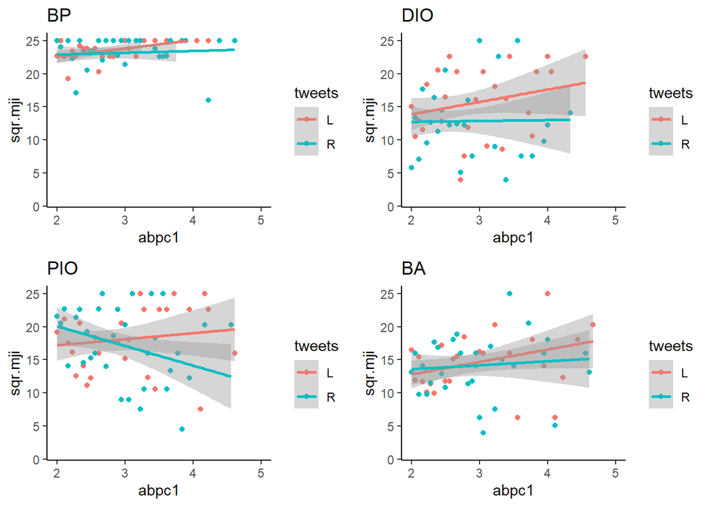

## Left of midpoint (ABPC < 2) w/ ABPC factor 2 (RT)

- Full cases =501
- BA cases =124
- PIO cases =120
- DIO cases =123
- BP cases =134

### Full model

```
##
## Call:
## lm(formula = sqr.mji ~ abpc * PI * DI * tweets, data = subset(dat,
##     abpc.rt < med.abpc.rt))
##
## Residuals:
##      Min       1Q   Median       3Q      Max
## -13.5920  -3.5719   0.8231   3.2231  12.8463
##
## Coefficients:
##                      Estimate Std. Error t value Pr(>|t|)
## (Intercept)            6.1249     3.0349   2.018  0.04412 *
## abpc                   3.6173     1.6223   2.230  0.02622 *
## PI1                    9.9848     4.7848   2.087  0.03743 *
## DI1                    2.0356     4.4534   0.457  0.64780
## tweetsR               14.7438     4.8812   3.021  0.00266 **
## abpc:PI1              -3.0814     2.8461  -1.083  0.27950
## abpc:DI1              -0.4019     2.4775  -0.162  0.87120
## PI1:DI1                5.8670     6.6115   0.887  0.37531
## abpc:tweetsR          -5.9651     2.7619  -2.160  0.03128 *
## PI1:tweetsR          -10.4032     6.8204  -1.525  0.12783
## DI1:tweetsR           -2.0737     6.7761  -0.306  0.75971
## abpc:PI1:DI1          -0.6169     3.9151  -0.158  0.87487
## abpc:PI1:tweetsR       5.0504     4.0022   1.262  0.20759
## abpc:DI1:tweetsR      -1.2575     3.8896  -0.323  0.74661
## PI1:DI1:tweetsR        0.1187     9.3772   0.013  0.98990
## abpc:PI1:DI1:tweetsR   1.0261     5.4852   0.187  0.85168
## ---
## Signif. codes:  0 '***' 0.001 '**' 0.01 '*' 0.05 '.' 0.1 ' ' 1
##
## Residual standard error: 5.394 on 485 degrees of freedom
## Multiple R-squared:  0.3704, Adjusted R-squared:  0.3509
## F-statistic: 19.02 on 15 and 485 DF,  p-value: < 2.2e-16
```

### Regression Coefficients

```
##
## Call:
## lm(formula = sqr.mji ~ abpc * PI * DI * tweets, data = subset(dat,
##     abpc.rt < med.abpc.rt))
##
## Standardized Coefficients::
##          (Intercept)                 abpc                  PI1
##                   NA          0.199811905          0.746341981
##                  DI1              tweetsR             abpc:PI1
##          0.152122193          1.102064008         -0.400961631
##             abpc:DI1              PI1:DI1         abpc:tweetsR
##         -0.052827663          0.388270290         -0.792258028
##          PI1:tweetsR          DI1:tweetsR         abpc:PI1:DI1
##         -0.676603137         -0.133068289         -0.070776978
##     abpc:PI1:tweetsR     abpc:DI1:tweetsR      PI1:DI1:tweetsR
##          0.587348111         -0.141792055          0.005845837
## abpc:PI1:DI1:tweetsR
##          0.090784252
```

### BA

```
##
## Call:
## lm(formula = sqr.mji ~ abpc * tweets, data = subset(dat, Cond_int ==
##     "BA" & abpc.rt < med.abpc.rt))
##
## Residuals:
##      Min       1Q   Median       3Q      Max
## -10.7769  -4.7312   0.1554   4.1963  12.8463
##
## Coefficients:
##              Estimate Std. Error t value Pr(>|t|)
## (Intercept)     6.125      3.382   1.811  0.07266 .
## abpc            3.617      1.808   2.001  0.04768 *
## tweetsR        14.744      5.440   2.710  0.00771 **
## abpc:tweetsR   -5.965      3.078  -1.938  0.05498 .
## ---
## Signif. codes:  0 '***' 0.001 '**' 0.01 '*' 0.05 '.' 0.1 ' ' 1
##
## Residual standard error: 6.012 on 120 degrees of freedom
## Multiple R-squared:  0.1429, Adjusted R-squared:  0.1215
## F-statistic: 6.669 on 3 and 120 DF,  p-value: 0.0003339
```

### Regression Coefficients

```
##
## Call:
## lm(formula = sqr.mji ~ abpc * tweets, data = subset(dat, Cond_int ==
##     "BA" & abpc.rt < med.abpc.rt))
##
## Standardized Coefficients::
##  (Intercept)         abpc      tweetsR abpc:tweetsR
##           NA    0.2122963    1.1503043   -0.8097684
```

### PIO

```
##
## Call:
## lm(formula = sqr.mji ~ abpc * tweets, data = subset(dat, Cond_int ==
##     "PIO" & abpc.rt < med.abpc.rt))
##
## Residuals:
##      Min       1Q   Median       3Q      Max
## -13.5920  -4.7123   0.7902   5.1580   8.2244
##
## Coefficients:
##              Estimate Std. Error t value Pr(>|t|)
## (Intercept)   16.1098     4.1976   3.838 0.000203 ***
## abpc           0.5359     2.6536   0.202 0.840314
## tweetsR        4.3407     5.4054   0.803 0.423603
## abpc:tweetsR  -0.9147     3.2868  -0.278 0.781274
## ---
## Signif. codes:  0 '***' 0.001 '**' 0.01 '*' 0.05 '.' 0.1 ' ' 1
##
## Residual standard error: 6.121 on 116 degrees of freedom
## Multiple R-squared:  0.05374,    Adjusted R-squared:  0.02927
## F-statistic: 2.196 on 3 and 116 DF,  p-value: 0.09227
```

### Regression Coefficients

```
##
## Call:
## lm(formula = sqr.mji ~ abpc * tweets, data = subset(dat, Cond_int ==
##     "PIO" & abpc.rt < med.abpc.rt))
##
## Standardized Coefficients::
##  (Intercept)         abpc      tweetsR abpc:tweetsR
##           NA   0.03168211   0.34959087  -0.13311527
```

### DIO

```
##
## Call:
## lm(formula = sqr.mji ~ abpc * tweets, data = subset(dat, Cond_int ==
##     "DIO" & abpc.rt < med.abpc.rt))
##
## Residuals:
##      Min       1Q   Median       3Q      Max
## -10.0672  -5.4833  -0.3324   5.2576  12.2600
##
## Coefficients:
##              Estimate Std. Error t value Pr(>|t|)
## (Intercept)     8.161      3.724   2.191   0.0304 *
## abpc            3.215      2.140   1.503   0.1355
## tweetsR        12.670      5.370   2.359   0.0199 *
## abpc:tweetsR   -7.223      3.129  -2.308   0.0227 *
## ---
## Signif. codes:  0 '***' 0.001 '**' 0.01 '*' 0.05 '.' 0.1 ' ' 1
##
## Residual standard error: 6.163 on 119 degrees of freedom
## Multiple R-squared:  0.04483,    Adjusted R-squared:  0.02075
## F-statistic: 1.862 on 3 and 119 DF,  p-value: 0.1398
```

### Regression Coefficients

```
##
## Call:
## lm(formula = sqr.mji ~ abpc * tweets, data = subset(dat, Cond_int ==
##     "DIO" & abpc.rt < med.abpc.rt))
##
## Standardized Coefficients::
##  (Intercept)         abpc      tweetsR abpc:tweetsR
##           NA    0.1848566    1.0210086   -1.0057753
```

### BP

```
##
## Call:
## lm(formula = sqr.mji ~ abpc * tweets, data = subset(dat, Cond_int ==
##     "BP" & abpc.rt < med.abpc.rt))
##
## Residuals:
##      Min       1Q   Median       3Q      Max
## -11.4826  -0.7768   1.0699   1.6899   3.1925
##
## Coefficients:
##              Estimate Std. Error t value Pr(>|t|)
## (Intercept)   24.0124     1.5651  15.342   <2e-16 ***
## abpc          -0.4829     0.9456  -0.511    0.610
## tweetsR        2.3857     2.1548   1.107    0.270
## abpc:tweetsR  -1.1461     1.2563  -0.912    0.363
## ---
## Signif. codes:  0 '***' 0.001 '**' 0.01 '*' 0.05 '.' 0.1 ' ' 1
##
## Residual standard error: 2.644 on 130 degrees of freedom
## Multiple R-squared:  0.03455,    Adjusted R-squared:  0.01227
## F-statistic: 1.551 on 3 and 130 DF,  p-value: 0.2045
```

### Regression Coefficients

```
##
## Call:
## lm(formula = sqr.mji ~ abpc * tweets, data = subset(dat, Cond_int ==
##     "BP" & abpc.rt < med.abpc.rt))
##
## Standardized Coefficients::
##  (Intercept)         abpc      tweetsR abpc:tweetsR
##           NA  -0.06775184   0.44880995  -0.39448732
```

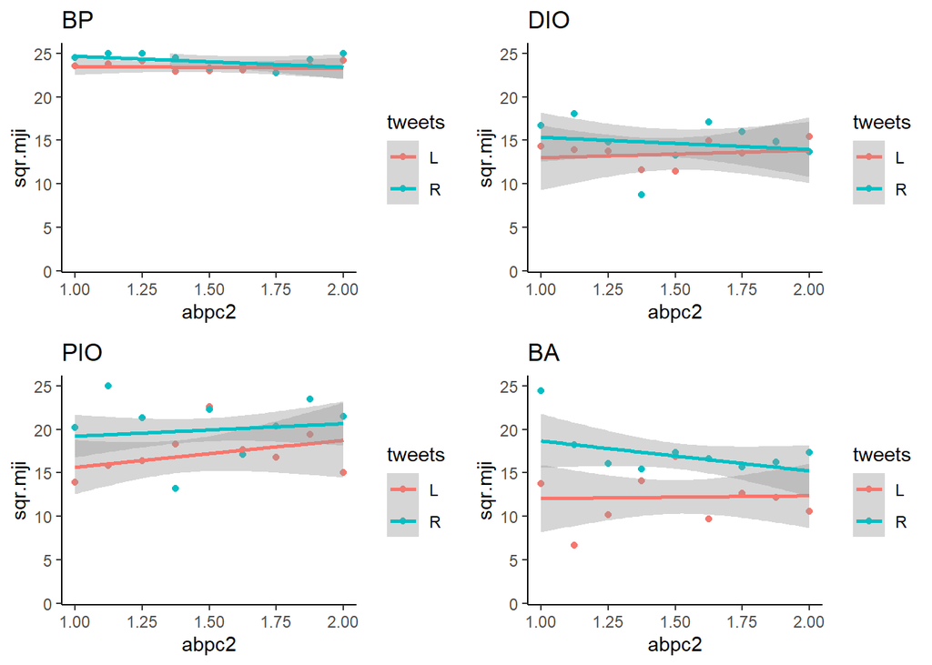

## RIGHT of midpoint (ABPC > 2) w/ ABPC factor 2 (RT)

- Full cases =553
- BA cases =137
- PIO cases =147
- DIO cases =138
- BP cases =131

### Full model

```
##
## Call:
## lm(formula = sqr.mji ~ abpc * PI * DI * tweets, data = subset(dat,
##     abpc.rt >= med.abpc.rt))
##
## Residuals:
##     Min      1Q  Median      3Q     Max
## -15.237  -3.587   1.038   3.643  12.208
##
## Coefficients:
##                      Estimate Std. Error t value Pr(>|t|)
## (Intercept)           6.97234    2.99969   2.324   0.0205 *
## abpc                  2.86622    1.22609   2.338   0.0198 *
## PI1                   4.46767    4.21968   1.059   0.2902
## DI1                   4.49784    4.09844   1.097   0.2729
## tweetsR               7.44694    3.98774   1.867   0.0624 .
## abpc:PI1             -0.36285    1.70863  -0.212   0.8319
## abpc:DI1             -1.33841    1.65502  -0.809   0.4190
## PI1:DI1               5.60775    5.86153   0.957   0.3391
## abpc:tweetsR         -2.98354    1.59968  -1.865   0.0627 .
## PI1:tweetsR          -0.99005    5.83819  -0.170   0.8654
## DI1:tweetsR          -3.47907    5.75371  -0.605   0.5457
## abpc:PI1:DI1         -0.34944    2.35598  -0.148   0.8821
## abpc:PI1:tweetsR     -0.03648    2.31819  -0.016   0.9875
## abpc:DI1:tweetsR      0.70612    2.31549   0.305   0.7605
## PI1:DI1:tweetsR       0.01885    8.26706   0.002   0.9982
## abpc:PI1:DI1:tweetsR  1.16851    3.29661   0.354   0.7231
## ---
## Signif. codes:  0 '***' 0.001 '**' 0.01 '*' 0.05 '.' 0.1 ' ' 1
##
## Residual standard error: 5.531 on 537 degrees of freedom
## Multiple R-squared:  0.3384, Adjusted R-squared:  0.3199
## F-statistic: 18.31 on 15 and 537 DF,  p-value: < 2.2e-16
```

### Regression Coefficients

```
##
## Call:
## lm(formula = sqr.mji ~ abpc * PI * DI * tweets, data = subset(dat,
##     abpc.rt >= med.abpc.rt))
##
## Standardized Coefficients::
##          (Intercept)                 abpc                  PI1
##                   NA         0.2465049615         0.3333397252
##                  DI1              tweetsR             abpc:PI1
##         0.3354371906         0.5556351595        -0.0701909555
##             abpc:DI1              PI1:DI1         abpc:tweetsR
##        -0.2558243738         0.3557937233        -0.5789235827
##          PI1:tweetsR          DI1:tweetsR         abpc:PI1:DI1
##        -0.0639346238        -0.2230159391        -0.0563221260
##     abpc:PI1:tweetsR     abpc:DI1:tweetsR      PI1:DI1:tweetsR
##        -0.0060808391         0.1137640542         0.0009354752
## abpc:PI1:DI1:tweetsR
##         0.1473392553
```

### BA

```
##
## Call:
## lm(formula = sqr.mji ~ abpc * tweets, data = subset(dat, Cond_int ==
##     "BA" & abpc.rt >= med.abpc.rt))
##
## Residuals:
##      Min       1Q   Median       3Q      Max
## -11.2318  -4.1869   0.0816   4.0473  12.2084
##
## Coefficients:
##              Estimate Std. Error t value Pr(>|t|)
## (Intercept)     6.972      3.222   2.164   0.0322 *
## abpc            2.866      1.317   2.176   0.0313 *
## tweetsR         7.824      4.288   1.825   0.0703 .
## abpc:tweetsR   -3.196      1.722  -1.856   0.0656 .
## ---
## Signif. codes:  0 '***' 0.001 '**' 0.01 '*' 0.05 '.' 0.1 ' ' 1
##
## Residual standard error: 5.941 on 133 degrees of freedom
## Multiple R-squared:  0.03524,    Adjusted R-squared:  0.01348
## F-statistic: 1.619 on 3 and 133 DF,  p-value: 0.1879
```

### Regression Coefficients

```
##
## Call:
## lm(formula = sqr.mji ~ abpc * tweets, data = subset(dat, Cond_int ==
##     "BA" & abpc.rt >= med.abpc.rt))
##
## Standardized Coefficients::
##  (Intercept)         abpc      tweetsR abpc:tweetsR
##           NA    0.2885385    0.6549652   -0.7055506
```

### PIO

```
##
## Call:
## lm(formula = sqr.mji ~ abpc * tweets, data = subset(dat, Cond_int ==
##     "PIO" & abpc.rt >= med.abpc.rt))
##
## Residuals:
##     Min      1Q  Median      3Q     Max
## -15.237  -4.466   1.340   5.589   9.076
##
## Coefficients:
##              Estimate Std. Error t value Pr(>|t|)
## (Intercept)    11.440      3.439   3.327  0.00112 **
## abpc            2.503      1.379   1.816  0.07153 .
## tweetsR         6.457      4.941   1.307  0.19335
## abpc:tweetsR   -3.020      1.944  -1.553  0.12251
## ---
## Signif. codes:  0 '***' 0.001 '**' 0.01 '*' 0.05 '.' 0.1 ' ' 1
##
## Residual standard error: 6.409 on 143 degrees of freedom
## Multiple R-squared:  0.02883,    Adjusted R-squared:  0.008458
## F-statistic: 1.415 on 3 and 143 DF,  p-value: 0.2408
```

### Regression Coefficients

```
##
## Call:
## lm(formula = sqr.mji ~ abpc * tweets, data = subset(dat, Cond_int ==
##     "PIO" & abpc.rt >= med.abpc.rt))
##
## Standardized Coefficients::
##  (Intercept)         abpc      tweetsR abpc:tweetsR
##           NA    0.2129276    0.5019111   -0.6201409
```

### DIO

```
##
## Call:
## lm(formula = sqr.mji ~ abpc * tweets, data = subset(dat, Cond_int ==
##     "DIO" & abpc.rt >= med.abpc.rt))
##
## Residuals:
##      Min       1Q   Median       3Q      Max
## -13.2689  -5.0018   0.3091   4.8891  11.4166
##
## Coefficients:
##              Estimate Std. Error t value Pr(>|t|)
## (Intercept)    11.470      3.089   3.713   0.0003 ***
## abpc            1.528      1.230   1.242   0.2163
## tweetsR         3.247      4.573   0.710   0.4789
## abpc:tweetsR   -1.902      1.841  -1.033   0.3035
## ---
## Signif. codes:  0 '***' 0.001 '**' 0.01 '*' 0.05 '.' 0.1 ' ' 1
##
## Residual standard error: 6.119 on 134 degrees of freedom
## Multiple R-squared:  0.02457,    Adjusted R-squared:  0.002727
## F-statistic: 1.125 on 3 and 134 DF,  p-value: 0.3414
```

### Regression Coefficients

```
##
## Call:
## lm(formula = sqr.mji ~ abpc * tweets, data = subset(dat, Cond_int ==
##     "DIO" & abpc.rt >= med.abpc.rt))
##
## Standardized Coefficients::
##  (Intercept)         abpc      tweetsR abpc:tweetsR
##           NA    0.1425209    0.2656382   -0.3914174
```

### BP

```
##
## Call:
## lm(formula = sqr.mji ~ abpc * tweets, data = subset(dat, Cond_int ==
##     "BP" & abpc.rt >= med.abpc.rt))
##
## Residuals:
##      Min       1Q   Median       3Q      Max
## -11.6226  -0.9972   1.1075   1.4373   2.1941
##
## Coefficients:
##              Estimate Std. Error t value Pr(>|t|)
## (Intercept)   21.5456     1.3892  15.509   <2e-16 ***
## abpc           0.8155     0.5547   1.470    0.144
## tweetsR        2.9967     1.9393   1.545    0.125
## abpc:tweetsR  -1.1454     0.7703  -1.487    0.140
## ---
## Signif. codes:  0 '***' 0.001 '**' 0.01 '*' 0.05 '.' 0.1 ' ' 1
##
## Residual standard error: 2.597 on 127 degrees of freedom
## Multiple R-squared:  0.0211, Adjusted R-squared:  -0.002026
## F-statistic: 0.9124 on 3 and 127 DF,  p-value: 0.4371
```

### Regression Coefficients

```
##
## Call:
## lm(formula = sqr.mji ~ abpc * tweets, data = subset(dat, Cond_int ==
##     "BP" & abpc.rt >= med.abpc.rt))
##
## Standardized Coefficients::
##  (Intercept)         abpc      tweetsR abpc:tweetsR
##           NA    0.1860892    0.5782973   -0.5762239
```

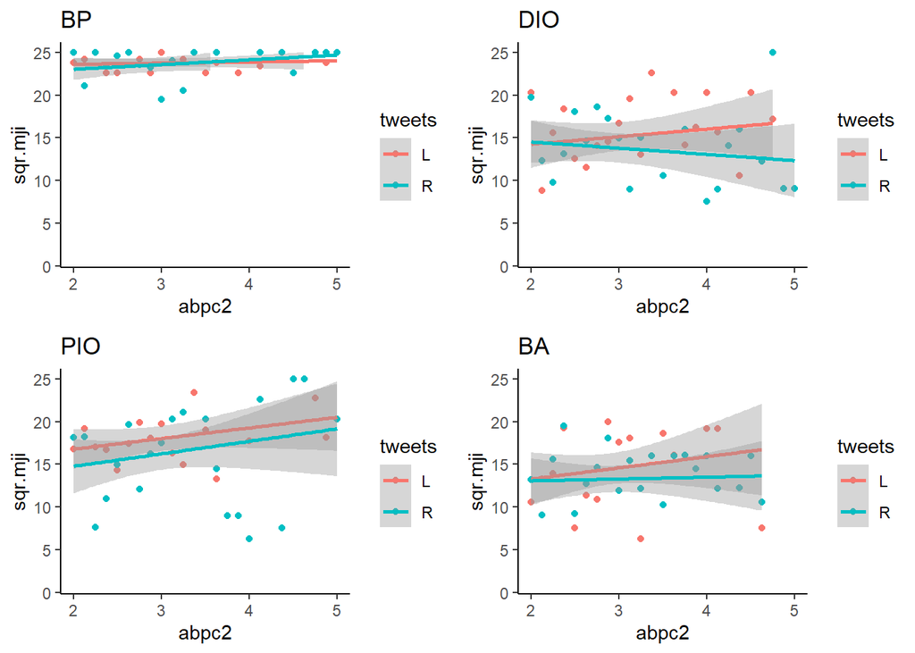

## Left of midpoint (ABPC < 2) w/ ABPC factor 3 (ES)

- Full cases =439
- BA cases =107
- PIO cases =106
- DIO cases =115
- BP cases =111

### Full model

```
##
## Call:
## lm(formula = sqr.mji ~ abpc * PI * DI * tweets, data = subset(dat,
##     abpc.es < med.abpc.es))
##
## Residuals:
##      Min       1Q   Median       3Q      Max
## -12.2956  -3.6215   0.6656   2.9987  13.9800
##
## Coefficients:
##                      Estimate Std. Error t value Pr(>|t|)
## (Intercept)             7.056      3.177   2.221 0.026890 *
## abpc                    2.295      1.752   1.309 0.191094
## PI1                     7.245      4.468   1.622 0.105655
## DI1                     7.859      4.922   1.597 0.111029
## tweetsR                17.501      5.267   3.323 0.000969 ***
## abpc:PI1               -1.268      2.532  -0.501 0.616788
## abpc:DI1               -3.289      2.811  -1.170 0.242681
## PI1:DI1                 1.661      7.035   0.236 0.813508
## abpc:tweetsR           -6.839      2.995  -2.283 0.022914 *
## PI1:tweetsR            -9.054      7.093  -1.276 0.202501
## DI1:tweetsR           -14.200      7.135  -1.990 0.047225 *
## abpc:PI1:DI1            1.782      4.146   0.430 0.667670
## abpc:PI1:tweetsR        3.195      4.075   0.784 0.433389
## abpc:DI1:tweetsR        5.481      4.083   1.343 0.180107
## PI1:DI1:tweetsR         8.696     10.143   0.857 0.391710
## abpc:PI1:DI1:tweetsR   -3.257      5.922  -0.550 0.582590
## ---
## Signif. codes:  0 '***' 0.001 '**' 0.01 '*' 0.05 '.' 0.1 ' ' 1
##
## Residual standard error: 5.439 on 423 degrees of freedom
## Multiple R-squared:  0.3835, Adjusted R-squared:  0.3616
## F-statistic: 17.54 on 15 and 423 DF,  p-value: < 2.2e-16
```

### Regression Coefficients

```
##
## Call:
## lm(formula = sqr.mji ~ abpc * PI * DI * tweets, data = subset(dat,
##     abpc.es < med.abpc.es))
##
## Standardized Coefficients::
##          (Intercept)                 abpc                  PI1
##                   NA            0.1236723            0.5326614
##                  DI1              tweetsR             abpc:PI1
##            0.5776504            1.2867661           -0.1605824
##             abpc:DI1              PI1:DI1         abpc:tweetsR
##           -0.4205205            0.1061408           -0.8907239
##          PI1:tweetsR          DI1:tweetsR         abpc:PI1:DI1
##           -0.5642173           -0.9103277            0.1895972
##     abpc:PI1:tweetsR     abpc:DI1:tweetsR      PI1:DI1:tweetsR
##            0.3430390            0.6174533            0.4166789
## abpc:PI1:DI1:tweetsR
##           -0.2665693
```

### BA

```
##
## Call:
## lm(formula = sqr.mji ~ abpc * tweets, data = subset(dat, Cond_int ==
##     "BA" & abpc.es < med.abpc.es))
##
## Residuals:
##      Min       1Q   Median       3Q      Max
## -11.2114  -3.8704  -0.9838   3.6697  13.9800
##
## Coefficients:
##              Estimate Std. Error t value Pr(>|t|)
## (Intercept)     7.056      3.347   2.108  0.03741 *
## abpc            2.295      1.846   1.243  0.21662
## tweetsR        17.501      5.548   3.155  0.00211 **
## abpc:tweetsR   -6.839      3.155  -2.168  0.03249 *
## ---
## Signif. codes:  0 '***' 0.001 '**' 0.01 '*' 0.05 '.' 0.1 ' ' 1
##
## Residual standard error: 5.729 on 103 degrees of freedom
## Multiple R-squared:  0.2314, Adjusted R-squared:  0.209
## F-statistic: 10.34 on 3 and 103 DF,  p-value: 5.252e-06
```

### Regression Coefficients

```
##
## Call:
## lm(formula = sqr.mji ~ abpc * tweets, data = subset(dat, Cond_int ==
##     "BA" & abpc.es < med.abpc.es))
##
## Standardized Coefficients::
##  (Intercept)         abpc      tweetsR abpc:tweetsR
##           NA    0.1327242    1.3547024   -0.9316832
```

### PIO

```
##
## Call:
## lm(formula = sqr.mji ~ abpc * tweets, data = subset(dat, Cond_int ==
##     "PIO" & abpc.es < med.abpc.es))
##
## Residuals:
##      Min       1Q   Median       3Q      Max
## -12.2956  -5.7607   0.9907   4.9587   9.4233
##
## Coefficients:
##              Estimate Std. Error t value Pr(>|t|)
## (Intercept)    14.301      3.594   3.979  0.00013 ***
## abpc            1.027      2.091   0.491  0.62445
## tweetsR         8.447      5.435   1.554  0.12324
## abpc:tweetsR   -3.644      3.161  -1.153  0.25176
## ---
## Signif. codes:  0 '***' 0.001 '**' 0.01 '*' 0.05 '.' 0.1 ' ' 1
##
## Residual standard error: 6.223 on 102 degrees of freedom
## Multiple R-squared:  0.04834,    Adjusted R-squared:  0.02035
## F-statistic: 1.727 on 3 and 102 DF,  p-value: 0.1662
```

### Regression Coefficients

```
##
## Call:
## lm(formula = sqr.mji ~ abpc * tweets, data = subset(dat, Cond_int ==
##     "PIO" & abpc.es < med.abpc.es))
##
## Standardized Coefficients::
##  (Intercept)         abpc      tweetsR abpc:tweetsR
##           NA   0.06324694   0.67386101  -0.51019642
```

### DIO

```
##
## Call:
## lm(formula = sqr.mji ~ abpc * tweets, data = subset(dat, Cond_int ==
##     "DIO" & abpc.es < med.abpc.es))
##
## Residuals:
##      Min       1Q   Median       3Q      Max
## -11.2347  -5.4851  -0.4963   4.7027  12.4133
##
## Coefficients:
##              Estimate Std. Error t value Pr(>|t|)
## (Intercept)   14.9158     4.3015   3.468 0.000748 ***
## abpc          -0.9944     2.5159  -0.395 0.693417
## tweetsR        3.3012     5.5088   0.599 0.550226
## abpc:tweetsR  -1.3575     3.1748  -0.428 0.669780
## ---
## Signif. codes:  0 '***' 0.001 '**' 0.01 '*' 0.05 '.' 0.1 ' ' 1
##
## Residual standard error: 6.225 on 111 degrees of freedom
## Multiple R-squared:  0.01979,    Adjusted R-squared:  -0.006701
## F-statistic: 0.7471 on 3 and 111 DF,  p-value: 0.5263
```

### Regression Coefficients

```
##
## Call:
## lm(formula = sqr.mji ~ abpc * tweets, data = subset(dat, Cond_int ==
##     "DIO" & abpc.es < med.abpc.es))
##
## Standardized Coefficients::
##  (Intercept)         abpc      tweetsR abpc:tweetsR
##           NA  -0.06102749   0.26711714  -0.20084072
```

### BP

```
##
## Call:
## lm(formula = sqr.mji ~ abpc * tweets, data = subset(dat, Cond_int ==
##     "BP" & abpc.es < med.abpc.es))
##
## Residuals:
##      Min       1Q   Median       3Q      Max
## -11.4051  -0.5664   0.9994   1.8274   3.1302
##
## Coefficients:
##              Estimate Std. Error t value Pr(>|t|)
## (Intercept)   23.8211     2.0717  11.498   <2e-16 ***
## abpc          -0.4809     1.2877  -0.373    0.710
## tweetsR        2.9438     2.8624   1.028    0.306
## abpc:tweetsR  -1.4196     1.7329  -0.819    0.414
## ---
## Signif. codes:  0 '***' 0.001 '**' 0.01 '*' 0.05 '.' 0.1 ' ' 1
##
## Residual standard error: 2.872 on 107 degrees of freedom
## Multiple R-squared:  0.03411,    Adjusted R-squared:  0.00703
## F-statistic:  1.26 on 3 and 107 DF,  p-value: 0.292
```

### Regression Coefficients

```
##
## Call:
## lm(formula = sqr.mji ~ abpc * tweets, data = subset(dat, Cond_int ==
##     "BP" & abpc.es < med.abpc.es))
##
## Standardized Coefficients::
##  (Intercept)         abpc      tweetsR abpc:tweetsR
##           NA  -0.05351636   0.51257995  -0.42861050
```

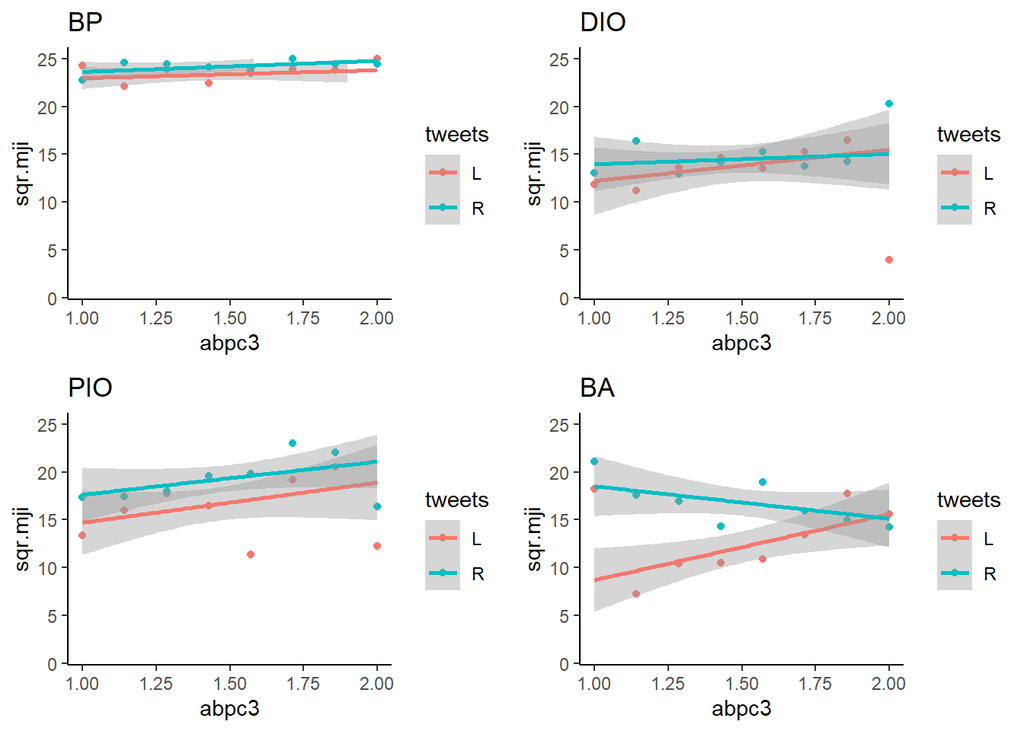

## RIGHT of midpoint (ABPC > 2) w/ ABPC factor 3 (ES)

- Full cases =615
- BA cases =154
- PIO cases =161
- DIO cases =146
- BP cases =154

### Full model

```
##
## Call:
## lm(formula = sqr.mji ~ abpc * PI * DI * tweets, data = subset(dat,
##     abpc.es >= med.abpc.es))
##
## Residuals:
##     Min      1Q  Median      3Q     Max
## -15.931  -3.670   1.071   3.592  12.058
##
## Coefficients:
##                      Estimate Std. Error t value Pr(>|t|)
## (Intercept)           10.9385     2.8524   3.835 0.000139 ***
## abpc                   1.5937     1.1860   1.344 0.179512
## PI1                    5.9507     3.8076   1.563 0.118620
## DI1                   -0.6858     3.8155  -0.180 0.857428
## tweetsR                4.5753     3.6544   1.252 0.211058
## abpc:PI1              -1.0327     1.5739  -0.656 0.511960
## abpc:DI1               0.5294     1.5685   0.338 0.735839
## PI1:DI1                6.4797     5.1818   1.250 0.211615
## abpc:tweetsR          -2.0394     1.5004  -1.359 0.174562
## PI1:tweetsR            2.5644     5.0676   0.506 0.613019
## DI1:tweetsR            1.2586     5.2380   0.240 0.810194
## abpc:PI1:DI1          -0.6923     2.1367  -0.324 0.746054
## abpc:PI1:tweetsR      -1.0168     2.0726  -0.491 0.623882
## abpc:DI1:tweetsR      -1.1213     2.1562  -0.520 0.603232
## PI1:DI1:tweetsR       -6.3813     7.2689  -0.878 0.380353
## abpc:PI1:DI1:tweetsR   3.3625     2.9786   1.129 0.259393
## ---
## Signif. codes:  0 '***' 0.001 '**' 0.01 '*' 0.05 '.' 0.1 ' ' 1
##
## Residual standard error: 5.48 on 599 degrees of freedom
## Multiple R-squared:  0.3319, Adjusted R-squared:  0.3152
## F-statistic: 19.84 on 15 and 599 DF,  p-value: < 2.2e-16
```

### Regression Coefficients

```
##
## Call:
## lm(formula = sqr.mji ~ abpc * PI * DI * tweets, data = subset(dat,
##     abpc.es >= med.abpc.es))
##
## Standardized Coefficients::
##          (Intercept)                 abpc                  PI1
##                   NA           0.14500963           0.44955287
##                  DI1              tweetsR             abpc:PI1
##          -0.05180186           0.34574696          -0.19735950
##             abpc:DI1              PI1:DI1         abpc:tweetsR
##           0.10033450           0.42429047          -0.39160304
##          PI1:tweetsR          DI1:tweetsR         abpc:PI1:DI1
##           0.17072094           0.08074565          -0.11211830
##     abpc:PI1:tweetsR     abpc:DI1:tweetsR      PI1:DI1:tweetsR
##          -0.17005411          -0.17770240          -0.32270407
## abpc:PI1:DI1:tweetsR
##           0.42672023
```

### BA

```
##
## Call:
## lm(formula = sqr.mji ~ abpc * tweets, data = subset(dat, Cond_int ==
##     "BA" & abpc.es >= med.abpc.es))
##
## Residuals:
##      Min       1Q   Median       3Q      Max
## -11.3049  -5.0855   0.2263   4.2022  11.4312
##
## Coefficients:
##              Estimate Std. Error t value Pr(>|t|)
## (Intercept)    10.939      3.160   3.462 0.000699 ***
## abpc            1.594      1.314   1.213 0.226979
## tweetsR         4.913      4.052   1.212 0.227290
## abpc:tweetsR   -2.238      1.666  -1.343 0.181179
## ---
## Signif. codes:  0 '***' 0.001 '**' 0.01 '*' 0.05 '.' 0.1 ' ' 1
##
## Residual standard error: 6.07 on 150 degrees of freedom
## Multiple R-squared:  0.01318,    Adjusted R-squared:  -0.00656
## F-statistic: 0.6676 on 3 and 150 DF,  p-value: 0.5732
```

### Regression Coefficients

```
##
## Call:
## lm(formula = sqr.mji ~ abpc * tweets, data = subset(dat, Cond_int ==
##     "BA" & abpc.es >= med.abpc.es))
##
## Standardized Coefficients::
##  (Intercept)         abpc      tweetsR abpc:tweetsR
##           NA    0.1601703    0.4070038   -0.4768040
```

### PIO

```
##
## Call:
## lm(formula = sqr.mji ~ abpc * tweets, data = subset(dat, Cond_int ==
##     "PIO" & abpc.es >= med.abpc.es))
##
## Residuals:
##     Min      1Q  Median      3Q     Max
## -15.931  -4.374   1.217   5.205  10.498
##
## Coefficients:
##              Estimate Std. Error t value Pr(>|t|)
## (Intercept)    16.889      2.927   5.770 4.11e-08 ***
## abpc            0.561      1.201   0.467   0.6410
## tweetsR         7.140      4.074   1.752   0.0817 .
## abpc:tweetsR   -3.056      1.659  -1.842   0.0674 .
## ---
## Signif. codes:  0 '***' 0.001 '**' 0.01 '*' 0.05 '.' 0.1 ' ' 1
##
## Residual standard error: 6.36 on 157 degrees of freedom
## Multiple R-squared:  0.03082,    Adjusted R-squared:  0.01231
## F-statistic: 1.664 on 3 and 157 DF,  p-value: 0.1769
```

### Regression Coefficients

```
##
## Call:
## lm(formula = sqr.mji ~ abpc * tweets, data = subset(dat, Cond_int ==
##     "PIO" & abpc.es >= med.abpc.es))
##
## Standardized Coefficients::
##  (Intercept)         abpc      tweetsR abpc:tweetsR
##           NA   0.05320402   0.55931866  -0.61129547
```

### DIO

```
##
## Call:
## lm(formula = sqr.mji ~ abpc * tweets, data = subset(dat, Cond_int ==
##     "DIO" & abpc.es >= med.abpc.es))
##
## Residuals:
##      Min       1Q   Median       3Q      Max
## -11.9144  -5.0300   0.3754   4.6572  11.6155
##
## Coefficients:
##              Estimate Std. Error t value Pr(>|t|)
## (Intercept)    10.253      2.809   3.650 0.000368 ***
## abpc            2.123      1.138   1.866 0.064102 .
## tweetsR         5.149      4.145   1.242 0.216197
## abpc:tweetsR   -2.789      1.706  -1.635 0.104309
## ---
## Signif. codes:  0 '***' 0.001 '**' 0.01 '*' 0.05 '.' 0.1 ' ' 1
##
## Residual standard error: 6.074 on 142 degrees of freedom
## Multiple R-squared:  0.04001,    Adjusted R-squared:  0.01973
## F-statistic: 1.973 on 3 and 142 DF,  p-value: 0.1208
```

### Regression Coefficients

```
##
## Call:
## lm(formula = sqr.mji ~ abpc * tweets, data = subset(dat, Cond_int ==
##     "DIO" & abpc.es >= med.abpc.es))
##
## Standardized Coefficients::
##  (Intercept)         abpc      tweetsR abpc:tweetsR
##           NA    0.2062695    0.4196346   -0.5585296
```

### BP

```
##
## Call:
## lm(formula = sqr.mji ~ abpc * tweets, data = subset(dat, Cond_int ==
##     "BP" & abpc.es >= med.abpc.es))
##
## Residuals:
##    Min     1Q Median     3Q    Max
## -9.778 -0.950  1.159  1.448  2.006
##
## Coefficients:
##              Estimate Std. Error t value Pr(>|t|)
## (Intercept)   22.6831     1.0831  20.943   <2e-16 ***
## abpc           0.3981     0.4525   0.880    0.380
## tweetsR        2.0170     1.6081   1.254    0.212
## abpc:tweetsR  -0.8151     0.6564  -1.242    0.216
## ---
## Signif. codes:  0 '***' 0.001 '**' 0.01 '*' 0.05 '.' 0.1 ' ' 1
##
## Residual standard error: 2.437 on 150 degrees of freedom
## Multiple R-squared:  0.01047,    Adjusted R-squared:  -0.00932
## F-statistic: 0.5291 on 3 and 150 DF,  p-value: 0.663
```

### Regression Coefficients

```
##
## Call:
## lm(formula = sqr.mji ~ abpc * tweets, data = subset(dat, Cond_int ==
##     "BP" & abpc.es >= med.abpc.es))
##
## Standardized Coefficients::
##  (Intercept)         abpc      tweetsR abpc:tweetsR
##           NA   0.09914216   0.41693936  -0.43280992
```

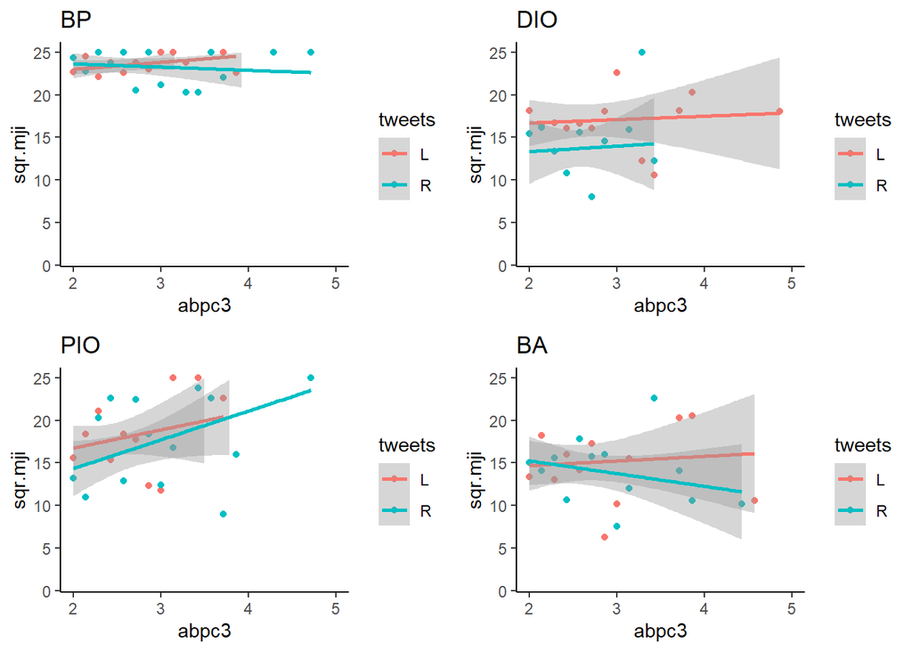

## SQUARE TRANSFORMED ABPC w/ mji factor 1

### Full model

```
##
## Call:
## lm(formula = mc.sqr.mjif1 ~ PI * DI * tweets * abpc, data = dat)
##
## Residuals:
##      Min       1Q   Median       3Q      Max
## -17.7105  -4.5410   0.5499   3.5432  16.4561
##
## Coefficients:
##                       Estimate Std. Error t value Pr(>|t|)
## (Intercept)          -11.84124    2.27126  -5.214 2.24e-07 ***
## PI1                    6.68418    3.01394   2.218 0.026787 *
## DI1                    3.20167    3.03842   1.054 0.292252
## tweetsR               11.13961    2.97814   3.740 0.000194 ***
## abpc                   2.87460    1.03511   2.777 0.005584 **
## PI1:DI1               10.35548    4.10846   2.521 0.011867 *
## PI1:tweetsR           -2.61997    4.10048  -0.639 0.523002
## DI1:tweetsR           -6.61001    4.18184  -1.581 0.114264
## PI1:abpc              -0.36981    1.38120  -0.268 0.788948
## DI1:abpc              -0.98007    1.38697  -0.707 0.479958
## tweetsR:abpc          -3.86695    1.35682  -2.850 0.004458 **
## PI1:DI1:tweetsR       -1.25823    5.77785  -0.218 0.827653
## PI1:DI1:abpc          -1.22386    1.90097  -0.644 0.519843
## PI1:tweetsR:abpc       0.04694    1.86867   0.025 0.979963
## DI1:tweetsR:abpc       1.37848    1.92443   0.716 0.473961
## PI1:DI1:tweetsR:abpc   1.83070    2.65901   0.688 0.491299
## ---
## Signif. codes:  0 '***' 0.001 '**' 0.01 '*' 0.05 '.' 0.1 ' ' 1
##
## Residual standard error: 6.624 on 1038 degrees of freedom
## Multiple R-squared:  0.4181, Adjusted R-squared:  0.4097
## F-statistic: 49.73 on 15 and 1038 DF,  p-value: < 2.2e-16
```

### Regression Coefficients

```
##
## Call:
## lm(formula = mc.sqr.mjif1 ~ PI * DI * tweets * abpc, data = dat)
##
## Standardized Coefficients::
##          (Intercept)                  PI1                  DI1
##                   NA          0.387820179          0.185769866
##              tweetsR                 abpc              PI1:DI1
##          0.646337543          0.206404352          0.521342336
##          PI1:tweetsR          DI1:tweetsR             PI1:abpc
##         -0.131901121         -0.329373619         -0.048575423
##             DI1:abpc         tweetsR:abpc      PI1:DI1:tweetsR
##         -0.127326730         -0.511048775         -0.048328568
##         PI1:DI1:abpc     PI1:tweetsR:abpc     DI1:tweetsR:abpc
##         -0.134459949          0.005311864          0.150902664
## PI1:DI1:tweetsR:abpc
##          0.156599054
```

### BA

```
##
## Call:
## lm(formula = mc.sqr.mjif1 ~ tweets * abpc, data = subset(dat,
##     Cond_int == "BA"))
##
## Residuals:
##      Min       1Q   Median       3Q      Max
## -12.6421  -6.5474  -0.0666   4.2657  16.4561
##
## Coefficients:
##              Estimate Std. Error t value Pr(>|t|)
## (Intercept)   -11.841      2.495  -4.746 3.45e-06 ***
## tweetsR        11.504      3.278   3.510 0.000529 ***
## abpc            2.875      1.137   2.528 0.012068 *
## tweetsR:abpc   -4.085      1.495  -2.732 0.006727 **
## ---
## Signif. codes:  0 '***' 0.001 '**' 0.01 '*' 0.05 '.' 0.1 ' ' 1
##
## Residual standard error: 7.276 on 257 degrees of freedom
## Multiple R-squared:  0.06596,    Adjusted R-squared:  0.05506
## F-statistic:  6.05 on 3 and 257 DF,  p-value: 0.0005391
```

### Regression Coefficients

```
##
## Call:
## lm(formula = mc.sqr.mjif1 ~ tweets * abpc, data = subset(dat,
##     Cond_int == "BA"))
##
## Standardized Coefficients::
##  (Intercept)      tweetsR         abpc tweetsR:abpc
##           NA    0.7678670    0.2347228   -0.6251365
```

### PIO

```
##
## Call:
## lm(formula = mc.sqr.mjif1 ~ tweets * abpc, data = subset(dat,
##     Cond_int == "PIO"))
##
## Residuals:
##      Min       1Q   Median       3Q      Max
## -17.7105  -6.8729   0.7051   7.8965  11.4509
##
## Coefficients:
##              Estimate Std. Error t value Pr(>|t|)
## (Intercept)    -5.157      2.368  -2.178   0.0303 *
## tweetsR         8.520      3.369   2.529   0.0120 *
## abpc            2.505      1.093   2.292   0.0227 *
## tweetsR:abpc   -3.820      1.536  -2.487   0.0135 *
## ---
## Signif. codes:  0 '***' 0.001 '**' 0.01 '*' 0.05 '.' 0.1 ' ' 1
##
## Residual standard error: 7.917 on 263 degrees of freedom
## Multiple R-squared:  0.02604,    Adjusted R-squared:  0.01493
## F-statistic: 2.344 on 3 and 263 DF,  p-value: 0.07341
```

### Regression Coefficients

```
##
## Call:
## lm(formula = mc.sqr.mjif1 ~ tweets * abpc, data = subset(dat,
##     Cond_int == "PIO"))
##
## Standardized Coefficients::
##  (Intercept)      tweetsR         abpc tweetsR:abpc
##           NA    0.5350527    0.1987075   -0.5541411
```

### DIO

```
##
## Call:
## lm(formula = mc.sqr.mjif1 ~ tweets * abpc, data = subset(dat,
##     Cond_int == "DIO"))
##
## Residuals:
##     Min      1Q  Median      3Q     Max
## -11.983  -6.410  -1.241   5.582  15.347
##
## Coefficients:
##              Estimate Std. Error t value Pr(>|t|)
## (Intercept)    -8.640      2.224  -3.885  0.00013 ***
## tweetsR         3.956      3.223   1.228  0.22073
## abpc            1.895      1.017   1.862  0.06368 .
## tweetsR:abpc   -2.149      1.495  -1.438  0.15178
## ---
## Signif. codes:  0 '***' 0.001 '**' 0.01 '*' 0.05 '.' 0.1 ' ' 1
##
## Residual standard error: 7.299 on 257 degrees of freedom
## Multiple R-squared:  0.01485,    Adjusted R-squared:  0.003355
## F-statistic: 1.292 on 3 and 257 DF,  p-value: 0.2777
```

### Regression Coefficients

```
##
## Call:
## lm(formula = mc.sqr.mjif1 ~ tweets * abpc, data = subset(dat,
##     Cond_int == "DIO"))
##
## Standardized Coefficients::
##  (Intercept)      tweetsR         abpc tweetsR:abpc
##           NA    0.2709388    0.1575131   -0.3245797
```

### BP

```
##
## Call:
## lm(formula = mc.sqr.mjif1 ~ tweets * abpc, data = subset(dat,
##     Cond_int == "BP"))
##
## Residuals:
##      Min       1Q   Median       3Q      Max
## -15.1385   0.3767   0.5955   0.9273   1.6224
##
## Coefficients:
##              Estimate Std. Error t value Pr(>|t|)
## (Intercept)    8.4001     0.7677  10.942   <2e-16 ***
## tweetsR        0.6514     1.1220   0.581    0.562
## abpc           0.3009     0.3677   0.818    0.414
## tweetsR:abpc  -0.6108     0.5212  -1.172    0.242
## ---
## Signif. codes:  0 '***' 0.001 '**' 0.01 '*' 0.05 '.' 0.1 ' ' 1
##
## Residual standard error: 2.636 on 261 degrees of freedom
## Multiple R-squared:  0.01839,    Adjusted R-squared:  0.007108
## F-statistic:  1.63 on 3 and 261 DF,  p-value: 0.1828
```

### Regression Coefficients

```
##
## Call:
## lm(formula = mc.sqr.mjif1 ~ tweets * abpc, data = subset(dat,
##     Cond_int == "BP"))
##
## Standardized Coefficients::
##  (Intercept)      tweetsR         abpc tweetsR:abpc
##           NA   0.12336852   0.07119687  -0.26599615
```

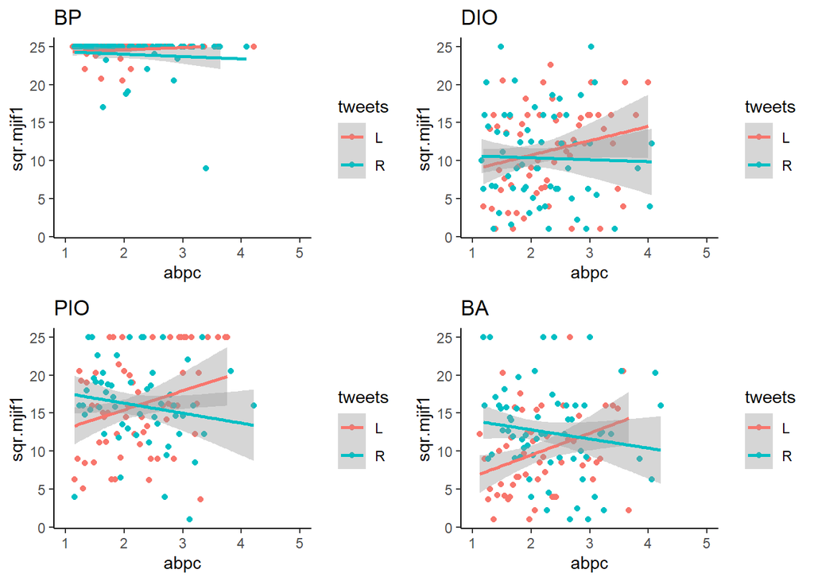

## Left of midpoint (ABPC < 2) w/ mji factor 1

- Full cases =516
- BA cases =131
- PIO cases =130
- DIO cases =124
- BP cases =131

### Full model

```
##
## Call:
## lm(formula = mc.sqr.mjif1 ~ PI * DI * tweets, data = subset(dat,
##     abpc < med.abpc))
##
## Residuals:
##      Min       1Q   Median       3Q      Max
## -15.4871  -4.5702   0.4281   3.0373  16.4298
##
## Coefficients:
##                 Estimate Std. Error t value Pr(>|t|)
## (Intercept)      -7.0240     0.8807  -7.975 1.02e-14 ***
## PI1               6.0567     1.2066   5.020 7.18e-07 ***
## DI1               1.6721     1.2066   1.386  0.16642
## tweetsR           5.1359     1.1719   4.383 1.42e-05 ***
## PI1:DI1           8.2729     1.6559   4.996 8.06e-07 ***
## PI1:tweetsR      -2.3359     1.6534  -1.413  0.15833
## DI1:tweetsR      -5.0223     1.6742  -3.000  0.00283 **
## PI1:DI1:tweetsR   2.1374     2.3519   0.909  0.36388
## ---
## Signif. codes:  0 '***' 0.001 '**' 0.01 '*' 0.05 '.' 0.1 ' ' 1
##
## Residual standard error: 6.65 on 508 degrees of freedom
## Multiple R-squared:  0.4352, Adjusted R-squared:  0.4274
## F-statistic: 55.91 on 7 and 508 DF,  p-value: < 2.2e-16
```

### Regression Coefficients

```
##
## Call:
## lm(formula = mc.sqr.mjif1 ~ PI * DI * tweets, data = subset(dat,
##     abpc < med.abpc))
##
## Standardized Coefficients::
##     (Intercept)             PI1             DI1         tweetsR         PI1:DI1
##              NA      0.34494258      0.09523091      0.29250997      0.41014630
##     PI1:tweetsR     DI1:tweetsR PI1:DI1:tweetsR
##     -0.11337599     -0.23955067      0.07690527
```

### BA

```
##
## Call:
## lm(formula = mc.sqr.mjif1 ~ tweets, data = subset(dat, Cond_int ==
##     "BA" & abpc < med.abpc))
##
## Residuals:
##      Min       1Q   Median       3Q      Max
## -12.7061  -6.3202   0.4298   3.6798  16.4298
##
## Coefficients:
##             Estimate Std. Error t value Pr(>|t|)
## (Intercept)  -7.0240     0.9785  -7.178 4.97e-11 ***
## tweetsR       5.1359     1.3020   3.945  0.00013 ***
## ---
## Signif. codes:  0 '***' 0.001 '**' 0.01 '*' 0.05 '.' 0.1 ' ' 1
##
## Residual standard error: 7.388 on 129 degrees of freedom
## Multiple R-squared:  0.1076, Adjusted R-squared:  0.1007
## F-statistic: 15.56 on 1 and 129 DF,  p-value: 0.0001304
```

### Regression Coefficients

```
##
## Call:
## lm(formula = mc.sqr.mjif1 ~ tweets, data = subset(dat, Cond_int ==
##     "BA" & abpc < med.abpc))
##
## Standardized Coefficients::
## (Intercept)     tweetsR
##          NA   0.3280907
```

### PIO

```
##
## Call:
## lm(formula = mc.sqr.mjif1 ~ tweets, data = subset(dat, Cond_int ==
##     "PIO" & abpc < med.abpc))
##
## Residuals:
##     Min      1Q  Median      3Q     Max
## -15.177  -8.377   1.373   7.573  10.373
##
## Coefficients:
##             Estimate Std. Error t value Pr(>|t|)
## (Intercept)  -0.9672     0.9950  -0.972   0.3328
## tweetsR       2.8000     1.4072   1.990   0.0487 *
## ---
## Signif. codes:  0 '***' 0.001 '**' 0.01 '*' 0.05 '.' 0.1 ' ' 1
##
## Residual standard error: 8.022 on 128 degrees of freedom
## Multiple R-squared:   0.03,  Adjusted R-squared:  0.02243
## F-statistic: 3.959 on 1 and 128 DF,  p-value: 0.04874
```

### Regression Coefficients

```
##
## Call:
## lm(formula = mc.sqr.mjif1 ~ tweets, data = subset(dat, Cond_int ==
##     "PIO" & abpc < med.abpc))
##
## Standardized Coefficients::
## (Intercept)     tweetsR
##          NA   0.1732184
```

### DIO

```
##
## Call:
## lm(formula = mc.sqr.mjif1 ~ tweets, data = subset(dat, Cond_int ==
##     "DIO" & abpc < med.abpc))
##
## Residuals:
##    Min     1Q Median     3Q    Max
## -9.356 -6.242 -1.356  5.644 14.758
##
## Coefficients:
##             Estimate Std. Error t value Pr(>|t|)
## (Intercept)  -5.3519     0.9098  -5.882 3.63e-08 ***
## tweetsR       0.1136     1.3190   0.086    0.931
## ---
## Signif. codes:  0 '***' 0.001 '**' 0.01 '*' 0.05 '.' 0.1 ' ' 1
##
## Residual standard error: 7.335 on 122 degrees of freedom
## Multiple R-squared:  6.083e-05,  Adjusted R-squared:  -0.008135
## F-statistic: 0.007421 on 1 and 122 DF,  p-value: 0.9315
```

### Regression Coefficients

```
##
## Call:
## lm(formula = mc.sqr.mjif1 ~ tweets, data = subset(dat, Cond_int ==
##     "DIO" & abpc < med.abpc))
##
## Standardized Coefficients::
## (Intercept)     tweetsR
##          NA 0.007799047
```

### BP

```
##
## Call:
## lm(formula = mc.sqr.mjif1 ~ tweets, data = subset(dat, Cond_int ==
##     "BP" & abpc < med.abpc))
##
## Residuals:
##      Min       1Q   Median       3Q      Max
## -15.4871   0.4281   0.4281   0.5129   0.5129
##
## Coefficients:
##             Estimate Std. Error t value Pr(>|t|)
## (Intercept)  8.97775    0.25651   35.00   <2e-16 ***
## tweetsR     -0.08485    0.38550   -0.22    0.826
## ---
## Signif. codes:  0 '***' 0.001 '**' 0.01 '*' 0.05 '.' 0.1 ' ' 1
##
## Residual standard error: 2.192 on 129 degrees of freedom
## Multiple R-squared:  0.0003754,  Adjusted R-squared:  -0.007374
## F-statistic: 0.04844 on 1 and 129 DF,  p-value: 0.8261
```

### Regression Coefficients

```
##
## Call:
## lm(formula = mc.sqr.mjif1 ~ tweets, data = subset(dat, Cond_int ==
##     "BP" & abpc < med.abpc))
##
## Standardized Coefficients::
## (Intercept)     tweetsR
##          NA  -0.0193751
```

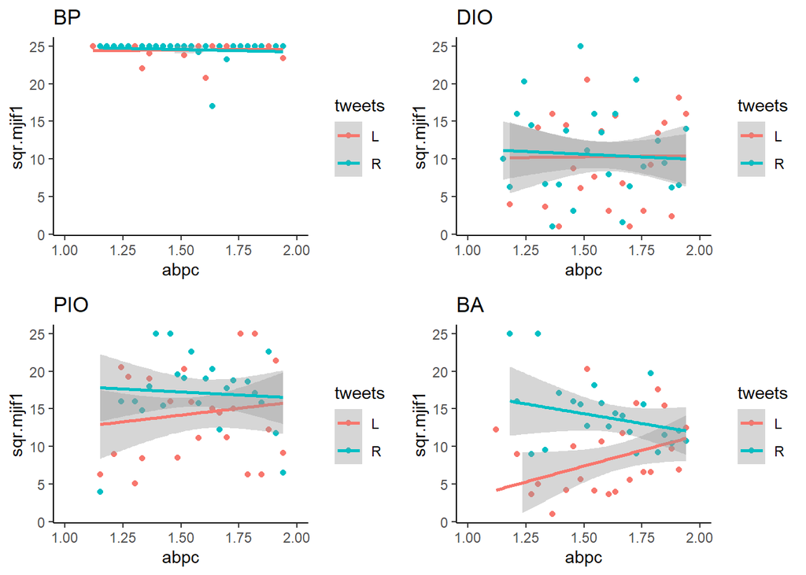

## RIGHT of midpoint (ABPC > 2) w/ mji factor 1

- Full cases =538
- BA cases =130
- PIO cases =137
- DIO cases =137
- BP cases =134

### Full model

```
##
## Call:
## lm(formula = mc.sqr.mjif1 ~ PI * DI * tweets, data = subset(dat,
##     abpc >= med.abpc))
##
## Residuals:
##      Min       1Q   Median       3Q      Max
## -15.5797  -4.7109   0.3792   4.1866  14.7992
##
## Coefficients:
##                 Estimate Std. Error t value Pr(>|t|)
## (Intercept)      -4.6332     0.8304  -5.580 3.85e-08 ***
## PI1               5.6188     1.1529   4.874 1.45e-06 ***
## DI1               0.6033     1.1489   0.525    0.600
## tweetsR           0.8525     1.1611   0.734    0.463
## PI1:DI1           7.4378     1.6417   4.531 7.27e-06 ***
## PI1:tweetsR      -2.4874     1.6238  -1.532    0.126
## DI1:tweetsR      -2.2160     1.6271  -1.362    0.174
## PI1:DI1:tweetsR   2.8246     2.2952   1.231    0.219
## ---
## Signif. codes:  0 '***' 0.001 '**' 0.01 '*' 0.05 '.' 0.1 ' ' 1
##
## Residual standard error: 6.643 on 530 degrees of freedom
## Multiple R-squared:  0.3924, Adjusted R-squared:  0.3844
## F-statistic: 48.91 on 7 and 530 DF,  p-value: < 2.2e-16
```

### Regression Coefficients

```
##
## Call:
## lm(formula = mc.sqr.mjif1 ~ PI * DI * tweets, data = subset(dat,
##     abpc >= med.abpc))
##
## Standardized Coefficients::
##     (Intercept)             PI1             DI1         tweetsR         PI1:DI1
##              NA      0.33210719      0.03566267      0.05037706      0.38026177
##     PI1:tweetsR     DI1:tweetsR PI1:DI1:tweetsR
##     -0.12960616     -0.11494139      0.11500979
```

### BA

```
##
## Call:
## lm(formula = mc.sqr.mjif1 ~ tweets, data = subset(dat, Cond_int ==
##     "BA" & abpc >= med.abpc))
##
## Residuals:
##      Min       1Q   Median       3Q      Max
## -10.6136  -6.5616   0.6364   5.0391  14.0391
##
## Coefficients:
##             Estimate Std. Error t value Pr(>|t|)
## (Intercept)  -4.6332     0.9017  -5.138 1.01e-06 ***
## tweetsR       0.6527     1.2655   0.516    0.607
## ---
## Signif. codes:  0 '***' 0.001 '**' 0.01 '*' 0.05 '.' 0.1 ' ' 1
##
## Residual standard error: 7.214 on 128 degrees of freedom
## Multiple R-squared:  0.002074,   Adjusted R-squared:  -0.005722
## F-statistic: 0.266 on 1 and 128 DF,  p-value: 0.6069
```

### Regression Coefficients

```
##
## Call:
## lm(formula = mc.sqr.mjif1 ~ tweets, data = subset(dat, Cond_int ==
##     "BA" & abpc >= med.abpc))
##
## Standardized Coefficients::
## (Intercept)     tweetsR
##          NA  0.04553959
```

### PIO

```
##
## Call:
## lm(formula = mc.sqr.mjif1 ~ tweets, data = subset(dat, Cond_int ==
##     "PIO" & abpc >= med.abpc))
##
## Residuals:
##      Min       1Q   Median       3Q      Max
## -15.5797  -5.9449  -0.5797   8.4203  10.0551
##
## Coefficients:
##             Estimate Std. Error t value Pr(>|t|)
## (Intercept)   0.9855     0.9460   1.042    0.299
## tweetsR      -1.6349     1.3427  -1.218    0.226
##
## Residual standard error: 7.858 on 135 degrees of freedom
## Multiple R-squared:  0.01086,    Adjusted R-squared:  0.003535
## F-statistic: 1.482 on 1 and 135 DF,  p-value: 0.2255
```

### Regression Coefficients

```
##
## Call:
## lm(formula = mc.sqr.mjif1 ~ tweets, data = subset(dat, Cond_int ==
##     "PIO" & abpc >= med.abpc))
##
## Standardized Coefficients::
## (Intercept)     tweetsR
##          NA  -0.1042214
```

### DIO

```
##
## Call:
## lm(formula = mc.sqr.mjif1 ~ tweets, data = subset(dat, Cond_int ==
##     "DIO" & abpc >= med.abpc))
##
## Residuals:
##     Min      1Q  Median      3Q     Max
## -10.564  -6.422  -1.422   5.578  14.578
##
## Coefficients:
##             Estimate Std. Error t value Pr(>|t|)
## (Intercept)  -4.0299     0.8762  -4.599 9.65e-06 ***
## tweetsR      -1.1426     1.2529  -0.912    0.363
## ---
## Signif. codes:  0 '***' 0.001 '**' 0.01 '*' 0.05 '.' 0.1 ' ' 1
##
## Residual standard error: 7.331 on 135 degrees of freedom
## Multiple R-squared:  0.006123,   Adjusted R-squared:  -0.001239
## F-statistic: 0.8317 on 1 and 135 DF,  p-value: 0.3634
```

### Regression Coefficients

```
##
## Call:
## lm(formula = mc.sqr.mjif1 ~ tweets, data = subset(dat, Cond_int ==
##     "DIO" & abpc >= med.abpc))
##
## Standardized Coefficients::
## (Intercept)     tweetsR
##          NA -0.07825013
```

### BP

```
##
## Call:
## lm(formula = mc.sqr.mjif1 ~ tweets, data = subset(dat, Cond_int ==
##     "BP" & abpc >= med.abpc))
##
## Residuals:
##      Min       1Q   Median       3Q      Max
## -14.5946   0.3792   0.3792   1.4054   1.4054
##
## Coefficients:
##             Estimate Std. Error t value Pr(>|t|)
## (Intercept)   9.0267     0.3855  23.415   <2e-16 ***
## tweetsR      -1.0262     0.5188  -1.978     0.05 *
## ---
## Signif. codes:  0 '***' 0.001 '**' 0.01 '*' 0.05 '.' 0.1 ' ' 1
##
## Residual standard error: 2.986 on 132 degrees of freedom
## Multiple R-squared:  0.02879,    Adjusted R-squared:  0.02144
## F-statistic: 3.913 on 1 and 132 DF,  p-value: 0.04998
```

### Regression Coefficients

```
##
## Call:
## lm(formula = mc.sqr.mjif1 ~ tweets, data = subset(dat, Cond_int ==
##     "BP" & abpc >= med.abpc))
##
## Standardized Coefficients::
## (Intercept)     tweetsR
##          NA  -0.1696877
```

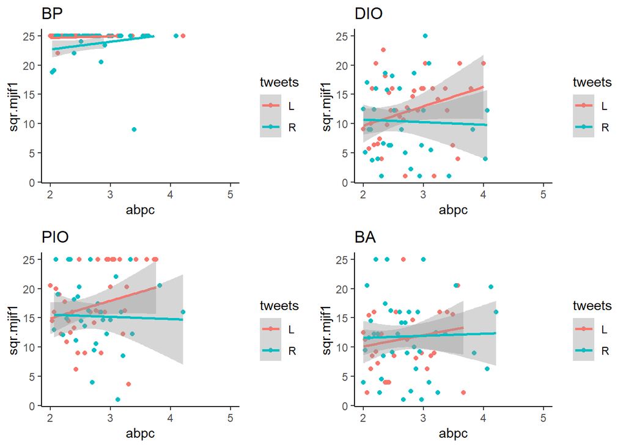

## Left of midpoint (ABPC < 2) w/ ABPC factor 1 (MI) w/ mji factor 1

### Full model

```
##
## Call:
## lm(formula = mc.sqr.mjif1 ~ PI * DI * tweets, data = subset(dat,
##     abpc.mi < med.abpc.mi))
##
## Residuals:
##      Min       1Q   Median       3Q      Max
## -15.4961  -4.5625   0.4375   3.7373  16.4375
##
## Coefficients:
##                 Estimate Std. Error t value Pr(>|t|)
## (Intercept)      -7.0317     0.9698  -7.251 1.66e-12 ***
## PI1               5.6375     1.2787   4.409 1.28e-05 ***
## DI1               1.5273     1.2829   1.191 0.234429
## tweetsR           4.6055     1.2829   3.590 0.000365 ***
## PI1:DI1           8.8325     1.7252   5.120 4.43e-07 ***
## PI1:tweetsR      -2.3094     1.7452  -1.323 0.186378
## DI1:tweetsR      -3.5512     1.7653  -2.012 0.044813 *
## PI1:DI1:tweetsR   1.4453     2.4440   0.591 0.554550
## ---
## Signif. codes:  0 '***' 0.001 '**' 0.01 '*' 0.05 '.' 0.1 ' ' 1
##
## Residual standard error: 6.719 on 482 degrees of freedom
## Multiple R-squared:  0.4291, Adjusted R-squared:  0.4208
## F-statistic: 51.75 on 7 and 482 DF,  p-value: < 2.2e-16
```

### Regression Coefficients

```
##
## Call:
## lm(formula = mc.sqr.mjif1 ~ PI * DI * tweets, data = subset(dat,
##     abpc.mi < med.abpc.mi))
##
## Standardized Coefficients::
##     (Intercept)             PI1             DI1         tweetsR         PI1:DI1
##              NA      0.31934020      0.08657809      0.26107807      0.43770690
##     PI1:tweetsR     DI1:tweetsR PI1:DI1:tweetsR
##     -0.11228401     -0.17013355      0.05173024
```

### BA

```
##
## Call:
## lm(formula = mc.sqr.mjif1 ~ tweets, data = subset(dat, Cond_int ==
##     "BA" & abpc.mi < med.abpc.mi))
##
## Residuals:
##      Min       1Q   Median       3Q      Max
## -12.1680  -6.9180   0.4375   3.6875  16.4375
##
## Coefficients:
##             Estimate Std. Error t value Pr(>|t|)
## (Intercept)   -7.032      1.062  -6.621 1.35e-09 ***
## tweetsR        4.605      1.405   3.278   0.0014 **
## ---
## Signif. codes:  0 '***' 0.001 '**' 0.01 '*' 0.05 '.' 0.1 ' ' 1
##
## Residual standard error: 7.357 on 110 degrees of freedom
## Multiple R-squared:  0.08901,    Adjusted R-squared:  0.08073
## F-statistic: 10.75 on 1 and 110 DF,  p-value: 0.001398
```

### Regression Coefficients

```
##
## Call:
## lm(formula = mc.sqr.mjif1 ~ tweets, data = subset(dat, Cond_int ==
##     "BA" & abpc.mi < med.abpc.mi))
##
## Standardized Coefficients::
## (Intercept)     tweetsR
##          NA   0.2983406
```

### PIO

```
##
## Call:
## lm(formula = mc.sqr.mjif1 ~ tweets, data = subset(dat, Cond_int ==
##     "PIO" & abpc.mi < med.abpc.mi))
##
## Residuals:
##     Min      1Q  Median      3Q     Max
## -15.496  -7.950   1.800   8.504  10.800
##
## Coefficients:
##             Estimate Std. Error t value Pr(>|t|)
## (Intercept)   -1.394      1.040  -1.340    0.183
## tweetsR        2.296      1.477   1.554    0.123
##
## Residual standard error: 8.388 on 127 degrees of freedom
## Multiple R-squared:  0.01867,    Adjusted R-squared:  0.01094
## F-statistic: 2.416 on 1 and 127 DF,  p-value: 0.1226
```

### Regression Coefficients

```
##
## Call:
## lm(formula = mc.sqr.mjif1 ~ tweets, data = subset(dat, Cond_int ==
##     "PIO" & abpc.mi < med.abpc.mi))
##
## Standardized Coefficients::
## (Intercept)     tweetsR
##          NA   0.1366429
```

### DIO

```
##
## Call:
## lm(formula = mc.sqr.mjif1 ~ tweets, data = subset(dat, Cond_int ==
##     "DIO" & abpc.mi < med.abpc.mi))
##
## Residuals:
##     Min      1Q  Median      3Q     Max
## -10.144  -6.090  -1.090   4.856  14.910
##
## Coefficients:
##             Estimate Std. Error t value Pr(>|t|)
## (Intercept)  -5.5043     0.9158  -6.011 2.01e-08 ***
## tweetsR       1.0542     1.3223   0.797    0.427
## ---
## Signif. codes:  0 '***' 0.001 '**' 0.01 '*' 0.05 '.' 0.1 ' ' 1
##
## Residual standard error: 7.326 on 121 degrees of freedom
## Multiple R-squared:  0.005226,   Adjusted R-squared:  -0.002995
## F-statistic: 0.6357 on 1 and 121 DF,  p-value: 0.4268
```

### Regression Coefficients

```
##
## Call:
## lm(formula = mc.sqr.mjif1 ~ tweets, data = subset(dat, Cond_int ==
##     "DIO" & abpc.mi < med.abpc.mi))
##
## Standardized Coefficients::
## (Intercept)     tweetsR
##          NA  0.07229085
```

### BP

```
##
## Call:
## lm(formula = mc.sqr.mjif1 ~ tweets, data = subset(dat, Cond_int ==
##     "BP" & abpc.mi < med.abpc.mi))
##
## Residuals:
##      Min       1Q   Median       3Q      Max
## -12.3099   0.2500   0.4401   0.4401   0.4401
##
## Coefficients:
##             Estimate Std. Error t value Pr(>|t|)
## (Intercept)   8.9657     0.2064  43.438   <2e-16 ***
## tweetsR       0.1901     0.3124   0.609    0.544
## ---
## Signif. codes:  0 '***' 0.001 '**' 0.01 '*' 0.05 '.' 0.1 ' ' 1
##
## Residual standard error: 1.739 on 124 degrees of freedom
## Multiple R-squared:  0.002979,   Adjusted R-squared:  -0.005062
## F-statistic: 0.3704 on 1 and 124 DF,  p-value: 0.5439
```

### Regression Coefficients

```
##
## Call:
## lm(formula = mc.sqr.mjif1 ~ tweets, data = subset(dat, Cond_int ==
##     "BP" & abpc.mi < med.abpc.mi))
##
## Standardized Coefficients::
## (Intercept)     tweetsR
##          NA  0.05457624
```

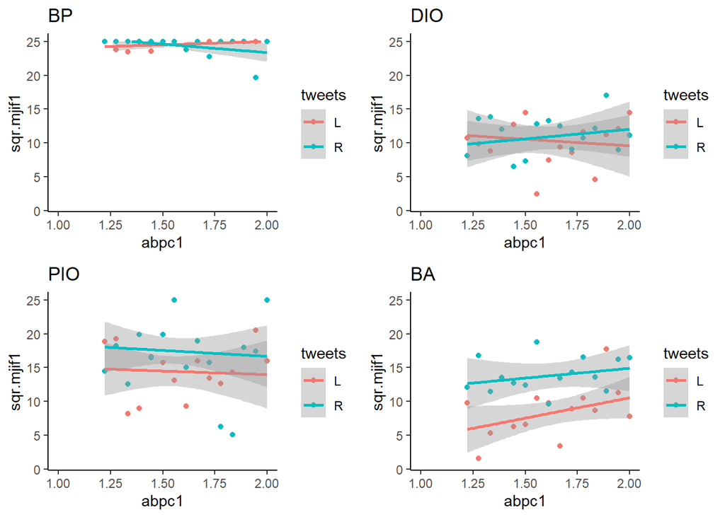

## RIGHT of midpoint (ABPC > 2) w/ ABPC factor 1 (MI) w/ mji factor 1

### Full model

```
##
## Call:
## lm(formula = mc.sqr.mjif1 ~ PI * DI * tweets, data = subset(dat,
##     abpc >= med.abpc.mi))
##
## Residuals:
##      Min       1Q   Median       3Q      Max
## -15.8022  -4.6613   0.3158   4.1367  14.9802
##
## Coefficients:
##                 Estimate Std. Error t value Pr(>|t|)
## (Intercept)      -4.6829     0.8387  -5.584 3.83e-08 ***
## PI1               5.8909     1.1637   5.062 5.80e-07 ***
## DI1               0.5887     1.1556   0.509    0.611
## tweetsR           0.9520     1.1768   0.809    0.419
## PI1:DI1           7.2933     1.6587   4.397 1.34e-05 ***
## PI1:tweetsR      -2.5535     1.6421  -1.555    0.121
## DI1:tweetsR      -2.4321     1.6459  -1.478    0.140
## PI1:DI1:tweetsR   2.8846     2.3238   1.241    0.215
## ---
## Signif. codes:  0 '***' 0.001 '**' 0.01 '*' 0.05 '.' 0.1 ' ' 1
##
## Residual standard error: 6.604 on 511 degrees of freedom
## Multiple R-squared:  0.3968, Adjusted R-squared:  0.3885
## F-statistic: 48.02 on 7 and 511 DF,  p-value: < 2.2e-16
```

### Regression Coefficients

```
##
## Call:
## lm(formula = mc.sqr.mjif1 ~ PI * DI * tweets, data = subset(dat,
##     abpc >= med.abpc.mi))
##
## Standardized Coefficients::
##     (Intercept)             PI1             DI1         tweetsR         PI1:DI1
##              NA      0.34911332      0.03488902      0.05640998      0.37262009
##     PI1:tweetsR     DI1:tweetsR PI1:DI1:tweetsR
##     -0.13340564     -0.12616072      0.11749236
```

### BA

```
##
## Call:
## lm(formula = mc.sqr.mjif1 ~ tweets, data = subset(dat, Cond_int ==
##     "BA" & abpc.mi >= med.abpc.mi))
##
## Residuals:
##      Min       1Q   Median       3Q      Max
## -11.3421  -6.6712  -0.0921   5.3288  14.3288
##
## Coefficients:
##             Estimate Std. Error t value Pr(>|t|)
## (Intercept)  -4.9229     0.8591  -5.730 5.48e-08 ***
## tweetsR       1.6709     1.2029   1.389    0.167
## ---
## Signif. codes:  0 '***' 0.001 '**' 0.01 '*' 0.05 '.' 0.1 ' ' 1
##
## Residual standard error: 7.34 on 147 degrees of freedom
## Multiple R-squared:  0.01296,    Adjusted R-squared:  0.006241
## F-statistic: 1.929 on 1 and 147 DF,  p-value: 0.1669
```

### Regression Coefficients

```
##
## Call:
## lm(formula = mc.sqr.mjif1 ~ tweets, data = subset(dat, Cond_int ==
##     "BA" & abpc.mi >= med.abpc.mi))
##
## Standardized Coefficients::
## (Intercept)     tweetsR
##          NA   0.1138235
```

### PIO

```
##
## Call:
## lm(formula = mc.sqr.mjif1 ~ tweets, data = subset(dat, Cond_int ==
##     "PIO" & abpc.mi >= med.abpc.mi))
##
## Residuals:
##      Min       1Q   Median       3Q      Max
## -15.9819  -4.7319   0.1558   8.0181   9.1558
##
## Coefficients:
##             Estimate Std. Error t value Pr(>|t|)
## (Intercept)   1.3877     0.9056   1.532    0.128
## tweetsR      -1.1377     1.2808  -0.888    0.376
##
## Residual standard error: 7.523 on 136 degrees of freedom
## Multiple R-squared:  0.005768,   Adjusted R-squared:  -0.001542
## F-statistic: 0.789 on 1 and 136 DF,  p-value: 0.376
```

### Regression Coefficients

```
##
## Call:
## lm(formula = mc.sqr.mjif1 ~ tweets, data = subset(dat, Cond_int ==
##     "PIO" & abpc.mi >= med.abpc.mi))
##
## Standardized Coefficients::
## (Intercept)     tweetsR
##          NA -0.07594965
```

### DIO

```
##
## Call:
## lm(formula = mc.sqr.mjif1 ~ tweets, data = subset(dat, Cond_int ==
##     "DIO" & abpc.mi >= med.abpc.mi))
##
## Residuals:
##      Min       1Q   Median       3Q      Max
## -10.6831  -5.7276  -0.7276   5.7835  15.2724
##
## Coefficients:
##             Estimate Std. Error t value Pr(>|t|)
## (Intercept)  -3.9111     0.8656  -4.518 1.34e-05 ***
## tweetsR      -1.9555     1.2423  -1.574    0.118
## ---
## Signif. codes:  0 '***' 0.001 '**' 0.01 '*' 0.05 '.' 0.1 ' ' 1
##
## Residual standard error: 7.294 on 136 degrees of freedom
## Multiple R-squared:  0.01789,    Adjusted R-squared:  0.01067
## F-statistic: 2.478 on 1 and 136 DF,  p-value: 0.1178
```

### Regression Coefficients

```
##
## Call:
## lm(formula = mc.sqr.mjif1 ~ tweets, data = subset(dat, Cond_int ==
##     "DIO" & abpc.mi >= med.abpc.mi))
##
## Standardized Coefficients::
## (Intercept)     tweetsR
##          NA  -0.1337629
```

### BP

```
##
## Call:
## lm(formula = mc.sqr.mjif1 ~ tweets, data = subset(dat, Cond_int ==
##     "BP" & abpc.mi >= med.abpc.mi))
##
## Residuals:
##      Min       1Q   Median       3Q      Max
## -14.4416   0.3669   0.3669   1.5584   1.5584
##
## Coefficients:
##             Estimate Std. Error t value Pr(>|t|)
## (Intercept)   9.0389     0.4049   22.32   <2e-16 ***
## tweetsR      -1.1915     0.5440   -2.19   0.0302 *
## ---
## Signif. codes:  0 '***' 0.001 '**' 0.01 '*' 0.05 '.' 0.1 ' ' 1
##
## Residual standard error: 3.188 on 137 degrees of freedom
## Multiple R-squared:  0.03383,    Adjusted R-squared:  0.02678
## F-statistic: 4.797 on 1 and 137 DF,  p-value: 0.0302
```

### Regression Coefficients

```
##
## Call:
## lm(formula = mc.sqr.mjif1 ~ tweets, data = subset(dat, Cond_int ==
##     "BP" & abpc.mi >= med.abpc.mi))
##
## Standardized Coefficients::
## (Intercept)     tweetsR
##          NA  -0.1839358
```

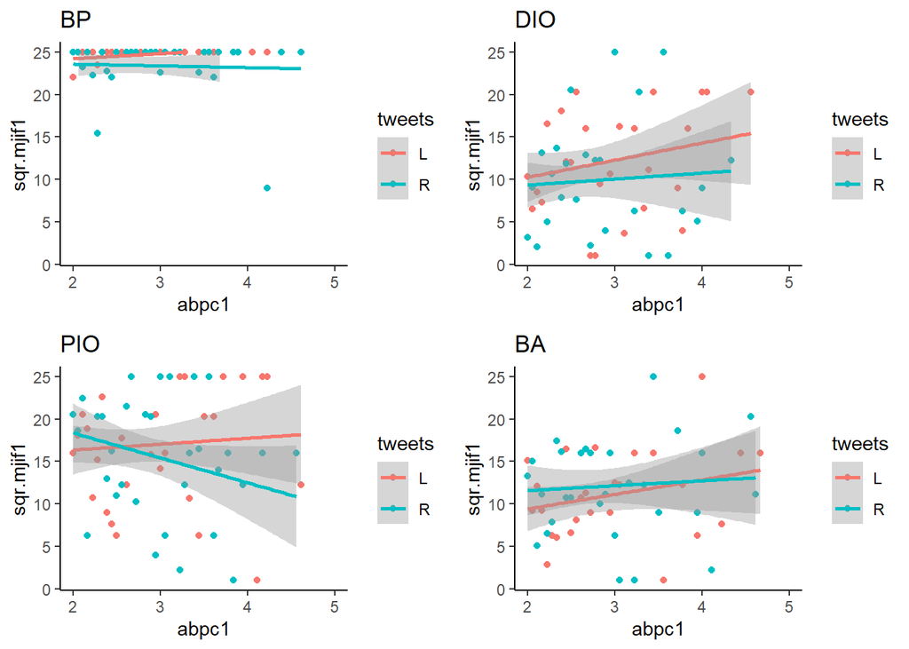

## Left of midpoint (ABPC < 2) w/ ABPC factor 2 (RT) w/ mji factor 1

### Full model

```
##
## Call:
## lm(formula = mc.sqr.mjif1 ~ PI * DI * tweets, data = subset(dat,
##     abpc.rt < med.abpc.rt))
##
## Residuals:
##      Min       1Q   Median       3Q      Max
## -16.5231  -5.2731   0.5729   2.9693  15.7193
##
## Coefficients:
##                 Estimate Std. Error t value Pr(>|t|)
## (Intercept)      -6.3135     0.8810  -7.166 2.83e-12 ***
## PI1               5.3329     1.2572   4.242 2.65e-05 ***
## DI1               0.8661     1.2159   0.712 0.476605
## tweetsR           4.3574     1.1986   3.635 0.000307 ***
## PI1:DI1           8.9473     1.7022   5.256 2.19e-07 ***
## PI1:tweetsR      -1.4479     1.7093  -0.847 0.397354
## DI1:tweetsR      -4.0834     1.6959  -2.408 0.016419 *
## PI1:DI1:tweetsR   0.4726     2.3852   0.198 0.843010
## ---
## Signif. codes:  0 '***' 0.001 '**' 0.01 '*' 0.05 '.' 0.1 ' ' 1
##
## Residual standard error: 6.652 on 493 degrees of freedom
## Multiple R-squared:  0.4232, Adjusted R-squared:  0.4151
## F-statistic: 51.68 on 7 and 493 DF,  p-value: < 2.2e-16
```

### Regression Coefficients

```
##
## Call:
## lm(formula = mc.sqr.mjif1 ~ PI * DI * tweets, data = subset(dat,
##     abpc.rt < med.abpc.rt))
##
## Standardized Coefficients::
##     (Intercept)             PI1             DI1         tweetsR         PI1:DI1
##              NA      0.30687482      0.04982772      0.25073689      0.45583558
##     PI1:tweetsR     DI1:tweetsR PI1:DI1:tweetsR
##     -0.07249551     -0.20171853      0.01791354
```

### BA

```
##
## Call:
## lm(formula = mc.sqr.mjif1 ~ tweets, data = subset(dat, Cond_int ==
##     "BA" & abpc.rt < med.abpc.rt))
##
## Residuals:
##      Min       1Q   Median       3Q      Max
## -12.6381  -5.2807  -0.2807   6.6119  15.7193
##
## Coefficients:
##             Estimate Std. Error t value Pr(>|t|)
## (Intercept)  -6.3135     0.9784  -6.453 2.33e-09 ***
## tweetsR       4.3574     1.3311   3.274  0.00138 **
## ---
## Signif. codes:  0 '***' 0.001 '**' 0.01 '*' 0.05 '.' 0.1 ' ' 1
##
## Residual standard error: 7.387 on 122 degrees of freedom
## Multiple R-squared:  0.08075,    Adjusted R-squared:  0.07321
## F-statistic: 10.72 on 1 and 122 DF,  p-value: 0.001382
```

### Regression Coefficients

```
##
## Call:
## lm(formula = mc.sqr.mjif1 ~ tweets, data = subset(dat, Cond_int ==
##     "BA" & abpc.rt < med.abpc.rt))
##
## Standardized Coefficients::
## (Intercept)     tweetsR
##          NA   0.2841582
```

### PIO

```
##
## Call:
## lm(formula = mc.sqr.mjif1 ~ tweets, data = subset(dat, Cond_int ==
##     "PIO" & abpc.rt < med.abpc.rt))
##
## Residuals:
##     Min      1Q  Median      3Q     Max
## -16.523  -6.301   1.386   7.477  10.386
##
## Coefficients:
##             Estimate Std. Error t value Pr(>|t|)
## (Intercept)  -0.9805     1.0806  -0.907   0.3661
## tweetsR       2.9094     1.4683   1.982   0.0499 *
## ---
## Signif. codes:  0 '***' 0.001 '**' 0.01 '*' 0.05 '.' 0.1 ' ' 1
##
## Residual standard error: 8.014 on 118 degrees of freedom
## Multiple R-squared:  0.0322, Adjusted R-squared:  0.024
## F-statistic: 3.926 on 1 and 118 DF,  p-value: 0.04986
```

### Regression Coefficients

```
##
## Call:
## lm(formula = mc.sqr.mjif1 ~ tweets, data = subset(dat, Cond_int ==
##     "PIO" & abpc.rt < med.abpc.rt))
##
## Standardized Coefficients::
## (Intercept)     tweetsR
##          NA   0.1794534
```

### DIO

```
##
## Call:
## lm(formula = mc.sqr.mjif1 ~ tweets, data = subset(dat, Cond_int ==
##     "DIO" & abpc.rt < med.abpc.rt))
##
## Residuals:
##    Min     1Q Median     3Q    Max
## -9.421 -6.147 -1.421  5.579 14.853
##
## Coefficients:
##             Estimate Std. Error t value Pr(>|t|)
## (Intercept)   -5.447      0.929  -5.863 4.02e-08 ***
## tweetsR        0.274      1.330   0.206    0.837
## ---
## Signif. codes:  0 '***' 0.001 '**' 0.01 '*' 0.05 '.' 0.1 ' ' 1
##
## Residual standard error: 7.374 on 121 degrees of freedom
## Multiple R-squared:  0.0003506,  Adjusted R-squared:  -0.007911
## F-statistic: 0.04243 on 1 and 121 DF,  p-value: 0.8371
```

### Regression Coefficients

```
##
## Call:
## lm(formula = mc.sqr.mjif1 ~ tweets, data = subset(dat, Cond_int ==
##     "DIO" & abpc.rt < med.abpc.rt))
##
## Standardized Coefficients::
## (Intercept)     tweetsR
##          NA  0.01872352
```

### BP

```
##
## Call:
## lm(formula = mc.sqr.mjif1 ~ tweets, data = subset(dat, Cond_int ==
##     "BP" & abpc.rt < med.abpc.rt))
##
## Residuals:
##      Min       1Q   Median       3Q      Max
## -14.7258   0.5729   0.5729   1.2742   1.2742
##
## Coefficients:
##             Estimate Std. Error t value Pr(>|t|)
## (Intercept)   8.8329     0.3238  27.276   <2e-16 ***
## tweetsR      -0.7013     0.4761  -1.473    0.143
## ---
## Signif. codes:  0 '***' 0.001 '**' 0.01 '*' 0.05 '.' 0.1 ' ' 1
##
## Residual standard error: 2.748 on 132 degrees of freedom
## Multiple R-squared:  0.01617,    Adjusted R-squared:  0.008719
## F-statistic:  2.17 on 1 and 132 DF,  p-value: 0.1431
```

### Regression Coefficients

```
##
## Call:
## lm(formula = mc.sqr.mjif1 ~ tweets, data = subset(dat, Cond_int ==
##     "BP" & abpc.rt < med.abpc.rt))
##
## Standardized Coefficients::
## (Intercept)     tweetsR
##          NA  -0.1271712
```

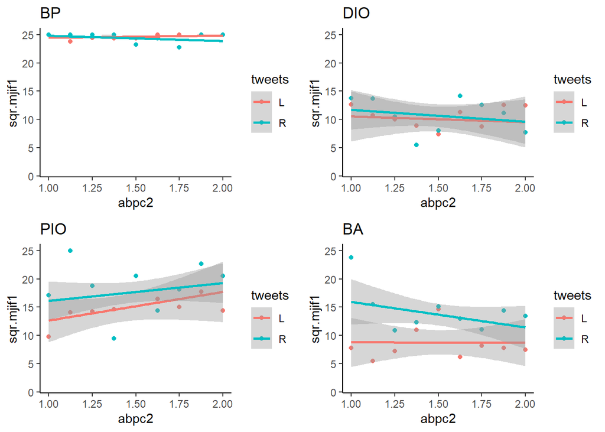

## RIGHT of midpoint (ABPC > 2) w/ ABPC factor 2 (RT) w/ mji factor 1

- Full cases =553
- BA cases =137
- PIO cases =147
- DIO cases =138
- BP cases =131

### Full model

```
##
## Call:
## lm(formula = mc.sqr.mjif1 ~ PI * DI * tweets, data = subset(dat,
##     abpc.rt >= med.abpc.rt))
##
## Residuals:
##     Min      1Q  Median      3Q     Max
## -15.342  -4.092   0.209   3.946  14.861
##
## Coefficients:
##                 Estimate Std. Error t value Pr(>|t|)
## (Intercept)      -5.2660     0.8332  -6.320 5.43e-10 ***
## PI1               6.0136     1.1210   5.365 1.20e-07 ***
## DI1               1.2830     1.1451   1.120   0.2630
## tweetsR           1.7259     1.1378   1.517   0.1299
## PI1:DI1           7.1662     1.6131   4.443 1.08e-05 ***
## PI1:tweetsR      -3.2148     1.5844  -2.029   0.0429 *
## DI1:tweetsR      -3.1986     1.6109  -1.986   0.0476 *
## PI1:DI1:tweetsR   4.1143     2.2746   1.809   0.0710 .
## ---
## Signif. codes:  0 '***' 0.001 '**' 0.01 '*' 0.05 '.' 0.1 ' ' 1
##
## Residual standard error: 6.665 on 545 degrees of freedom
## Multiple R-squared:  0.4011, Adjusted R-squared:  0.3934
## F-statistic: 52.15 on 7 and 545 DF,  p-value: < 2.2e-16
```

### Regression Coefficients

```
##
## Call:
## lm(formula = mc.sqr.mjif1 ~ PI * DI * tweets, data = subset(dat,
##     abpc.rt >= med.abpc.rt))
##
## Standardized Coefficients::
##     (Intercept)             PI1             DI1         tweetsR         PI1:DI1
##              NA      0.35164602      0.07498783      0.10092445      0.35633736
##     PI1:tweetsR     DI1:tweetsR PI1:DI1:tweetsR
##     -0.16270136     -0.16069082      0.15999108
```

### BA

```
##
## Call:
## lm(formula = mc.sqr.mjif1 ~ tweets, data = subset(dat, Cond_int ==
##     "BA" & abpc.rt >= med.abpc.rt))
##
## Residuals:
##      Min       1Q   Median       3Q      Max
## -10.8767  -6.3281   0.3733   4.1233  14.6719
##
## Coefficients:
##             Estimate Std. Error t value Pr(>|t|)
## (Intercept)  -5.2660     0.9146  -5.757 5.49e-08 ***
## tweetsR       1.5486     1.2530   1.236    0.219
## ---
## Signif. codes:  0 '***' 0.001 '**' 0.01 '*' 0.05 '.' 0.1 ' ' 1
##
## Residual standard error: 7.317 on 135 degrees of freedom
## Multiple R-squared:  0.01119,    Adjusted R-squared:  0.003863
## F-statistic: 1.527 on 1 and 135 DF,  p-value: 0.2186
```

### Regression Coefficients

```
##
## Call:
## lm(formula = mc.sqr.mjif1 ~ tweets, data = subset(dat, Cond_int ==
##     "BA" & abpc.rt >= med.abpc.rt))
##
## Standardized Coefficients::
## (Intercept)     tweetsR
##          NA    0.105773
```

### PIO

```
##
## Call:
## lm(formula = mc.sqr.mjif1 ~ tweets, data = subset(dat, Cond_int ==
##     "PIO" & abpc.rt >= med.abpc.rt))
##
## Residuals:
##      Min       1Q   Median       3Q      Max
## -15.3418  -7.3418  -0.3418   8.6582  10.1471
##
## Coefficients:
##             Estimate Std. Error t value Pr(>|t|)
## (Intercept)   0.7476     0.8860   0.844    0.400
## tweetsR      -1.4888     1.3027  -1.143    0.255
##
## Residual standard error: 7.875 on 145 degrees of freedom
## Multiple R-squared:  0.008927,   Adjusted R-squared:  0.002092
## F-statistic: 1.306 on 1 and 145 DF,  p-value: 0.255
```

### Regression Coefficients

```
##
## Call:
## lm(formula = mc.sqr.mjif1 ~ tweets, data = subset(dat, Cond_int ==
##     "PIO" & abpc.rt >= med.abpc.rt))
##
## Standardized Coefficients::
## (Intercept)     tweetsR
##          NA -0.09448437
```

### DIO

```
##
## Call:
## lm(formula = mc.sqr.mjif1 ~ tweets, data = subset(dat, Cond_int ==
##     "DIO" & abpc.rt >= med.abpc.rt))
##
## Residuals:
##      Min       1Q   Median       3Q      Max
## -10.6111  -6.3636   0.6389   5.6364  14.6364
##
## Coefficients:
##             Estimate Std. Error t value Pr(>|t|)
## (Intercept)  -3.9831     0.8591  -4.636 8.22e-06 ***
## tweetsR      -1.2475     1.2422  -1.004    0.317
## ---
## Signif. codes:  0 '***' 0.001 '**' 0.01 '*' 0.05 '.' 0.1 ' ' 1
##
## Residual standard error: 7.29 on 136 degrees of freedom
## Multiple R-squared:  0.007361,   Adjusted R-squared:  6.183e-05
## F-statistic: 1.008 on 1 and 136 DF,  p-value: 0.3171
```

### Regression Coefficients

```
##
## Call:
## lm(formula = mc.sqr.mjif1 ~ tweets, data = subset(dat, Cond_int ==
##     "DIO" & abpc.rt >= med.abpc.rt))
##
## Standardized Coefficients::
## (Intercept)     tweetsR
##          NA -0.08579424
```

### BP

```
##
## Call:
## lm(formula = mc.sqr.mjif1 ~ tweets, data = subset(dat, Cond_int ==
##     "BP" & abpc.rt >= med.abpc.rt))
##
## Residuals:
##      Min       1Q   Median       3Q      Max
## -15.2179   0.2090   0.2090   0.7821   0.7821
##
## Coefficients:
##             Estimate Std. Error t value Pr(>|t|)
## (Intercept)   9.1968     0.3216  28.601   <2e-16 ***
## tweetsR      -0.5731     0.4399  -1.303    0.195
## ---
## Signif. codes:  0 '***' 0.001 '**' 0.01 '*' 0.05 '.' 0.1 ' ' 1
##
## Residual standard error: 2.511 on 129 degrees of freedom
## Multiple R-squared:  0.01299,    Adjusted R-squared:  0.005337
## F-statistic: 1.698 on 1 and 129 DF,  p-value: 0.1949
```

### Regression Coefficients

```
##
## Call:
## lm(formula = mc.sqr.mjif1 ~ tweets, data = subset(dat, Cond_int ==
##     "BP" & abpc.rt >= med.abpc.rt))
##
## Standardized Coefficients::
## (Intercept)     tweetsR
##          NA  -0.1139658
```

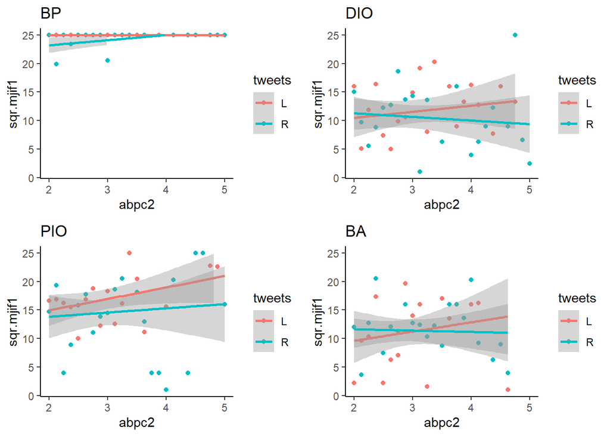

## Left of midpoint (ABPC < 2) w/ ABPC factor 3 (ES) w/ mji factor 1

- Full cases =439
- BA cases =107
- PIO cases =106
- DIO cases =115
- BP cases =111

### Full model

```
##
## Call:
## lm(formula = mc.sqr.mjif1 ~ PI * DI * tweets, data = subset(dat,
##     abpc.es < med.abpc.es))
##
## Residuals:
##      Min       1Q   Median       3Q      Max
## -14.9670  -4.7995   0.4569   2.4107  17.7447
##
## Coefficients:
##                 Estimate Std. Error t value Pr(>|t|)
## (Intercept)      -8.3388     0.9617  -8.671  < 2e-16 ***
## PI1               6.3384     1.3043   4.860 1.65e-06 ***
## DI1               2.5840     1.3043   1.981 0.048215 *
## tweetsR           7.2072     1.2843   5.612 3.59e-08 ***
## PI1:DI1           8.3654     1.7964   4.657 4.28e-06 ***
## PI1:tweetsR      -5.1559     1.8153  -2.840 0.004720 **
## DI1:tweetsR      -6.4617     1.7784  -3.634 0.000313 ***
## PI1:DI1:tweetsR   3.8343     2.5255   1.518 0.129680
## ---
## Signif. codes:  0 '***' 0.001 '**' 0.01 '*' 0.05 '.' 0.1 ' ' 1
##
## Residual standard error: 6.593 on 431 degrees of freedom
## Multiple R-squared:  0.4471, Adjusted R-squared:  0.4381
## F-statistic: 49.79 on 7 and 431 DF,  p-value: < 2.2e-16
```

### Regression Coefficients

```
##
## Call:
## lm(formula = mc.sqr.mjif1 ~ PI * DI * tweets, data = subset(dat,
##     abpc.es < med.abpc.es))
##
## Standardized Coefficients::
##     (Intercept)             PI1             DI1         tweetsR         PI1:DI1
##              NA       0.3606965       0.1469890       0.4101338       0.4138455
##     PI1:tweetsR     DI1:tweetsR PI1:DI1:tweetsR
##      -0.2486847      -0.3206158       0.1421926
```

### BA

```
##
## Call:
## lm(formula = mc.sqr.mjif1 ~ tweets, data = subset(dat, Cond_int ==
##     "BA" & abpc.es < med.abpc.es))
##
## Residuals:
##     Min      1Q  Median      3Q     Max
## -13.463  -5.463  -1.005   4.995  17.745
##
## Coefficients:
##             Estimate Std. Error t value Pr(>|t|)
## (Intercept)   -8.339      1.012  -8.240 5.18e-13 ***
## tweetsR        7.207      1.351   5.333 5.58e-07 ***
## ---
## Signif. codes:  0 '***' 0.001 '**' 0.01 '*' 0.05 '.' 0.1 ' ' 1
##
## Residual standard error: 6.938 on 105 degrees of freedom
## Multiple R-squared:  0.2132, Adjusted R-squared:  0.2057
## F-statistic: 28.44 on 1 and 105 DF,  p-value: 5.576e-07
```

### Regression Coefficients

```
##
## Call:
## lm(formula = mc.sqr.mjif1 ~ tweets, data = subset(dat, Cond_int ==
##     "BA" & abpc.es < med.abpc.es))
##
## Standardized Coefficients::
## (Intercept)     tweetsR
##          NA   0.4616847
```

### PIO

```
##
## Call:
## lm(formula = mc.sqr.mjif1 ~ tweets, data = subset(dat, Cond_int ==
##     "PIO" & abpc.es < med.abpc.es))
##
## Residuals:
##     Min      1Q  Median      3Q     Max
## -14.645  -7.344   0.355   6.656  11.406
##
## Coefficients:
##             Estimate Std. Error t value Pr(>|t|)
## (Intercept)   -2.000      1.056  -1.893   0.0611 .
## tweetsR        2.051      1.538   1.334   0.1853
## ---
## Signif. codes:  0 '***' 0.001 '**' 0.01 '*' 0.05 '.' 0.1 ' ' 1
##
## Residual standard error: 7.906 on 104 degrees of freedom
## Multiple R-squared:  0.01681,    Adjusted R-squared:  0.007357
## F-statistic: 1.778 on 1 and 104 DF,  p-value: 0.1853
```

### Regression Coefficients

```
##
## Call:
## lm(formula = mc.sqr.mjif1 ~ tweets, data = subset(dat, Cond_int ==
##     "PIO" & abpc.es < med.abpc.es))
##
## Standardized Coefficients::
## (Intercept)     tweetsR
##          NA   0.1296568
```

### DIO

```
##
## Call:
## lm(formula = mc.sqr.mjif1 ~ tweets, data = subset(dat, Cond_int ==
##     "DIO" & abpc.es < med.abpc.es))
##
## Residuals:
##    Min     1Q Median     3Q    Max
## -9.585 -6.212 -1.585  5.788 15.161
##
## Coefficients:
##             Estimate Std. Error t value Pr(>|t|)
## (Intercept)  -5.7549     0.9969  -5.773 6.95e-08 ***
## tweetsR       0.7455     1.3918   0.536    0.593
## ---
## Signif. codes:  0 '***' 0.001 '**' 0.01 '*' 0.05 '.' 0.1 ' ' 1
##
## Residual standard error: 7.46 on 113 degrees of freedom
## Multiple R-squared:  0.002532,   Adjusted R-squared:  -0.006295
## F-statistic: 0.2869 on 1 and 113 DF,  p-value: 0.5933
```

### Regression Coefficients

```
##
## Call:
## lm(formula = mc.sqr.mjif1 ~ tweets, data = subset(dat, Cond_int ==
##     "DIO" & abpc.es < med.abpc.es))
##
## Standardized Coefficients::
## (Intercept)     tweetsR
##          NA  0.05032354
```

### BP

```
##
## Call:
## lm(formula = mc.sqr.mjif1 ~ tweets, data = subset(dat, Cond_int ==
##     "BP" & abpc.es < med.abpc.es))
##
## Residuals:
##      Min       1Q   Median       3Q      Max
## -14.9670   0.4569   0.4569   1.0330   1.0330
##
## Coefficients:
##             Estimate Std. Error t value Pr(>|t|)
## (Intercept)   8.9489     0.3761  23.797   <2e-16 ***
## tweetsR      -0.5761     0.5442  -1.059    0.292
## ---
## Signif. codes:  0 '***' 0.001 '**' 0.01 '*' 0.05 '.' 0.1 ' ' 1
##
## Residual standard error: 2.864 on 109 degrees of freedom
## Multiple R-squared:  0.01018,    Adjusted R-squared:  0.001096
## F-statistic: 1.121 on 1 and 109 DF,  p-value: 0.2921
```

### Regression Coefficients

```
##
## Call:
## lm(formula = mc.sqr.mjif1 ~ tweets, data = subset(dat, Cond_int ==
##     "BP" & abpc.es < med.abpc.es))
##
## Standardized Coefficients::
## (Intercept)     tweetsR
##          NA  -0.1008811
```

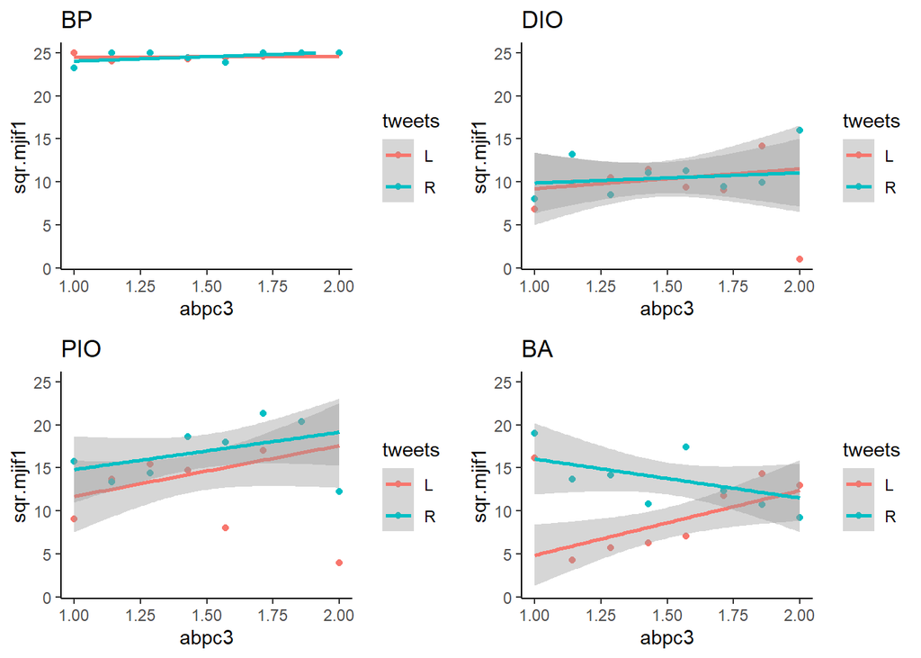

## RIGHT of midpoint (ABPC > 2) w/ ABPC factor 3 (ES) w/ mji factor 1

- Full cases =615
- BA cases =154
- PIO cases =161
- DIO cases =146
- BP cases =154

### Full model

```
##
## Call:
## lm(formula = mc.sqr.mjif1 ~ PI * DI * tweets, data = subset(dat,
##     abpc.es >= med.abpc.es))
##
## Residuals:
##      Min       1Q   Median       3Q      Max
## -16.0962  -4.3001   0.3667   4.4198  15.0038
##
## Coefficients:
##                 Estimate Std. Error t value Pr(>|t|)
## (Intercept)      -4.1212     0.7679  -5.367 1.14e-07 ***
## PI1               5.6232     1.0720   5.246 2.16e-07 ***
## DI1               0.2264     1.0687   0.212    0.832
## tweetsR           0.1073     1.0623   0.101    0.920
## PI1:DI1           7.3108     1.5111   4.838 1.66e-06 ***
## PI1:tweetsR      -0.7366     1.4878  -0.495    0.621
## DI1:tweetsR      -1.8104     1.5303  -1.183    0.237
## PI1:DI1:tweetsR   1.8064     2.1357   0.846    0.398
## ---
## Signif. codes:  0 '***' 0.001 '**' 0.01 '*' 0.05 '.' 0.1 ' ' 1
##
## Residual standard error: 6.606 on 607 degrees of freedom
## Multiple R-squared:  0.4005, Adjusted R-squared:  0.3936
## F-statistic: 57.93 on 7 and 607 DF,  p-value: < 2.2e-16
```

### Regression Coefficients

```
##
## Call:
## lm(formula = mc.sqr.mjif1 ~ PI * DI * tweets, data = subset(dat,
##     abpc.es >= med.abpc.es))
##
## Standardized Coefficients::
##     (Intercept)             PI1             DI1         tweetsR         PI1:DI1
##              NA     0.331611513     0.013349835     0.006327991     0.373685719
##     PI1:tweetsR     DI1:tweetsR PI1:DI1:tweetsR
##    -0.038277765    -0.090666333     0.071307822
```

### BA

```
##
## Call:
## lm(formula = mc.sqr.mjif1 ~ tweets, data = subset(dat, Cond_int ==
##     "BA" & abpc.es >= med.abpc.es))
##
## Residuals:
##     Min      1Q  Median      3Q     Max
## -10.473  -7.412   0.777   4.588  13.588
##
## Coefficients:
##             Estimate Std. Error t value Pr(>|t|)
## (Intercept) -4.12119    0.85084  -4.844 3.11e-06 ***
## tweetsR     -0.06047    1.18050  -0.051    0.959
## ---
## Signif. codes:  0 '***' 0.001 '**' 0.01 '*' 0.05 '.' 0.1 ' ' 1
##
## Residual standard error: 7.319 on 152 degrees of freedom
## Multiple R-squared:  1.726e-05,  Adjusted R-squared:  -0.006562
## F-statistic: 0.002624 on 1 and 152 DF,  p-value: 0.9592
```

### Regression Coefficients

```
##
## Call:
## lm(formula = mc.sqr.mjif1 ~ tweets, data = subset(dat, Cond_int ==
##     "BA" & abpc.es >= med.abpc.es))
##
## Standardized Coefficients::
##  (Intercept)      tweetsR
##           NA -0.004154993
```

### PIO

```
##
## Call:
## lm(formula = mc.sqr.mjif1 ~ tweets, data = subset(dat, Cond_int ==
##     "PIO" & abpc.es >= med.abpc.es))
##
## Residuals:
##      Min       1Q   Median       3Q      Max
## -16.0962  -4.8462  -0.4669   7.9038   8.5331
##
## Coefficients:
##             Estimate Std. Error t value Pr(>|t|)
## (Intercept)   1.5020     0.8972   1.674   0.0961 .
## tweetsR      -0.6293     1.2496  -0.504   0.6153
## ---
## Signif. codes:  0 '***' 0.001 '**' 0.01 '*' 0.05 '.' 0.1 ' ' 1
##
## Residual standard error: 7.924 on 159 degrees of freedom
## Multiple R-squared:  0.001592,   Adjusted R-squared:  -0.004687
## F-statistic: 0.2536 on 1 and 159 DF,  p-value: 0.6153
```

### Regression Coefficients

```
##
## Call:
## lm(formula = mc.sqr.mjif1 ~ tweets, data = subset(dat, Cond_int ==
##     "PIO" & abpc.es >= med.abpc.es))
##
## Standardized Coefficients::
## (Intercept)     tweetsR
##          NA -0.03990464
```

### DIO

```
##
## Call:
## lm(formula = mc.sqr.mjif1 ~ tweets, data = subset(dat, Cond_int ==
##     "DIO" & abpc.es >= med.abpc.es))
##
## Residuals:
##      Min       1Q   Median       3Q      Max
## -10.6994  -6.2201  -0.3348   5.7799  14.7799
##
## Coefficients:
##             Estimate Std. Error t value Pr(>|t|)
## (Intercept)  -3.8948     0.8105  -4.806 3.83e-06 ***
## tweetsR      -1.4792     1.1964  -1.236    0.218
## ---
## Signif. codes:  0 '***' 0.001 '**' 0.01 '*' 0.05 '.' 0.1 ' ' 1
##
## Residual standard error: 7.203 on 144 degrees of freedom
## Multiple R-squared:  0.0105, Adjusted R-squared:  0.003633
## F-statistic: 1.529 on 1 and 144 DF,  p-value: 0.2183
```

### Regression Coefficients

```
##
## Call:
## lm(formula = mc.sqr.mjif1 ~ tweets, data = subset(dat, Cond_int ==
##     "DIO" & abpc.es >= med.abpc.es))
##
## Standardized Coefficients::
## (Intercept)     tweetsR
##          NA  -0.1024924
```

### BP

```
##
## Call:
## lm(formula = mc.sqr.mjif1 ~ tweets, data = subset(dat, Cond_int ==
##     "BP" & abpc.es >= med.abpc.es))
##
## Residuals:
##      Min       1Q   Median       3Q      Max
## -15.0000   0.3667   0.3667   1.0000   1.0000
##
## Coefficients:
##             Estimate Std. Error t value Pr(>|t|)
## (Intercept)   9.0392     0.2854   31.68   <2e-16 ***
## tweetsR      -0.6333     0.3984   -1.59    0.114
## ---
## Signif. codes:  0 '***' 0.001 '**' 0.01 '*' 0.05 '.' 0.1 ' ' 1
##
## Residual standard error: 2.471 on 152 degrees of freedom
## Multiple R-squared:  0.01635,    Adjusted R-squared:  0.009881
## F-statistic: 2.527 on 1 and 152 DF,  p-value: 0.114
```

### Regression Coefficients

```
##
## Call:
## lm(formula = mc.sqr.mjif1 ~ tweets, data = subset(dat, Cond_int ==
##     "BP" & abpc.es >= med.abpc.es))
##
## Standardized Coefficients::
## (Intercept)     tweetsR
##          NA  -0.1278774
```

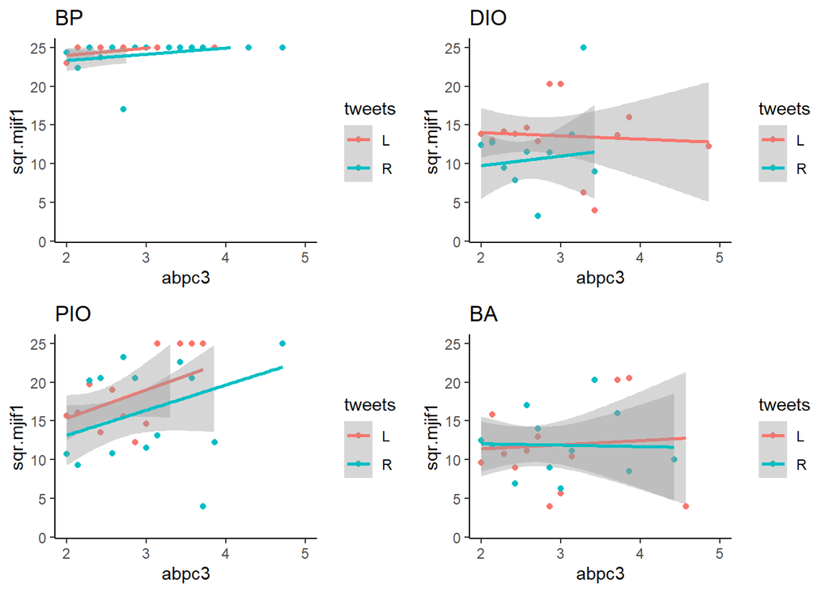

# Political Extremes

Repeating the above analyses using only the political extremes (polornt median +/- 1 standard deviation)

- Full cases =327
- BA cases =73
- PIO cases =92
- DIO cases =73
- BP cases =89

### Full model

```
##
## Call:
## lm(formula = sqr.mji ~ PI * DI * abpc * tweets, data = dat.x)
##
## Residuals:
##      Min       1Q   Median       3Q      Max
## -16.9191  -3.2452   0.9893   3.2293  12.5282
##
## Coefficients:
##                      Estimate Std. Error t value Pr(>|t|)
## (Intercept)           9.01965    2.97042   3.036   0.0026 **
## PI1                   3.50854    3.89153   0.902   0.3680
## DI1                  -0.59391    3.80679  -0.156   0.8761
## abpc                  2.64184    1.16419   2.269   0.0239 *
## tweetsR               7.49057    3.93489   1.904   0.0579 .
## PI1:DI1               9.63459    5.11798   1.882   0.0607 .
## PI1:abpc             -0.57871    1.53964  -0.376   0.7073
## DI1:abpc              0.19901    1.51524   0.131   0.8956
## PI1:tweetsR           0.98176    5.22309   0.188   0.8510
## DI1:tweetsR           0.04669    5.29119   0.009   0.9930
## abpc:tweetsR         -3.49251    1.51810  -2.301   0.0221 *
## PI1:DI1:abpc         -1.47983    2.08380  -0.710   0.4781
## PI1:DI1:tweetsR      -5.52240    7.21573  -0.765   0.4447
## PI1:abpc:tweetsR      0.47007    2.05406   0.229   0.8191
## DI1:abpc:tweetsR     -0.11275    2.10905  -0.053   0.9574
## PI1:DI1:abpc:tweetsR  1.89448    2.90364   0.652   0.5146
## ---
## Signif. codes:  0 '***' 0.001 '**' 0.01 '*' 0.05 '.' 0.1 ' ' 1
##
## Residual standard error: 5.181 on 311 degrees of freedom
## Multiple R-squared:  0.3591, Adjusted R-squared:  0.3282
## F-statistic: 11.62 on 15 and 311 DF,  p-value: < 2.2e-16
```

### BA

```
##
## Call:
## lm(formula = sqr.mji ~ tweets * abpc, data = subset(dat.x, Cond_int ==
##     "BA"))
##
## Residuals:
##      Min       1Q   Median       3Q      Max
## -11.0154  -3.9009   0.6049   3.7852  11.4172
##
## Coefficients:
##              Estimate Std. Error t value Pr(>|t|)
## (Intercept)     9.020      2.923   3.086  0.00292 **
## tweetsR         7.728      3.873   1.995  0.04997 *
## abpc            2.642      1.146   2.306  0.02410 *
## tweetsR:abpc   -3.704      1.497  -2.475  0.01579 *
## ---
## Signif. codes:  0 '***' 0.001 '**' 0.01 '*' 0.05 '.' 0.1 ' ' 1
##
## Residual standard error: 5.097 on 69 degrees of freedom
## Multiple R-squared:  0.102,  Adjusted R-squared:  0.06298
## F-statistic: 2.613 on 3 and 69 DF,  p-value: 0.05813
```

### PIO

```
##
## Call:
## lm(formula = sqr.mji ~ tweets * abpc, data = subset(dat.x, Cond_int ==
##     "PIO"))
##
## Residuals:
##      Min       1Q   Median       3Q      Max
## -16.9191  -5.0529   0.9082   5.3543   9.8460
##
## Coefficients:
##              Estimate Std. Error t value Pr(>|t|)
## (Intercept)    12.528      3.004   4.170  7.1e-05 ***
## tweetsR         8.472      4.104   2.064   0.0419 *
## abpc            2.063      1.204   1.714   0.0901 .
## tweetsR:abpc   -3.022      1.653  -1.828   0.0709 .
## ---
## Signif. codes:  0 '***' 0.001 '**' 0.01 '*' 0.05 '.' 0.1 ' ' 1
##
## Residual standard error: 6.19 on 88 degrees of freedom
## Multiple R-squared:  0.05103,    Adjusted R-squared:  0.01868
## F-statistic: 1.577 on 3 and 88 DF,  p-value: 0.2005
```

### DIO

```
##
## Call:
## lm(formula = sqr.mji ~ tweets * abpc, data = subset(dat.x, Cond_int ==
##     "DIO"))
##
## Residuals:
##     Min      1Q  Median      3Q     Max
## -9.3585 -5.4518  0.0811  5.1603 12.5282
##
## Coefficients:
##              Estimate Std. Error t value Pr(>|t|)
## (Intercept)     8.426      2.810   2.998  0.00377 **
## tweetsR         7.044      4.166   1.691  0.09540 .
## abpc            2.841      1.145   2.482  0.01552 *
## tweetsR:abpc   -3.217      1.715  -1.876  0.06484 .
## ---
## Signif. codes:  0 '***' 0.001 '**' 0.01 '*' 0.05 '.' 0.1 ' ' 1
##
## Residual standard error: 6.115 on 69 degrees of freedom
## Multiple R-squared:  0.08383,    Adjusted R-squared:  0.044
## F-statistic: 2.105 on 3 and 69 DF,  p-value: 0.1076
```

### BP

```
##
## Call:
## lm(formula = sqr.mji ~ tweets * abpc, data = subset(dat.x, Cond_int ==
##     "BP"))
##
## Residuals:
##     Min      1Q  Median      3Q     Max
## -9.5584 -0.9503  1.0735  1.7263  2.5540
##
## Coefficients:
##              Estimate Std. Error t value Pr(>|t|)
## (Intercept)   21.5689     1.1860  18.187   <2e-16 ***
## tweetsR        2.9966     1.7910   1.673   0.0980 .
## abpc           0.7823     0.5191   1.507   0.1355
## tweetsR:abpc  -1.2407     0.7353  -1.687   0.0952 .
## ---
## Signif. codes:  0 '***' 0.001 '**' 0.01 '*' 0.05 '.' 0.1 ' ' 1
##
## Residual standard error: 2.649 on 85 degrees of freedom
## Multiple R-squared:  0.03576,    Adjusted R-squared:  0.00173
## F-statistic: 1.051 on 3 and 85 DF,  p-value: 0.3744
```

## Polornt = Left

- BA cases =23
- PIO cases =31
- DIO cases =33
- BP cases =35

### BA

```
##
## Call:
## lm(formula = sqr.mji ~ tweets * abpc, data = subset(dat.x, Cond_int ==
##     "BA" & L.R == "L"))
##
## Residuals:
##     Min      1Q  Median      3Q     Max
## -7.8366 -3.8495  0.6009  4.5940  8.0785
##
## Coefficients:
##              Estimate Std. Error t value Pr(>|t|)
## (Intercept)    -7.509     12.730  -0.590    0.562
## tweetsR        21.830     14.412   1.515    0.146
## abpc           14.144      8.327   1.699    0.106
## tweetsR:abpc  -13.297      9.305  -1.429    0.169
##
## Residual standard error: 5.039 on 19 degrees of freedom
## Multiple R-squared:  0.1587, Adjusted R-squared:  0.02591
## F-statistic: 1.195 on 3 and 19 DF,  p-value: 0.3383
```

### PIO

```
##
## Call:
## lm(formula = sqr.mji ~ tweets * abpc, data = subset(dat.x, Cond_int ==
##     "PIO" & L.R == "L"))
##
## Residuals:
##      Min       1Q   Median       3Q      Max
## -10.6292  -5.1243   0.5102   5.0770   8.0875
##
## Coefficients:
##              Estimate Std. Error t value Pr(>|t|)
## (Intercept)    14.685      8.387   1.751   0.0913 .
## tweetsR        10.474     17.145   0.611   0.5464
## abpc            1.751      5.454   0.321   0.7507
## tweetsR:abpc   -5.400     11.479  -0.470   0.6418
## ---
## Signif. codes:  0 '***' 0.001 '**' 0.01 '*' 0.05 '.' 0.1 ' ' 1
##
## Residual standard error: 5.789 on 27 degrees of freedom
## Multiple R-squared:  0.05653,    Adjusted R-squared:  -0.0483
## F-statistic: 0.5393 on 3 and 27 DF,  p-value: 0.6595
```

### DIO

```
##
## Call:
## lm(formula = sqr.mji ~ tweets * abpc, data = subset(dat.x, Cond_int ==
##     "DIO" & L.R == "L"))
##
## Residuals:
##    Min     1Q Median     3Q    Max
## -9.902 -5.861 -2.054  5.737 12.410
##
## Coefficients:
##              Estimate Std. Error t value Pr(>|t|)
## (Intercept)     2.317     15.582   0.149    0.883
## tweetsR        14.076     19.319   0.729    0.472
## abpc            7.213     10.492   0.688    0.497
## tweetsR:abpc   -8.362     12.827  -0.652    0.520
##
## Residual standard error: 7.149 on 29 degrees of freedom
## Multiple R-squared:  0.03168,    Adjusted R-squared:  -0.0685
## F-statistic: 0.3162 on 3 and 29 DF,  p-value: 0.8135
```

### BP

```
##
## Call:
## lm(formula = sqr.mji ~ tweets * abpc, data = subset(dat.x, Cond_int ==
##     "BP" & L.R == "L"))
##
## Residuals:
##     Min      1Q  Median      3Q     Max
## -5.6548 -0.5736  0.2278  0.9921  2.7939
##
## Coefficients:
##              Estimate Std. Error t value Pr(>|t|)
## (Intercept)    28.948      2.750  10.527 9.28e-12 ***
## tweetsR        -5.780      4.250  -1.360   0.1837
## abpc           -3.836      1.772  -2.165   0.0382 *
## tweetsR:abpc    4.916      2.750   1.788   0.0836 .
## ---
## Signif. codes:  0 '***' 0.001 '**' 0.01 '*' 0.05 '.' 0.1 ' ' 1
##
## Residual standard error: 1.842 on 31 degrees of freedom
## Multiple R-squared:  0.2852, Adjusted R-squared:  0.2161
## F-statistic: 4.124 on 3 and 31 DF,  p-value: 0.01429
```

## Polornt = Right

- BA cases =50
- PIO cases =61
- DIO cases =40
- BP cases =54

### BA

```
##
## Call:
## lm(formula = sqr.mji ~ tweets * abpc, data = subset(dat.x, Cond_int ==
##     "BA" & L.R == "R"))
##
## Residuals:
##      Min       1Q   Median       3Q      Max
## -11.0141  -3.2693   0.5672   3.6432  11.0209
##
## Coefficients:
##              Estimate Std. Error t value Pr(>|t|)
## (Intercept)     3.940      6.170   0.639   0.5262
## tweetsR        10.885      7.589   1.434   0.1582
## abpc            4.269      2.126   2.008   0.0505 .
## tweetsR:abpc   -4.768      2.589  -1.842   0.0720 .
## ---
## Signif. codes:  0 '***' 0.001 '**' 0.01 '*' 0.05 '.' 0.1 ' ' 1
##
## Residual standard error: 5.143 on 46 degrees of freedom
## Multiple R-squared:  0.1447, Adjusted R-squared:  0.0889
## F-statistic: 2.594 on 3 and 46 DF,  p-value: 0.06391
```

### PIO

```
##
## Call:
## lm(formula = sqr.mji ~ tweets * abpc, data = subset(dat.x, Cond_int ==
##     "PIO" & L.R == "R"))
##
## Residuals:
##     Min      1Q  Median      3Q     Max
## -17.026  -2.645   1.509   4.567   9.976
##
## Coefficients:
##              Estimate Std. Error t value Pr(>|t|)
## (Intercept)   -0.6481     6.4342  -0.101  0.92012
## tweetsR       20.4477     8.2153   2.489  0.01575 *
## abpc           6.3072     2.2013   2.865  0.00583 **
## tweetsR:abpc  -6.8593     2.8604  -2.398  0.01978 *
## ---
## Signif. codes:  0 '***' 0.001 '**' 0.01 '*' 0.05 '.' 0.1 ' ' 1
##
## Residual standard error: 6.279 on 57 degrees of freedom
## Multiple R-squared:  0.1308, Adjusted R-squared:  0.08501
## F-statistic: 2.858 on 3 and 57 DF,  p-value: 0.04486
```

### DIO

```
##
## Call:
## lm(formula = sqr.mji ~ tweets * abpc, data = subset(dat.x, Cond_int ==
##     "DIO" & L.R == "R"))
##
## Residuals:
##      Min       1Q   Median       3Q      Max
## -10.0084  -3.9107   0.1539   3.4539  10.3310
##
## Coefficients:
##              Estimate Std. Error t value Pr(>|t|)
## (Intercept)     6.078      5.548   1.096   0.2805
## tweetsR        13.614      9.832   1.385   0.1747
## abpc            3.582      1.900   1.885   0.0675 .
## tweetsR:abpc   -5.239      3.225  -1.625   0.1129
## ---
## Signif. codes:  0 '***' 0.001 '**' 0.01 '*' 0.05 '.' 0.1 ' ' 1
##
## Residual standard error: 5.455 on 36 degrees of freedom
## Multiple R-squared:  0.1192, Adjusted R-squared:  0.04577
## F-statistic: 1.624 on 3 and 36 DF,  p-value: 0.201
```

### BP

```
##
## Call:
## lm(formula = sqr.mji ~ tweets * abpc, data = subset(dat.x, Cond_int ==
##     "BP" & L.R == "R"))
##
## Residuals:
##     Min      1Q  Median      3Q     Max
## -7.8006 -0.7011  0.7053  2.1084  3.4035
##
## Coefficients:
##              Estimate Std. Error t value Pr(>|t|)
## (Intercept)   17.2142     2.7349   6.294 7.62e-08 ***
## tweetsR        2.0587     3.8897   0.529   0.5990
## abpc           2.2685     0.9725   2.333   0.0237 *
## tweetsR:abpc  -1.0115     1.3613  -0.743   0.4609
## ---
## Signif. codes:  0 '***' 0.001 '**' 0.01 '*' 0.05 '.' 0.1 ' ' 1
##
## Residual standard error: 2.833 on 50 degrees of freedom
## Multiple R-squared:  0.134,  Adjusted R-squared:  0.08209
## F-statistic:  2.58 on 3 and 50 DF,  p-value: 0.06386
```

## Polornt = Left w/ mji factor 1

- BA cases =23
- PIO cases =31
- DIO cases =33
- BP cases =35

### BA

```
##
## Call:
## lm(formula = sqr.mjif1 ~ tweets + polornt + tweets * polornt,
##     data = subset(dat.x, Cond_int == "BA" & L.R == "L"))
##
## Residuals:
##      Min       1Q   Median       3Q      Max
## -10.1088  -4.1374   0.4984   3.9933  14.0519
##
## Coefficients:
##                 Estimate Std. Error t value Pr(>|t|)
## (Intercept)      12.5550     4.4173   2.842   0.0104 *
## tweetsR          -2.6943     5.8354  -0.462   0.6495
## polornt          -0.1607     0.4095  -0.392   0.6991
## tweetsR:polornt   0.3847     0.5538   0.695   0.4956
## ---
## Signif. codes:  0 '***' 0.001 '**' 0.01 '*' 0.05 '.' 0.1 ' ' 1
##
## Residual standard error: 6.069 on 19 degrees of freedom
## Multiple R-squared:  0.03291,    Adjusted R-squared:  -0.1198
## F-statistic: 0.2155 on 3 and 19 DF,  p-value: 0.8844
```

### PIO

```
##
## Call:
## lm(formula = sqr.mjif1 ~ tweets + polornt + tweets * polornt,
##     data = subset(dat.x, Cond_int == "PIO" & L.R == "L"))
##
## Residuals:
##      Min       1Q   Median       3Q      Max
## -13.5814  -4.4545   0.5355   4.9157  11.9497
##
## Coefficients:
##                 Estimate Std. Error t value Pr(>|t|)
## (Intercept)      22.8736     3.3689   6.790 2.72e-07 ***
## tweetsR         -13.5255     5.7376  -2.357  0.02591 *
## polornt          -1.0584     0.3876  -2.731  0.01100 *
## tweetsR:polornt   1.7989     0.5748   3.130  0.00417 **
## ---
## Signif. codes:  0 '***' 0.001 '**' 0.01 '*' 0.05 '.' 0.1 ' ' 1
##
## Residual standard error: 6.506 on 27 degrees of freedom
## Multiple R-squared:  0.2943, Adjusted R-squared:  0.2159
## F-statistic: 3.753 on 3 and 27 DF,  p-value: 0.02253
```

### DIO

```
##
## Call:
## lm(formula = sqr.mjif1 ~ tweets + polornt + tweets * polornt,
##     data = subset(dat.x, Cond_int == "DIO" & L.R == "L"))
##
## Residuals:
##     Min      1Q  Median      3Q     Max
## -11.092  -6.650   1.509   4.387  15.306
##
## Coefficients:
##                 Estimate Std. Error t value Pr(>|t|)
## (Intercept)      16.4093     5.2564   3.122  0.00405 **
## tweetsR         -10.5053     6.8692  -1.529  0.13702
## polornt          -0.4796     0.4813  -0.997  0.32719
## tweetsR:polornt   1.0626     0.6803   1.562  0.12917
## ---
## Signif. codes:  0 '***' 0.001 '**' 0.01 '*' 0.05 '.' 0.1 ' ' 1
##
## Residual standard error: 7.565 on 29 degrees of freedom
## Multiple R-squared:  0.08065,    Adjusted R-squared:  -0.01446
## F-statistic: 0.848 on 3 and 29 DF,  p-value: 0.479
```

### BP

```
##
## Call:
## lm(formula = sqr.mjif1 ~ tweets + polornt + tweets * polornt,
##     data = subset(dat.x, Cond_int == "BP" & L.R == "L"))
##
## Residuals:
##     Min      1Q  Median      3Q     Max
## -8.1721  0.0000  0.2813  0.6457  1.2835
##
## Coefficients:
##                 Estimate Std. Error t value Pr(>|t|)
## (Intercept)     23.44320    1.22082  19.203   <2e-16 ***
## tweetsR          1.55680    1.55305   1.002    0.324
## polornt          0.09111    0.11378   0.801    0.429
## tweetsR:polornt -0.09111    0.15616  -0.583    0.564
## ---
## Signif. codes:  0 '***' 0.001 '**' 0.01 '*' 0.05 '.' 0.1 ' ' 1
##
## Residual standard error: 1.732 on 31 degrees of freedom
## Multiple R-squared:  0.05213,    Adjusted R-squared:  -0.0396
## F-statistic: 0.5682 on 3 and 31 DF,  p-value: 0.6401
```

## Polornt = Right w/ mji factor 1

- BA cases =50
- PIO cases =61
- DIO cases =40
- BP cases =54

### BA

```
##
## Call:
## lm(formula = sqr.mjif1 ~ tweets + polornt + tweets * polornt,
##     data = subset(dat.x, Cond_int == "BA" & L.R == "R"))
##
## Residuals:
##      Min       1Q   Median       3Q      Max
## -11.9040  -5.0339   0.5607   4.4600  13.8436
##
## Coefficients:
##                 Estimate Std. Error t value Pr(>|t|)
## (Intercept)     10.61854   10.90834   0.973    0.335
## tweetsR         -0.22663   14.90442  -0.015    0.988
## polornt          0.02512    0.14607   0.172    0.864
## tweetsR:polornt -0.01404    0.19654  -0.071    0.943
##
## Residual standard error: 6.744 on 46 degrees of freedom
## Multiple R-squared:  0.009853,   Adjusted R-squared:  -0.05472
## F-statistic: 0.1526 on 3 and 46 DF,  p-value: 0.9275
```

### PIO

```
##
## Call:
## lm(formula = sqr.mjif1 ~ tweets + polornt + tweets * polornt,
##     data = subset(dat.x, Cond_int == "PIO" & L.R == "R"))
##
## Residuals:
##      Min       1Q   Median       3Q      Max
## -16.3035  -5.4774   0.3203   7.9791  10.2400
##
## Coefficients:
##                 Estimate Std. Error t value Pr(>|t|)
## (Intercept)       6.4230    12.8219   0.501    0.618
## tweetsR          15.5193    17.0665   0.909    0.367
## polornt           0.1413     0.1816   0.778    0.440
## tweetsR:polornt  -0.2101     0.2365  -0.889    0.378
##
## Residual standard error: 8.115 on 57 degrees of freedom
## Multiple R-squared:  0.01516,    Adjusted R-squared:  -0.03667
## F-statistic: 0.2925 on 3 and 57 DF,  p-value: 0.8306
```